# Why We Swim.Tsui2020

虽然武士泳是日本游泳文化的根基，但其传统正在逐渐衰落。然而，那些肩负保护这项传统重任的人们却认为，这与现代日本游泳队在国际赛场上取得成功有着直接的联系。五月初一个异常温暖的星期里，我四处旅行。去东京看看如今的武士游泳是什么样子，以及人们至今仍在进行这项活动意味着什么。

Though samurai swimming is at the roots of Japan’s swimming culture, its traditions are waning. But those tasked with its preservation see a direct line to modern Japanese swimming success in international competition. During an unseasonably balmy week in early May, I travel around Tokyo to see what samurai swimming looks like today and what it means that people are still doing it.

为了找到石引绿，我来到了横滨的一家室内游泳俱乐部，在泳池边汗流浃背。室内泳池边简直像个超高温的桑拿房。穿着便服站在这么漂亮的泳池边，让我感到很不自在，但这却是我认真记录绿游泳课内容的唯一办法。今天，除了普通学员外，还有五位*范士——**日本泳法*中最高级别的教练——也来上课。其中一位教练，七十三岁的今村正明，日本游泳协会日本泳*法*委员会副会长，正好奇地打量着我。他也觉得我穿着便服很奇怪。

My pursuit of Midori Ishibiki leads me to an indoor swimming club in Yokohama, where I am sweating profusely on the pool deck. The indoor pool deck is like a sauna turned up to the max. It causes me distress to be dressed in street clothes by the edge of a perfectly nice pool, but it’s the only way I can take proper notes on the happenings in Midori’s swim class. Today there are five *hanshi* masters—the highest level master there is in *Nihon eiho*—attending the class along with the regular students. One of the masters, Masaaki Imamura, the seventy-three-year-old vice chair of the Japan Swimming Federation’s committee on *Nihon eiho*, is examining me curiously. He also thinks it’s weird that I’m wearing street clothes.

“你为什么不去游泳呢？”他用低沉浑厚的声音打招呼，脸上带着迷人的笑容。“天气太热了。”他穿着黑色Speedo泳裤，戴着一顶黑色布泳帽，帽檐上有白色滚边，帽带系在下巴下面。黑色泳帽代表着他在神传流的资历*；*白色泳帽是给初学者的，就像柔道或空手道等其他武术中的白带一样。不过，不同流派的泳帽颜色等级划分略有不同*。*我勉强挤出一个笑容，随即又皱起了眉头，真想冲回更衣室，脱掉厚重的棉质连衣裙和紧身裤，也跳进水里。但我不能错过接下来发生的一切。

“Why don’t you swim?” he greets me with a deep, booming voice, as he issues forth a charming grin. “It is very hot.” He is wearing a black Speedo and a black cloth swim cap with white piping and strings that tie under his chin. The black cap indicates seniority in the Shinden *ryu*; white caps are given to beginners, much like the white belt in other martial arts like judo or karate. The progression of colors, however, varies by *ryu*. I manage to smile back, then grimace, and I’m tempted to dash back into the locker room to shed my heavy cotton dress and leggings so I can get in that water, too. But I can’t chance missing what happens next.

绿谷班上的十五名男女学生围成一圈，鞠躬致意。然后，他们一个接一个地走向水边，轻盈无声地滑入水中，如同鸭子跃出湖面一般。游了几圈后，今村跳上岸，自告奋勇地担任我的临时体育解说员。“我们为什么要游泳？”今村带着他那迷人的笑容，低声问道。“嗯，这很简单。”他像个教授一样，双手交叉，然后用他那修长的棕色手指一一列举了以下几点：

The fifteen men and women in Midori’s class circle and bow. Then, one by one, they stride to the water and slip in, smoothly and soundlessly, like ducks to the surface of a lake. After a few laps, Imamura hops out and volunteers to be my de facto sports announcer. “Why do we swim?” rumbles Imamura, with another winning smile. “Well, that’s very simple, you see.” Like a professor, he steeples his hands, and then proceeds to tick off the following on his slender brown fingers:

**为了生存：** “日本当然是四面环水。”

**For survival:** “Japan, of course, is surrounded by water.”

**宗教方面：** “在神道教的习俗中，*禊*（用水进行身心清洁的仪式）是神圣的。”

**For religion:** “In Shinto practices, *misogi*—the ritualistic cleaning of body and mind with water—is sacred.”

**为了战斗：** “武士为了保卫封建领土，发展了具有地域特色的游泳学校。”

**For fighting:** “The samurai, to protect feudal territory, developed regionally specific swimming schools.”

**比赛项目**包括：“例如跳水、竞速或花样游泳等。”

**For competition:** “Disciplines include diving and racing, say, or synchronized swimming.”

**为了增强身心力量： “***日本英法*的最高原则是心与水合一。”

**For strength of mind and body:** “The topmost principle in *Nihon eiho* is mind and water, together.”

他说，这最后一个原则可以解释为“水之*心*”。他一边说着，一边用手指蘸着水在旁边的长椅上描摹着日文汉字。“这是最重要的。原因有很多，但等你年纪大了，就能体会到禅宗的精髓，大师的智慧，以及其中的哲学。”

This last principle, he says, can be explained as *mizu no kokoro*, or “mind like water.” On the bench next to us, he traces a finger on its surface with water as he speaks, writing out the Japanese characters. “This is the most important thing. There are many reasons, but when you get older, you can appreciate the Zen part, the master part, the philosophy.”

We pause to observe Midori as she swims by. She wears a black cap with two white stripes that signify that she is the director of her group. As the rest of the class watches from the side of the pool, she demonstrates the *nukite* style, that withdrawing arm stroke I saw on Japanese television, the one intended to cut through incoming waves as one heads out to sea. Because she does this all with seeming effortlessness, and with a smile, her at-homeness in the water makes me think of a friendly porpoise at play.

“绿小姐，她游得非常好，”今村赞许地说。他称赞她流畅优雅的划水动作，并强调了她推进力的强大。“你认识北岛吗？”他问道，指的是日本蛙泳选手北岛康介——或许是史上最伟大的蛙泳选手。北岛在2004年雅典奥运会和2008年北京奥运会上分别获得男子100米和200米蛙泳双料金牌后，于2016年退役。“北岛的蛙泳就像*日本泳法*——因为他划水一次就势大力沉，然后滑行很长很长一段距离。”他解释说，这一次划水的力量至关重要——它展现了对节奏和耐心的精湛掌控。

“Midori-san, she is very good,” Imamura says, approvingly. He comments on her smooth, elegant stroke and emphasizes the power of her propulsion. “You know Kitajima?” he asks, referring to the Japanese breaststroker Kosuke Kitajima—perhaps the greatest breaststroker of all time. Kitajima retired in 2016 after winning double gold in the men’s 100- and 200-meter breaststroke in the 2004 Athens and the 2008 Beijing Olympics. “Kitajima swims breaststroke like *Nihon eiho*—because he has one powerful stroke and then floats: a long, long glide.” The power of that one stroke, he explains, is critical—it shows a mastery of pacing and patience.

“运用这些技巧，你可以跑得很快，但这并非重点，”今村说道。“如今，在日本，*日本英法*是为那些明白它并非像年轻人那样追求速度或胜利的老年人准备的。我们反复练习，非常非常努力地工作，以达到禅定的境界。它关乎精神的力量。”

“You can go very fast using these techniques, but that is not what it is about,” Imamura says. “Now, in modern Japan, *Nihon eiho* is for older people who know it is not about racing, or winning, the way it is for young people. We practice, practice, practice, and work very, very hard to get to that place of Zen. It is about strength of mind.”

Like Midori, Imamura has been a senior figure in *Nihon eiho* circles for decades. He learned *Nihon eiho* as a child in school, first and foremost out of tradition. He continued the martial arts practice because he liked the meditative quality that came along with the physical movements. “It’s like tai chi, but in water,” he says. “That’s a good comparison. In the concentration, you find a peace.”

课堂上，学员们分成三人一组，每组以三角形队形横渡泳池：抬头挺胸，双臂交替划水，双腿蛙泳。每个人都时刻关注着组内其他成员，并做出细微的调整，以确保全组动作同步。伊玛穆拉解释说，不同的游泳者由于身体条件不同，各有长短。这种三人队形练习旨在培养学员的感知能力——既要感知自身和他人的身体，也要感知不断变化的环境——以及控制力。“你不能与水对抗；你必须*与*水合作，”伊玛穆拉说道。正如其他一些历史悠久的沿海文化，例如荷兰文化所强调的那样，这里再次体现了水是盟友而非敌人的理念。懂得如何在水中生存，才能将水视为朋友。

The class splits into groups of three, and each group sets off swimming across the pool in a triangle formation: head up, arms alternating in a front crawl stroke, legs frog kicking. Each person is fully aware of the others in the group, making minute adjustments so that the whole group moves in synchrony. Different swimmers have different strengths and weaknesses according to their bodies, Imamura explains. The three-swimmer formation is an exercise in awareness—of your own body and others’, and of the ever-changing environment, too—and control. “You can’t work against water; you have to work *with* water,” Imamura says. As other longtime coastal cultures, like the Dutch, emphasize, here, again, is the idea of water as ally, not enemy. Knowing how to survive water is what allows us to see it as a friend.

下课后，几位老师热情地邀请我去街对面泳池边的小酒吧喝啤酒。我和绿、今村以及另一位老师小妻咲（一位三十多岁、脸上带着酒窝的年轻女子，她容光焕发，在班上显得格外引人注目）围坐在一张木桌旁。这时，一位身材精干、戴着眼镜、头发梳理得一丝不苟的男士出现在桌角：正是*日本英法全国委员会主席日野昭典。（我之前看过一篇关于**日本英法的*日本新闻报道，认出了他。）那天是星期天。下午，因为绿子告诉他我要来，他特意穿上西装打上领带来见我。

After class, the masters delight me with an invitation to join them for beers in a small pub across the street from the pool. Midori, Imamura, and I crowd around a wooden table along with another master, Saki Kozuma, a dimpled young woman in her thirties who stood out from the rest of the class by virtue of her radiant youth. Then a trim, bespectacled man with neatly combed gray hair materializes at the corner of the table: Akinori Hino, the head of the national committee on *Nihon eiho* himself. (I recognize him from the Japanese news report I watched about *Nihon eiho*.) On this Sunday afternoon, because Midori informed him of my visit, he has taken the trouble to put on a jacket and tie to meet me.

在这群杰出的游泳大师齐聚一堂之际，我想请教大家，*日本泳技*如今的魅力何在？人们为何选择学习这种游泳武术，而不是其他游泳课程？他们究竟在追求什么？

With this eminent group of swimming masters gathered, I ask what allure *Nihon eiho* holds today. Why do people take classes in the swimming martial art instead of other swimming lessons? What are they looking for?

“太好玩了！”今村惊呼道。绿子笑了。

“It’s very fun!” Imamura exclaims. Midori laughs.

“*日本英法*就是让自己变得更好，”她停顿片刻后补充道。“也许是健康，也许是生活方式，也许是精神层面的东西。每个人都有自己的水平，你可以选择自己练习的目标。你最好的目标是什么？它可以是时间，也可以是速度，但不仅仅是这些。它也可以是我想让我的划水动作更优美。”

“*Nihon eiho* is to make yourself better,” she adds, after a moment. “Maybe it’s health, or lifestyle. Or something for your mind. Every single person is at their own level, and it lets you choose your own purpose in the practice. What is your best purpose? It can be time, or speed, but it’s not just that. It can also be that I want to be more beautiful in my stroke.”

日野意味深长地点点头。“我感兴趣的正是其中的耐心、放松和慢节奏，”他说。这时，酒吧老板娘端来一托盘啤酒，他顿了顿。大家碰杯，互道“干杯*”*，然后我们继续交谈。

Hino nods sagely. “The patience, relaxation, and slowness of it is what I find interesting,” he says. He pauses as the proprietress of the pub brings a tray of beers. A round of cheers and *kampai*, then we continue our conversation.

小妻老师从幼儿园就开始在学校学习游泳。在日本，学龄儿童必须接受游泳训练。她在大学期间开始学习*日本泳法*。“我喜欢思考如何踩水、如何抓水，以及如何锻炼身心，而不仅仅是身体。” 她在东京一所大学的游泳俱乐部教授高中生和大学生*日本泳法。*

Kozuma, the young master, learned to swim in school when she was in kindergarten. School-age swim instruction is mandatory in Japan. She started *Nihon eiho* at her university. “I liked thinking about how to tread water, how to catch water, how to exercise for your mind, too, not just for body.” She teaches *Nihon eiho* to high school and college kids at a university swim club in Tokyo.

“The water is the last place where people cannot text, call, or find me,” she says with a giggle—in her efforts to develop the next generation, she finds that *Nihon eiho* has unexpected benefits.

托尼·坎迪是个身材魁梧的人——身高六英尺五英寸，体重超过两百磅。但当他在水中练习*日本泳法*时，他几乎只露出下巴。在那里，他能以不同的视角看待世界。最近，在一次伦敦之旅中，他在海德公园游泳，那里有天鹅出没。“当你身处水中时，因为你不会溅起水花，蜻蜓会从你身边飞过，船夫会从你身边滑过，”他告诉我。“你对世界的理解是在水面之上，而不是在水下。”他停顿了一下，思考着。“不过，我曾经被一只天鹅攻击过。”

Tony Cundy is a big guy—six feet five and over two hundred pounds. But when he’s in the water practicing *Nihon eiho*, he’s mostly hidden away to chin level. He gets a different view of the world there. Recently, on a trip to London, he swam in Hyde Park, swans and all. “When you’re in the water, because you’re not breaking the water or splashing, dragonflies will flit past you, boatmen will glide by,” he tells me. “Your understanding of the world is at the waterline, not underneath.” He pauses, considering. “Though a swan did attack me once.”

坎迪是唯一一位获得*日本英法认证的非日本籍*教练。他现居东京，担任广告公司高管，但成长于英国著名的海军小镇普利茅斯，从小就热爱游泳。年轻时，他以自己精湛的游泳技艺和速度著称，并以此为傲，其水平堪比奥运选手。1995年，22岁的他移居东京，开始学习合气道。五年后，他开始接触*日本英法*。“我之前对游泳的认知，”他说道，“全都颠覆了。”

Cundy is the only non-Japanese person ever to be certified to teach *Nihon eiho*. He lives in Tokyo and works as a top advertising executive, but he grew up swimming in Plymouth, a prominent English naval town. As a young man, he was proud of being an accomplished and speedy swimmer in the Olympian tradition. He moved to Tokyo in 1995 when he was twenty-two to study aikido. Five years later, he began to learn about *Nihon eiho*. “And everything I thought I knew about swimming,” he says, “went out the window.”

他记得第一次和游泳教练一起在泳池里，教练滔滔不绝地讲述着游泳武术的传统。他的老师站在他面前，双臂交叉抱在胸前，一边点头一边看着他。但他并没有站在泳池底部——他站着。他正在游泳，用的是日式的踩水方式*——立泳*。他的上半身纹丝不动，坎迪忍不住一直盯着他看。

He remembers being in the pool with his swimming teacher for the first time, talking to him at length about the swimming martial arts tradition. His sensei was standing in front of him, arms folded, nodding his head. But he wasn’t standing on the bottom of the pool—he was standing swimming, *tachi-oyogi,* the Japanese style of treading water. His upper body was so still that Cundy couldn’t stop staring.

一位老师潜入五米泳池底部，走过池面，然后平静地浮回水面。一位学员举着五公斤重的哑铃，在水中踩水超过一个小时。他的老师在水中射箭，精准地击中各种目标的中心。突然间，他明白了，游泳的关键不在于速度或距离，而在于掌握足够的技巧，以便应对未来生活中可能遇到的任何水上情况。他学会了用臀部和腿部发力，以全新的方式控制动作和动量，大大减少了手臂的使用。这对他来说是一次醍醐灌顶的顿悟。

A teacher dropping to the bottom of a five-meter pool, walking across it, and then floating serenely back up. A practitioner treading water with arms aloft, holding a five-kilogram dumbbell, for more than an hour. His sensei firing arrows across the water to hit the centers of various targets. Suddenly, he saw, swimming was not about speed or distance but about becoming skilled enough to handle whatever water scenarios he might encounter out in the world. He learned to develop movement and momentum in new ways, through the hips and legs, with much less use of the arms. It was a revelation.

“我以前游泳总是*低着头，拼命划水，下潜，上浮，下潜，上浮，想着能游多少圈？*我从来没注意过其他事情，”坎迪说。“现在我总是抬头挺胸，用鼻子呼吸。我能看到每一道波浪，对周围的环境也非常敏感。”速度只是*日本泳法*的一个组成部分，并非其根本目标。坎迪认为，在大多数情况下，游泳是一种更敏锐地体验周围环境的方式。

“My swimming was always, *Head down, thrash away, down, up, down, up, how many laps can I do?* I never noticed anything else,” Cundy says. “Now my head is always up, and I breathe through my nose. I can see every wave, and I’m very aware of my surroundings.” Speed is just one component of *Nihon eiho*, not the fundamental objective. For the most part, Cundy sees it as a way to experience his environment more keenly.

坎迪曾参加过各种*日本英法*比赛，包括在日本举行的年度全国比赛。该比赛只有两项是竞速项目，其中一项采用的泳姿正是1898年横滨游泳队击败外国选手时所用的泳姿。考试和比赛项目涵盖了计时赛、举重、挥旗表演和全副武装游泳等。

Cundy has competed in different *Nihon eiho* events, including the annual national competition in Japan. Only two events in that competition are races, one of which employs the stroke that those Yokohama swimmers used to beat the foreigners way back in 1898. The examinations and competitions range from those time trials and weight holding to demonstrations of flag waving and armored swimming.

I ask him, half-jokingly, if he feels ready for battle. “Crikey,” he exclaims, thinking for a moment. Then he points out that some of the principles are similar to the combat and treading techniques used by Navy SEALs (clearly the SEALs embody a host of ideals, like the superior mental toughness that sports psychologist Jim Bauman spoke of). But for all of *Nihon eiho*’s physical challenges and athleticism, it’s the degree of thought and refinement—“the same kind of refinement that has been applied to lacquering your bowl, for that matter”—that keeps him swimming.

武士游泳的理念在今天依然具有深刻的哲学意义。哲学家达蒙·杨在其著作《*如何思考运动*》中重拾了古老的运动理念，认为运动应该兼顾人的整体人性，而不仅仅是他所谓的“身体机器”。杨指出，在体力和脑力活动方面，那种二元对立的思维方式——比如运动员与书呆子、运动型与书呆型——是一种错误的划分。

The ideals of samurai swimming have a clear philosophical resonance today. In his book *How to Think About Exercise*, the philosopher Damon Young revives the ancient idea of exercise as something that takes into account one’s whole humanity—and not just what he calls “the bodily machine.” Young observes that the tendency to think in dualism—jocks vs. nerds, sporty vs. bookish—is a false divide when it comes to physical and mental exertions.

他认为，游泳的益处不仅在于增强体魄，更在于提升智力。理想的现代游泳运动员注重的是整体体验，而非将锻炼视为一种“调教”。同样重要的是，我们对锻炼有多么出色而感到自豪。“我们越是拥有完整的自我意识，”杨格曾对一位采访者说，“我们就越会为此承担责任。”

Swimming’s benefit, he argues, has as much to do with intellectual enhancements as it does the achievements of the body. The ideal modern swimmer focuses on the whole experience rather than the perception of exercise as a “tune-up.” Important, too, is the pride we feel in the well-exercised body. “The fuller sense of self we have,” Young once told an interviewer, “the more responsibility we take for it.”

随着时间的推移，游泳已经从单纯的机械技能和生存技能——一种由男性练习的军事技能——转变为一项能够实现目标的技能。游泳还有一种更深层次的意义：它是一种休闲方式，一种乐趣，能够提升你的精神和身体健康。这种通过游泳来促进身心健康、获得情感共鸣、实现人格完整发展的理念，我深有同感。身体和心理是密不可分的。

Over time, swimming has shifted from mere mechanics and survival—a military skill, practiced by men—to achieve a more intangible significance: a form of recreation, a pleasure, something that can sharpen your spiritual as well as physical health. This idea of swimming for wellness, emotional resonance, whole personhood, rings true to me. The physical is intertwined with the psychological.

在日本，泽井敦弘是一位畅销书作家，他撰写关于身心合一、开发*“气”*（生命能量）的理论。他还记录了自己学习*日本英法（Nihon eiho）*的经历。其中最令他印象深刻的是“束缚缠身*”（shusoku garami）*，这种技巧可以让人在双手双脚被捆绑的情况下游泳。我们当中很少有人会面临从敌营逃脱、必须游过护城河才能逃脱的境地，但这其中蕴含着一些道理。“我惊讶地看着一个双手双脚被绑的人在水池里游来游去，他的动作介于青蛙和鳗鱼之间。他可以俯泳，也可以仰泳，头朝前，脚朝后，”敦弘写道。“我的老师让我们大吃一惊，他说：‘你们以为游泳是用胳膊和腿，但你们错了。不用胳膊腿也能游泳。看看鱼儿吧。真正的游泳是用全身。’”

In Japan, Sawai Atsuhiro is a bestselling author who writes about mind and body unification principles that develop *ki*, or life energy. He has also written about his experiences of studying to be a master in *Nihon eiho*. The technique that impressed him most was *shusoku garami*, which allows someone to swim with both hands and feet bound together. There aren’t many of us who will face the possibility of breaking out of an enemy prison, having to swim across the castle moat to escape, but there’s a lesson here. “Astonished, I watch a man with hands and feet tied swim across a pool with a motion that is a cross between a swimming frog and an undulating eel. He is able to swim on his front or on his back, head first or feet first,” Atsuhiro writes. “And my teacher surprised us by saying, ‘You believe you swim with the arms and legs, but you’re wrong. You can swim without them. Look at a fish. Real swimming is using the whole body.’”

在我的脑海中，鲑鱼再次浮现，它们是适应力、韧性和耐力的优雅典范。我们并非鱼类，但我们依然能从它们身上汲取灵感。在这里，鲑鱼提醒我们，游泳可以是一项全身心投入的运动。游泳比赛的严苛磨练，造就了人们对游泳的热爱，将其视为一种身心全面提升的方式。重点从单纯关注身体转向身心合一。想象一下溪流汇入河流，河流最终流入大海。

In my mind, the salmon surfaces again, that elegant example of adaptation, tenacity, and stamina. We are not fish, but from them we continue to take inspiration. In this case, the fish reminds us that swimming can be something to engage your whole self. From the rigor of swimming competition comes a devotion to swimming as holistic self-betterment. The emphasis moves from body alone to body and mind, together. Think of a stream flowing into a river, a river flowing into the sea.

这些水域交汇在一起，让我明白了我为什么会游泳。

These waters run together in a way that helps me to understand why I swim.

# 流动

# FLOW

水是 H₂O <sub>，</sub>由两部分氢和一部分氧组成，但还有第三种物质，使水成为一种物质，但没有人知道它是什么。

Water is H<sub>2</sub>O, hydrogen two parts, oxygen one, but there is also a third thing, that makes it water and nobody knows what it is.

——D·H·劳伦斯，《第三件事》

—D. H. Lawrence, “The Third Thing”

*这句话出自《白鲸》*的开篇。“是的，正如每个人都知道的那样，”以实玛利宣称，“冥想和水永远是密不可分的。”

It’s in the opening pages of *Moby-Dick*. “Yes, as every one knows,” Ishmael declares, “meditation and water are wedded forever.”

小说开篇，伊什梅尔便将我们的注意力引向聚集在曼哈顿海岸边，凝望着大海的人群，他们沉浸在一个安息日的午后。瞧，这些人，都微微俯身，仿佛要将我们定格在梦境之中。他们的出现印证了他的观点：大海那如液体般流动的指尖，的确有一种魔力，能让我们沉浸于思绪之中。伊什梅尔指出，古波斯人称大海为圣，希腊人则赋予它一位强大的神祇。处女航仿佛蕴含着某种“神秘的韵律”。但水的魔力究竟是什么？它又对我们产生了怎样的影响？这仍然是个谜。

Here at the novel’s beginning, Ishmael calls our attention to the crowds of dreamy water gazers gathered along the shores of Manhattan on a Sabbath afternoon. See all those people, leaning over ever so far. They prove him right: the ocean’s liquid fingers have a way of transfixing us in thought. Ishmael points out that the ancient Persians call the sea holy, that the Greeks give it a powerful deity of its very own. A maiden voyage sings with a kind of “mystical vibration.” But what exactly is the magic of water, and what does it do to us? It’s a mystery.

当我们凝视湖泊、河流或海洋时，会发现水能激发一种特殊的遐想。或许，如果我们不只是观看，而是跳入水中畅游一番，水的深处更能提升我们的意识。

When we peer into a lake, river, or ocean, we find that water encourages a particular kind of reverie. Perhaps its depths can enhance our consciousness even more if, instead of just looking, we get in and swim.

我们跳入水中，发现自己置身于一个奇特的环境中过渡空间。我们身处其中，悬置却又流动；漂浮却又时刻面临沉没的危险。如果我们顺流而下，而非与之对抗，便能找到一种瞬间的状态，一种运动与悖论式静止并存的状态，那就是*流动*。

We jump into that water and find ourselves in a curious liminal space. Here we are, suspended, yet moving; floating, yet ever in danger of sinking. And if we swim with the current, instead of fighting against it, we find a momentary state, one of motion and yet paradoxical stillness that is *flow*.

匈牙利心理学家米哈里·契克森米哈赖（Mihaly Csikszentmihalyi）将“心流”解释为“人们完全沉浸于某项活动，以至于其他一切都变得无关紧要的状态”。他说，这种活动——比如游泳或演奏音乐——带来的愉悦感如此强烈，“以至于人们即使付出巨大的代价，也会为了享受其中而去做”。我想到了冰冷的海水、黎明即起的锻炼、肩伤，还有我花在比基尼上的所有钱。

Flow is what the groundbreaking Hungarian psychologist Mihaly Csikszentmihalyi explains as “the state in which people are so involved in an activity that nothing else seems to matter.” The experience of said activity—swimming, say, or playing music—is so entirely enjoyable, he says, “that people will do it even at great cost, for the sheer sake of doing it.” I think of frigid waters, crack-of-dawn workouts, shoulder injuries, all the money I’ve spent on bikinis.

近三十年前，齐克森米哈里首次使用“*心流”*一词来描述完全沉浸于某种体验之中，以至于自我意识消融，时间流逝的感知也随之消失的感受。他写道：“每一个动作、每一个念头都必然地源于前一个，就像演奏爵士乐一样。”这种毫不费力、全身心投入的专注令人愉悦。对我而言，真正走进水中去追寻这种狂喜的状态有着双重吸引力：它让我同时体验到两种沉浸感。

Nearly three decades ago, Csikszentmihalyi was the first to use the word *flow* to describe the experience of being so totally immersed that the self seems to fall away, along with any awareness of the passage of time. “Every action, movement, and thought follows inevitably from the previous one, like playing jazz,” he writes. This kind of effortless, deeply engaged concentration is joyful. For me, actually getting into water to chase that ecstatic state of mind has a double appeal: it’s two kinds of immersion experienced at once.

In 1810, a century and a half before Csikszentmihalyi defined flow as such, the poet Lord Byron swam the Hellespont, the treacherous four-mile strait that is today known as the Dardanelles, in northern Turkey. He crossed from the Aegean to the Sea of Marmara, swimming with the tide from Europe to Asia. In the process, he kicked off a centuries-long fascination with the waters there. To this day, swimmers are enamored with the traverse of these symbolic seas. But what I’m most interested in is the idea that this swim is the thing that unclogged Byron’s creative faucet.

拜伦痴迷于游泳。他患有腿部畸形，严重影响了他的步态；只有在水中，他才能感受到真正的自由和自我。“我热爱大海，”他写道，“每次出水，我都感到一种前所未有的精神振奋。”他甚至幻想自己前世是人鱼。他尽可能地游泳：泰晤士河上的桥到桥，里斯本的塔霍河河口，以及威尼斯大运河。在他横渡赫勒斯滂海峡时，他已经发表了一些诗作，但尚未成为伟大的浪漫主义诗人之一。

Byron was obsessed with swimming. He suffered from a leg deformity, which severely contracted his gait; he never felt so free and himself as when he was in the water. “I delight in the sea,” he wrote, “and come out with a buoyancy of spirits I never feel on any other occasion.” He entertained the thought of having been a merman in a previous life. He swam wherever he could: bridge to bridge on the Thames River, in a Tagus River estuary in Lisbon, down the length of Venice’s Grand Canal. At the time of his Hellespont swim, he had published some poetry but had not yet established himself as one of the great Romantic poets.

然而，他成功横渡赫勒斯滂海峡的经历激发了他的灵感，于是他创作了讽刺诗《从塞斯托斯游到阿拜多斯之后所作》，以此向这次游泳以及希腊神话中希罗和利安德的故事致敬。利安德是一位来自阿拜多斯的年轻人，他爱上了希罗，一位住在塞斯托斯塔楼里的阿芙洛狄忒女祭司。每天晚上，利安德都会游过四英里的赫勒斯滂海峡去拜访希罗，希罗的灯指引着他。一天晚上，灯熄灭了，他被波涛和水流吞没，溺水身亡。希罗从塔楼上纵身跃下，与他一同赴死。

His successful Hellespont crossing, though, got his muse talking, and he produced “Written after Swimming from Sestos to Abydos,” a satiric poem in homage to the swim and to the Greek myth of Hero and Leander. Leander, a young man from Abydos, falls in love with Hero, a priestess of Aphrodite who lives in a tower in Sestos. Every night, Leander swims the four miles of the Hellespont to visit Hero, guided by her lamp. One night the lamp blows out, and he drowns, overcome by the waves and currents. She throws herself from her tower to join him in death.

拜伦轻描淡写地描述了那次艰苦的游泳给恋人和他自己带来的分歧：

Of the strenuous swim, Byron wrote airily of the divergence in consequence for the lovers and himself:

很难说谁表现最好：

’Twere hard to say who fared the best:

可悲的凡人啊！因此，诸神依然在诅咒你们！

Sad mortals! thus the Gods still plague you!

他失去了劳动成果，我失去了玩笑：

He lost his labour, I my jest:

因为他溺水了，而我得了疟疾。

For he was drown’d, and I’ve the ague.

是的，拜伦虽然经历了一阵发烧和寒战，但尽管他语气轻松，他仍然觉得游泳让他摆脱了忧郁，激发了他的创作灵感，让他得以展现自己最好的一面。事实上，赫勒斯滂海峡成了他人生的一个转折点。1819年，他创作了诗歌杰作《唐璜》的前两章；在诗中，他更加自豪地提及了这次横渡。他还写了许多充满想象力的信件给朋友，信中他以英雄和利安德的神话为蓝本，讲述了自己游泳的经历。最终，拜伦加入了希腊反抗奥斯曼帝国的独立战争，并因此成为希腊民族英雄。

Yes, Byron escaped with a bout of fever and chills, but for all his jaunty tone, he felt that swimming coaxed him out of melancholy, opened up his creative stores, and gave him access to his best self. In truth, the Hellespont became a touchstone for him. In 1819, he would write the first two cantos of “Don Juan,” his poetic masterpiece; in it, he makes more proud references to that crossing. He also wrote many imaginative letters to friends riffing on the Hero and Leander myth as it related to his swim. Eventually, Byron joined Greece’s war of independence against the Ottoman Empire, for which he would become a Greek national hero.

随着时间的推移，“拜伦式”逐渐成为我们最富激情的探索者、游泳健将和艺术家的代名词。拜伦代表了文化史学家雅克·巴尔赞所描述的“专注的头脑”，以及“高昂的精神、机智的谈吐、清醒的常识和对真理的热情——简而言之，是智慧活力的独特释放”。横渡赫勒斯滂海峡激发了拜伦的想象力；也正是在那之后，他的文字和他的世界才迸发出如此鲜活的力量，足以触动我们所有人。

In time, “Byronic” would be a label for our most passionate seekers, swimmers, and artists. Byron came to represent what the cultural historian Jacques Barzun once described as a “concentrated mind,” as well as “high spirits, wit, daylight good sense, and a passion for truth—in short a unique discharge of intellectual vitality.” Swimming the Hellespont was the thing that loosed Byron’s imagination; only after did his words, and his world, generate a vivid electricity potent enough to reach the rest of us.

## 15

## 15

## 宗教练习

## A Religious Exercise

**游泳带来**的专注和即时性，让我想起了我的孩子们：一种活在当下的状态。每一个过去的瞬间都被新的瞬间所取代：一个接一个的“现在”，让我没有太多时间*去**沉湎于*过去，也没有太多时间去担忧*未来*。活在当下，对我忙碌的大脑来说是一种挑战——但我渴望它。游泳是我对抗存在主义焦虑的良药。

**T**he focused immediacy of swimming encourages a mindset that reminds me of how my young children think: it’s an ever-present-ness. Every past moment is immediately replaced by a new one: a constant stream of *now*, and *now*, and *now* that doesn’t allow much room to dwell too long on things past, or what’s to come. Living in the now is a state of being that my busy brain finds challenging—but I desire it. Swimming is an antidote for the existential anxiety from which I suffer.

在罗杰·迪金（Roger Deakin）的著名游历英国水道的著作《*水之记录》（Waterlog）中，这位博物学家将游泳描述为一种具有变革性、**如同爱丽丝梦游仙境般*的体验；这项活动影响着他对自我和时间的感知。“当你进入水中，就会发生某种类似蜕变的事情，”他写道。“离开陆地，你穿过镜面般的水面，进入一个全新的世界……游泳时，你看到和体验到的事物都与以往截然不同。”与其他任何事物都不同。”他补充道，“你对当下的感受是无比强烈的。”

In *Waterlog*, his celebrated chronicle of swimming through Britain’s waterways, the naturalist Roger Deakin described swimming as having a transformative, *Alice-in-Wonderland* quality; it was an activity that had power over his perception of self and of time. “When you enter the water, something like metamorphosis happens,” he wrote. “Leaving behind the land, you go through the looking-glass surface and enter a new world . . . You see and experience things when you’re swimming in a way that is completely different from any other.” Your sense of the present, he added, “is overwhelming.”

运动员经常谈到“进入状态”，在这种状态下，表现似乎完全是自动的。研究人员将其描述为一种心理上的时间感知改变，它使你的注意力集中在当下——你完全沉浸在活动中，全神贯注于阅读和对外部刺激做出反应，以至于时间似乎变慢了，当下这一刻被无限延长。

Athletes often talk about “being in the zone,” where performance seems to happen at an automatic level. Researchers have described this as a psychological alteration of time that pulls your focus to the here and now—you’re so consumed by the activity, and so occupied with reading and reacting to external stimuli, that time seems to slow down, so that the present moment is expanded.

心理学家罗伯特·尼德弗（Robert Nideffer）在20世纪80年代率先将运动心理学确立为一门学科，他将*“心流”*和*“状态*”定义为两种相似但又截然不同的沉浸式状态—— *“状态”指的是**身体*机能的最佳状态，“*心流”指的是**心理*状态的最佳状态。他认为，处于“状态”的人会感觉时间变慢；而处于“心流”状态的人则会失去对时间的感知，感觉时间飞逝。

The psychologist Robert Nideffer, who first helped establish sports psychology as a discipline in the 1980s, has defined *zone* and *flow* as two similar, but distinct, immersive states—using *zone* to refer to the optimal state of *physical* performance and *flow* to refer to the optimal state of *mental* performance. People who are in the zone, he argues, experience time as slowed down. People who are in a flow state, by contrast, lose awareness of time, so that it seems to fly by.

当然，对于运动员来说，专注于身体表现是全部的精力；在比赛中，目标是游得最快，所以大脑不能偏离这个目标太远。这正是莱德基和菲尔普斯所擅长的那种海豹突击队般的高度专注。即使对于我这样一个在泳池里游来游去的普通人来说，比赛也会让我的注意力紧紧地集中在动作上，以至于形成一种“隧道视野”。神经心理学家大卫·伊格曼已经确定，这种时间感变慢的现象源于在肾上腺素飙升、压力巨大的事件中——无论是比赛还是濒死体验——记忆会更加丰富地形成。（毕竟，比赛是对……的升华。）我们的生存本能转化为竞争。）回想起来，我们对这些事件的记忆更加详细，因此时间*似乎*被拉长了，从而变慢了。

For the athlete, of course, attention to physical performance is all-consuming; in a race, the point is to go fast, so the brain can’t wander too far from that objective. This is the type of Navy SEAL laser focus that Ledecky and Phelps excel at. Even for me, a mere mortal in the pool, competition fastens my attention so tightly to the action that it creates a kind of tunnel vision. The neuropsychologist David Eagleman has determined that this slowing-of-time perception comes from memories being formed more richly during high-adrenaline, high-stress events—whether it’s a competition or a near-death experience. (Racing, after all, is the sublimation of our survival instincts into a competition.) In retrospect, we remember those events in greater detail, so that time *seems* expanded, and thereby slowed down.

然而，如果没有比赛，或者水是威胁，我发现，将动作精进到自动化的程度，实际上能让我将注意力转移到其他地方。虽然比赛本身与心流相悖，但训练却能促成心流。当你达到流畅的境界时，那种身体上的轻松和愉悦感会引领你的思维进入未知的领域。突破这层界限，你会发现一种不同的存在方式。这种高度集中的注意力——时间仿佛膨胀，或者加速流逝；感觉时间不再重要，或者说它远没有你想象的那么重要——正是我所追求的心流。

Absent a race situation, or one in which water is a threat, though, I’ve found that the refinement of movement to automation is actually the thing that allows my attention to shift elsewhere. While competition itself is at odds with flow, the training part enables it. When you’ve reached fluency, that physical ease and pleasure grants your mind entry to uncharted territory. Push through the looking-glass, and you’ll discover a different way of being. This heightened attentiveness—the ballooning of time, or the speeding-up of it; the perception that time no longer matters, or that it matters less than you might have thought—is the kind of flow I’m after.

作为人类游泳者，我们永远无法真正*成为*鱼。你我都明白这一点。我们无需提醒自己周围是水。但我们偶尔会体验到鱼儿的*感受*。我们会短暂地忘记水的存在。在这种遗忘中，我们可以随波逐流。白日梦对于解决问题和激发创造力至关重要。科学家们现在知道，当我们的思绪漫无目的地游荡时，大脑的“默认模式网络”就会被激活。正是它促成了新鲜、意想不到的联系。这也是为什么你会在淋浴时迸发出一些绝妙的想法。海洋生物学家兼作家华莱士·J·尼科尔斯（Wallace J. Nichols）大力倡导他所谓的“蓝色思维”，强调随波逐流对于发现的重要性，并将水视为实现这种思维的途径。过程。“身处水边，能营造出感官丰富的环境，带来足够的‘柔和魅力’，让我们的注意力得以放松，让默认模式网络启动，”他写道。“阿基米德在浴缸里推导出测量不规则形状物体体积的方法，这绝非巧合。*灵光一闪！”*

As human swimmers, we can never really *be* the fish. You and I, we know that. We don’t have to remind ourselves that it’s water around us. But we get *glimpses* of what it’s like to be the fish. We get flashes of forgetting the water. In the forgetting, we can drift. Daydreaming is critical to problem solving and creativity. Scientists now know that when our minds are wandering without any particular external focus, the brain’s “default-mode network” is active. It’s what makes fresh, unexpected connections possible. And it’s the reason you get some of your best ideas in the shower. The marine biologist and author Wallace J. Nichols is an evangelist of achieving what he calls “blue mind,” which emphasizes the importance of drifting to discovery, and water as a way to enable that process. “Being around water provides a sensory-rich environment with enough ‘soft fascination’ to let our focused attention rest and the default-mode network to kick in,” he writes. “It’s no coincidence that Archimedes was in the bathtub when he deduced a method for measuring the volume of an object with an irregular shape. *Eureka!”*

琳恩·考克斯向我解释说，游泳能让人进入一种改变的状态，就像吸毒一样。有时，我们会无比清晰地专注于某件事，并能屏蔽掉无关的事物；有时，注意力会变得模糊，一个念头会引出另一个念头，而不会中断。“既然可以去海里游个泳，谁还需要迷幻药呢？”她笑着说。

In its power to produce an altered state, Lynne Cox explains to me, swimming is like a drug. Sometimes we zero in on something with unparalleled lucidity, and we gain the ability to tune out the extraneous stuff; other times the focus is fuzzy, and one thought leads to another, without interruption. “Who needs psychedelics,” she says with a laugh, “when you can just go for a swim in the ocean?”

已故神经学家兼作家奥利弗·萨克斯描述了一种超然的状态，这种状态人人皆可体验，从他那“体型庞大如鲸鱼”的父亲——他父亲直到94岁高龄仍每日优雅地游泳——到孩童皆可达到。萨克斯会在游泳时在脑海中构思书籍。考克斯与萨克斯成了挚友，每当他们恰巧同时身处纽约或加利福尼亚时，便会一起游泳。他们的初次相遇是在曼哈顿的一个游泳池里，两人共用一条泳道。游完泳后，萨克斯从泳池里爬出来，身上还滴着水，便用防水平板电脑记笔记。

The late neurologist and writer Oliver Sacks described a transcendent state that is accessible to all, from his father—with his “great whalelike bulk,” who swam daily and elegantly until ninety-four years of age—to the very young. Sacks wrote books in his head while swimming. Cox became great friends with Sacks, and on the occasions that they ended up in New York or California at the same time, they would go for swims together. During their first meeting, they shared a lane in a Manhattan pool. Afterward, Sacks climbed out of the pool, still dripping, to write notes on a waterproof tablet.

考克斯注意到了这一点。她告诉他，她最好的灵感也是在游泳时产生的。他们一致认为，游泳是思考、随波逐流、在脑海中构思的理想时机。

Cox noticed. She told him that she, too, came up with her best brainstorms while swimming. They agreed that swimming was an ideal time to ruminate, to noodle for noodling’s sake, to compose in one’s head.

考克斯游泳时，她的脑子里在想些什么？“这是一种介于梦境和清醒之间的状态，”她告诉我。她说，或许我们可以称之为*“海之梦境*”。游泳的节奏会让你的身体放松下来——训练有素的身体似乎会不由自主地继续游动——而你的大脑则可以自由驰骋。

What is it like inside Cox’s head when she’s swimming? “It’s a state between a dream state and an awake state,” she tells me. Maybe, she says, we can call it *sea-dreaming*. The rhythm of swimming lulls your body—which, well-trained, seems to keep moving on its own—and your brain is allowed to go wherever it wants.

“也许你会闻到码头上有人正在喝咖啡的香味，”考克斯说。“你会注意到水面泛起的涟漪，鹈鹕从身边掠过。也许当你看到一群银色的凤尾鱼在你脚下游动时，你的心跳都会停止。”在静谧的海浪声中，你可以选择过滤掉一些事物，专注于另一些。认知科学家已经证明，水声——海洋有节奏的低吟，瀑布奔腾的轰鸣——能够使人脑平静下来。我们会感到心率和血压下降，α波活动增强——这种脑波与放松和血清素分泌增加有关——同时也能激发创造性思维。有一天，我在Spotify上闲逛时发现，一些白噪音水声是这个音乐流媒体服务上最热门的歌曲之一；其中一首名为“滚滚海浪”的曲目播放量已经接近1500万次。

“Maybe you smell the coffee someone is drinking on the pier,” Cox says. “There’s this awareness of the ripples of water, the pelicans sliding right by. Maybe your heart stops as you see a wave of silvery anchovies swimming below you.” In the hushed oceanic roar, you can choose to filter some things out and to focus on others. Cognitive scientists have shown that water sounds—the rhythmic hum of the ocean, the rush of a waterfall—are calming to the human brain. We experience a drop in heart rate and blood pressure and an increase in alpha-wave activity—those brain wavelengths associated with relaxation and boosted serotonin—as well as that creative thinking. While tooling around on Spotify one day, I find that white-noise water sounds are some of the biggest hits on the music-streaming service; one such track, called “Rolling Ocean Waves,” has been played nearly fifteen million times.

漫步林间固然美好，梭罗在其超验主义经典著作《*瓦尔登湖*》中对此有所阐述。但在1845年至1847年间，梭罗在瓦尔登湖畔的小屋里生活了两年零两个月零两天，期间他每天清晨都会早起游泳；他将其描述为“一种宗教仪式，也是我做过的最美好的事情之一”。每一次游泳都令他身心愉悦。每日的例行活动早起是为了实现他在新英格兰森林中“有意识地生活”的愿望。

Walks in the woods are all well and good, as Thoreau illustrated in his transcendentalist classic, *Walden*. But during the two years, two months, and two days that he spent living in that cabin at Walden Pond, between 1845 and 1847, he also got up early every morning to swim; he described it as “a religious exercise, and one of the best things which I did.” Each of his swims stimulated body and mind. Each day’s routine of rousing early to do so was a way to enact his desire to “live deliberately” in the New England forest.

人们常常把散步视为伟大思想家的工具：查尔斯·达尔文、阿尔伯特·爱因斯坦、阿莫斯·特沃斯基和丹尼尔·卡尼曼，他们三人曾结伴漫步，彻底革新了决策科学。然而，人们却很少明确提及游泳——一种类似的辅助方式，与其说是工具不如说是媒介——它对于引导内心世界、促进思维流畅至关重要。（尽管爱因斯坦不会游泳，但他热爱水上旅行。在他1922年至1923年写成、最近才出版的旅行日记中，他写道：“海上航行多么有利于思考和工作啊——简直是人间天堂，没有书信往来、拜访、会议，以及其他种种魔鬼的发明！”）

Much has been made of the walk as the instrument for big thinkers: Charles Darwin; Albert Einstein; Amos Tversky and Daniel Kahneman, who famously rambled together and revolutionized the science of decision making. Less has been explicitly made of swimming—a similar kind of aid, more medium than tool—for channeling the inner life and improving the flow of thoughts. (Though Einstein could not swim, he loved to journey by water. In his travel diaries, dating from 1922 to 1923 but just recently published, he wrote, “How conducive to thinking and working the sea voyage is—a paradisaical state without correspondence, visits, meetings, and other inventions of the devil!”)

身体活动与环境同样重要。科学记者费里斯·贾布尔在一篇题为《为什么步行有助于思考》的文章中指出：“我们移动身体的方式会进一步改变我们的思维方式，反之亦然。”由此可见，游泳的节奏，由于其流畅的连续性，能够促进一种特定的思维方式。游泳和陆地运动都会对我们的身体化学产生相同的变化：心跳加快、血液循环增强，从而为肌肉和大脑提供更多的血液和氧气。

The physical action matters just as much as the environment does. “The way we move our bodies further changes the nature of our thoughts, and vice versa,” notes the science journalist Ferris Jabr, in an essay called “Why Walking Helps Us Think.” It follows that the pace of swimming, because of its fluid continuity, encourages a specific kind of thinking. There are the same changes to our body chemistry in swimming as there are in land exercise: faster heartbeat, increased circulation, more blood and oxygen to muscles and brain.

贾布尔援引了弗吉尼亚·伍尔夫笔下经典沉思者、漫游者克拉丽莎·达洛维的漫游经历，称她“不仅感知着周围的城市，更在过往中穿梭”。伍尔夫本人也曾在日记中写道，漫步于城市之中令人精神振奋。伦敦用充满活力、水生的语言来描述这种沉浸式体验，就像“站在最大波浪的最高峰上，身处事物的中心并与之共舞”。

Jabr invokes the peripatetics of Clarissa Dalloway, Virginia Woolf’s classic musing, ambulatory character, as someone who “does not merely perceive the city around her. Rather, she dips in and out of her past.” Woolf herself, writing in her diary about the stimulating energy of walking through London, used energetic, aquatic language to describe the immersive experience as “being on the highest crest of the biggest wave, right in the centre & swim of things.”

贾布尔在详细描述斯坦福大学关于步行与创造力关系的研究实验时写道，步行会让“思绪在翻腾的思想海洋中漂流”。对贾布尔、伍尔夫和其他一些人来说，措辞的选择暴露了他们的真实想法。他们谈到“灵感涌现”，谈到灵感翻滚，谈到思想之流中“波光粼粼的水面”。步行固然有助于思考，但游泳同样也是一种有效的思维途径。

In his detailing of Stanford University research experiments on the relationship between walking and creativity, Jabr writes that walking set “the mind adrift on a frothing sea of thought.” For Jabr, Woolf, and others, the choice of words betrays them. They talk of “ideas bubbling up,” the tumbling of them, the “wrinkling water” in a current of thought. Walking is conducive to thinking, but swimming is just as true a conduit.

像游泳者那样有意识地生活，意味着你是一个追寻者：追逐海洋的蓝色灯芯绒，追随河流的脉络。科学作家弗洛伦斯·威廉姆斯指出，“地点很重要”——从亚里士多德到华兹华斯，诗人和哲学家们早已告诉我们这一点。“我们的神经系统天生就会与环境中的特定点产生共鸣，”威廉姆斯在她的著作*《自然疗法》*中写道。“科学正在证实浪漫主义者早已知晓的真理。”拜伦深谙此道，并尽可能地追寻着它。我们渴望靠近海洋、湖泊和河流。尽管飓风预警和海平面上升，我们仍然在海滩上建造房屋，因为那景色对我们有着某种特殊的意义。

To live deliberately as a swimmer means that you are a seeker: a chaser of the ocean’s blue corduroy, a follower of river veins. The science writer Florence Williams notes that “place matters”—something that poets and philosophers from Aristotle to Wordsworth have been telling us for ages. “Our nervous systems are built to resonate with set points in the environment,” Williams writes, in her book *The Nature Fix*. “Science is now bearing out what the Romantics knew to be true.” Byron knew it, and swam after it whenever he could. We want to be near the ocean, the lake, the river. We build houses on the beach despite hurricane warnings and sea-level rise because that view does something to us.

研究发现，心脏手术后康复的住院病人，如果床脚摆放着自然风景图片，所需的止痛药剂量会减少；包含水景的图片比封闭森林的图片更能有效缓解术后焦虑。人类需要亲近自然，威廉姆斯写道，因为“我们的大脑尤其喜爱水”，所以我们需要在城市地区增加更多“蓝色空间”，而不仅仅是绿色空间。威廉姆斯盛赞旧金山湾区独特的水域环境——南端和海豚俱乐部的游泳爱好者们，他们正奋力游向恶魔岛！——但她最欣赏的还是新西兰惠灵顿，那里有一条*公共浮潜路线*。（现在就预订门票吧！）

Hospital patients recovering from heart surgery have been found to need less pain medication when there are nature scenes at the foot of their beds; an image that includes water is even more effective than an image of an enclosed forest in reducing anxiety during the post-operative period. As humans, we need doses of nature, and because “our brains especially love water,” Williams writes, we need more “blue space,” not just green space, in our urban areas. Williams gives a shout-out to the aquatic specialness of the San Francisco Bay Area—all those South End and Dolphin Club swimmers, stroking to Alcatraz!—but reserves her greatest admiration for Wellington, New Zealand, which has a *public snorkel trail*. (Book your tickets now.)

在一次游泳时，考克斯问萨克斯能否给他一些仰泳技巧方面的建议。萨克斯欣然同意，因为任何能让他游得更轻松的方法都意味着他不必将太多精力集中在游泳上，从而可以腾出脑力去思考其他事情。

During one of their swims, Cox asked Sacks if she could give him a tip or two on his backstroke. He was happy and agreeable about it, because anything that allowed him to swim more easily meant that he could swim without having to devote too much mental bandwidth to the act, freeing his mind to puzzle over other things.

2015年，萨克斯82岁高龄，身患癌症。但他仍然坚持每天游泳一英里，尽可能地坚持下去，并写作到生命的最后一刻。

In 2015, Sacks was eighty-two and dying of cancer. And yet he still swam a mile a day, for as long as he could, writing until the end.

简而言之，快乐是进入心流状态的必要条件。尼德弗和齐克森米哈里都强调，心理挑战必须是我们热爱去做的事情，否则我们无法达到心流状态。

Joy is, quite simply, essential to the achievement of the flow state. Both Nideffer and Csikszentmihalyi emphasize that the psychological challenge has to be something we love doing, or we can’t get there.

尽管我努力在研究心流时遵循科学家的研究成果，但我仍然忍不住回到诗人那里，寻找游泳益处的最有力证据。游泳当然可以激发创造力，带来发现，但它也是改变心情的一种方式，因为归根结底，如果不能沉浸在事物带来的感官愉悦中，心流就毫无意义。

As much as I try to stick with scientists and studies in the examination of flow, I can’t help but turn back to the poets for the most convincing evidence of swimming’s perks. Swimming can lead to creative output and discovery, certainly, but it is also a way to change your mood, because when you get down to it, flow is nothing if it’s not getting lost in the sensory pleasure of the thing.

新罕布什尔州乡村的一处农场是普利策奖得主、诗人玛克辛·库明（Maxine Kumin）的故乡，她于2014年去世。她也是一位游泳爱好者——这对我们来说真是幸运。她曾担任夏令营教练，并在拉德克利夫学院担任游泳队队长。在她早期的一首名为《少年救生》（Junior Life Saving）的诗中，她描绘了夏日湖畔孩子们的身姿和质感，从“膝盖的等腰线”到“被阳光晒伤的皮肤”。湖水本身仿佛是有生命的，充满智慧；它有自己的节奏。它“对着鱼儿微笑/然后又恢复平静”。对孩子们来说，游泳是神奇的；她不愿告诉他们水中的危险，不愿看到那份神奇慢慢消逝。但她仍然坚持这样做；这是她的工作。她教给他们保持自身和那份神奇所需的技能。

A rural New Hampshire farm was home to Maxine Kumin, a Pulitzer Prize–winning poet who died in 2014. She was also a swimmer—lucky for us. Her particular swimming history included stints as an instructor at a summer camp and captain of the swim team at Radcliffe College. In an early poem titled “Junior Life Saving,” she summoned up the wild angles and textures of kids by a lake in summer, from the “isosceles of knees” to their “sun-killed skin.” The lake itself is sentient, witty; it has timing. It “smiles to a fish / and quiets back to glass.” Swimming, to the children, is magic; she hates to tell them of the perils of that water, hates to watch the magic seep away. But she does it still; it’s her job. She teaches them the skills they need to keep themselves, and that magic, alive.

晚年，库明写道，她每天都会独自一人在她称之为“人造水坑”的地方游泳。那是她和丈夫于1963年在新罕布什尔州自家沼泽地里挖的一个池塘。她热爱这个池塘，并尽可能多地在里面游泳。她看着池塘在冬天结冰，冰层裂开“如同靶子练习”；春天，她看着蝌蚪“从冰冻的冰层中挣脱出来/破土而出”。她观察到，水獭是游泳健将。她把“手在水中抓握和拉扯”比作一首歌的节奏。游泳的配乐：几十年来，她反复在不同的作品中探讨这个主题。

Later in life, Kumin wrote of solitary daily swims in what she called her “invented puddle,” a pond she and her husband had dug into the marshland of their New Hampshire property in 1963. She loved that pond and swam in it as much as she could. She watched it freeze in winter, the ice cracking “like target practice”; in spring, she watched the tadpoles “quake from the jello / and come into being.” The otter, she observed, is a spectacular swimmer. She likened the “cupping and pull / of handholds on water” to the rhythm of a song. The soundtrack of a swim: it was an idea she kept returning to, again and again, in different works, over the decades.

库明最著名、最具代表性的诗作《晨泳》也是她最喜欢的诗：

Kumin’s most famous and iconic poem, “Morning Swim,” was also her favorite:

我身下的鱼儿抽搐着，敏捷而温顺。

Fish twitched beneath me, quick and tame

在他们的绿色区域，他们唱着我的名字

In their green zone they sang my name

并随着游泳的节奏游动。

and in the rhythm of the swim

我哼唱了一首慢速的二四拍赞美诗。

I hummed a two-four-time slow hymn.

在这里，她描写了游泳的韵律。鱼儿游动有节奏，她踢水时也一样。美感源于时机的精准，一切都协调一致，从呼吸到气泡的产生。在这种身体与环境的同步中，二者之间的界限消失了。游泳要求我们将自己的身体融入另一个与我们截然不同的身体——水。她注意到，当她进入水中时，水也进入了她。这种融合彻底完成。

Here, she writes of the musicality of that swim. The fish have a beat, and so does she as she kicks her feet. The beauty comes from the rightness of timing, everything in sync, from breath to bubbles. In this falling into synchronicity between the body and the environment, the dividing line between the two ceases to exist. Swimming is something that requires us to make our bodies a part of another body unlike ours, that of water. She notes that as she enters the water, the water enters her. The conjoining is complete.

阅读库明的文字让我意识到，游泳其实是一种毫不妥协地臣服于自然元素的过程。她对游泳乐趣的记录，加深了我对游泳时自身感受的觉察。比如，绕过岩石岬角，感受那令人屏息的温度变化。*那是一种怎样的感觉？*又比如，看着溪鳟，先生跟在女士身后。*它们要去哪里？*再比如，从岩石上跃入水中，渴望“融入那/闪烁的青柠绿光芒”。*我是否会焕然一新？*

Reading Kumin helps me realize how much swimming is an unflinching giving-over to an element. Her record of the pleasures amplifies my own awareness of what absorbs me when I swim. Something as simple as rounding a rocky promontory into a breath-stealing change in temperature. *What does it feel like?* Something as simple as looking at brook trout, the mister followed by the missus. *Where are they going?* Something as simple as diving in from rocks and aiming to come up “into the fizz / of lime-green light.” *Will I emerge transformed?*

在这些短暂的观察瞬间，时间仿佛凝固了。在我写下这些文字的时候，我和两个朋友去了索诺玛县一处林木葱郁的古老度假区，并在俄罗斯河里游泳。北加州已是晚春，天气干燥，正午的阳光炙烤着大地，蚊子已经开始嗡嗡作响，但微风拂过树冠，预示着凉爽的夜晚即将到来。跳入那片碧绿的河水中，水流湍急却并不令人不适——与其说是一记重拳，不如说是轻轻拍了拍我的下身，让我清醒过来。我绕过鹅卵石滩，逆流而上。突然间，我感觉自己仿佛在跑步机上游泳——就像那种永无止境的泳池，水流不停地将我固定在原地。我注意到，即使在我游泳的时候，树叶也在飞速掠过，被湍急的水流裹挟着。我继续划水，低头看着，看到细小的树枝在空中飞舞。如果我停止游泳，逐渐前进的步伐会立即变成后退的步伐，河流的上游弯道也会以惊人的速度后退。

In these small moments of observation, there is frozen time. In the period that I’m writing this, I visit a woodsy old resort area in Sonoma County with two friends and go swimming in the Russian River. It’s late spring and dry in Northern California, the midday sun hot, the mosquitoes already whining, but the breeze ruffles the tree canopy and hints at the cool evening to come. Entry into that slash of green water is brisk but not unwelcome—more like a friendly pat on the bottom, a little wake-up, than a rude punch to the face. I swim round the pebbled bend and turn upstream. Suddenly it’s as if I’m swimming on a treadmill—one of those Endless Pools with the constant current that holds you in place. I notice the leaves zipping by even as I swim, carried past me by the rushing water. I keep stroking, looking down, and see little twigs flying by. If I stop swimming, the incremental forward progress instantly becomes backward progress, and the upstream bend in the river recedes with shocking speed.

我尝试着如何巧妙地运用水力：游动以保持位置，停下来顺流而下。游动以保持位置，停下来顺流而下。最后，我完全停止了游动，双臂伸向身前，翱翔在波光粼粼的河底之上。一条鱼将尾巴甩入水中，然后我翻身仰望，看着天空飞速掠过。我独自一人，却并不感到孤独。在这片河流中，游泳意味着成为万物的一部分。

I experiment with the hydro-economy of my movements: swimming to hold position, pausing to drift back downstream. Swim to hold, pause to drift. Finally, I stop swimming altogether, holding my arms in front of me as I soar above the rippled river bottom. A fish flicks its tail into the depths, and then I turn onto my back to watch the sky rip by. I am alone, but I don’t feel lonely. Out here in the river, to swim is to be a part of things.

## 16

## 16

## 液态

## The Liquid State

**我们在游泳时都在想些什么**？与陆地运动不同，游泳需要潜入水中，带来一种独特的与世隔绝感。但在这种情况下，这种与世隔绝却是一种难得的恩赐。在如今这个时刻在线的时代，游泳提供了一种逃离现实的方式。事实上，每个泳池都是一个潜在的入口。

**W**hat do we think about when we’re swimming? Unlike land-based exercise, swimming requires submersion and that characteristic isolation. But isolation in this context is a rare blessing. In the always-connected modern age, the medium represents a means of disappearing. Each pool is in fact a potential portal.

游泳有时就像一个虫洞，让我得以逃离日常生活的琐碎。我跳进湖里，游向远方，尽我所能。当我游到足够远的地方——无论是字面意义上的还是比喻意义上的——我就知道，因为我会想要回去。这是一种挑战极限的练习。我能承受多少，我需要多远的距离，我能离岸边游多远才会感到害怕，以及我何时会渴望回到岸边。我会反复思考那些看似重要的事情，但游完之后，湖水会冲刷掉大部分的烦恼。游完之后，我的心情和思维清晰度至少提升了48%。

Sometimes swimming is a wormhole through which to escape the grinding machinery of everyday life. I get in a lake and swim away, as far as I can. When I get far enough away, literally and figuratively, I know it, because I find I want to go back. It’s an exercise in thresholds. How much I can take, how much distance I need, how far I can get from shore before I feel afraid, at what point I desire to return to land. I brew and brood over things that seem to be of consequence, but by the end of a swim, the water has washed much of that away. I come out with my mood and mental clarity improved by a minimum of 48 percent.

Cold metallic sky on a fall morning, cool rain dimpling the surface of the pool. I cruise along in backstroke, feeling the here-and-nowness of the warm water. A crow flies across my field of vision. *How many birds poop in the pool each day?* This is not the most profound thought I’ve ever had while swimming, but it’s a favorite nonetheless. Birds fly overhead all the time. They poop quite frequently. We see the evidence of this on our driveways, on our cars, in the school parking lot. *What about when they let fly over a body of water? What about over my body, in water? When, and how often, does this happen?* I follow the skip and jump of my mind to the edge of the pool and into the gutter, where I hope the poop ends up. I find that I’m delighted to be ruminating on bird shit. The pleasure of this whole processional of thought stems from its curious novelty: the unexpected left turns, the thinking for thinking’s sake. Other days, I sing songs or make to-do lists or fantasize about what I’m going to eat for breakfast. Suffice it to say that it’s not just profound thought that can clear one’s mind.

Most days, if I’m not in the ocean for a surf at first light, I get into the neighborhood pool by eight-thirty a.m. Even when there’s frost on the ground, the water is warm. Unless you’re the lifeguard, blowing the whistle when you want me to get out, I don’t know you exist. For sixty blessed minutes and three thousand two hundred yards, I’m my only audience. In a pool there’s nothing much to look at once the goggles fog over. I have spit and sprayed all manner of antifog fixes into them, and none has kept the mist from creeping up on my vision like cataracts. But I’m OK with that. Sound? The sloshing of water pretty much cancels out everything else. Taste and smell are largely of the chlorine and salt variety—though, at my old pool, I used to smell burgers cooking from the café downstairs. Nowadays I get whiffs of eggs and hash browns from the high-school cafeteria next door. Despite all the tech advances of the last few years, you won’t see many swimmers wearing earphones or bone-conduction music devices: they just don’t work that well.

沉浸其中也能带来内心的平静。有时，游到一片空白才是最终目标。我们通过数圈数进入冥想状态，观察阳光在泳道间移动时光影的微妙变化。思绪在脑海中游动，然后突然间，一片虚无。在那短暂的间隙，我们彻底摆脱了思考的重负。迈克尔·菲尔普斯小时候被诊断出患有注意力缺陷多动障碍（ADHD）；那时，游泳池是他的“避风港”，他说，部分原因是“待在泳池里能让我的思绪慢下来”。最近，退役后，远离了比赛的压力，他谈到游泳池是心灵的庇护所，也是他重获精神健康的场所。

Submersion creates internal quiet, too. Sometimes swimming to blankness is the goal. We enter the meditative state induced by counting laps and observe the subtle play of light as the sun moves across the lanes. We slip from thought to thought, and then there’s a momentary nothingness. In that brief interlude, we are entirely liberated from the weight of thinking. When he was a child, Michael Phelps was diagnosed with ADHD; back then, the pool was his “safe haven,” in part, he says, because “being in the pool slowed down my mind.” More recently, in retirement, away from the stress of competition, he has talked about the pool as a place of sanctuary and renewed mental health.

在约翰·契弗1964年的短篇小说《游泳者》中，内迪·梅里尔游过郊区邻居家的后院泳池回家。为了到达目的地，他必须避开围绕着每一处水域的聚会和社交狂欢。在一个泳池边，内迪“在吧台旁站了一会儿，生怕被任何可能耽误他行程的谈话缠住。当他感觉自己快要被人群包围时，他纵身跃入水中，游了过去。”由此可见，水就像一个气泡，所有社交压力都可轻易地被避开。

In John Cheever’s 1964 short story “The Swimmer,” Neddy Merrill swims home through the backyard pools of his suburban neighbors. To get there, he must navigate the parties and social merriment surrounding every body of water. At one stop, Neddy “stood by the bar for a moment, anxious not to get stuck in any conversation that would delay his voyage. When he seemed about to be surrounded he dove in and swam.” Water, then, is a bubble in which all social pressure is easily eluded.

杰伊教练告诉我，长时间游泳能让他头脑冷静、沉着、有条理，这是其他运动无法做到的。“很难带着怒气离开泳池，”他说，“泳池的环境让你不会有这种感觉。”随着世界充斥着越来越强烈的铃声和提示音，变得越来越歇斯底里，把自己悬浮在水中就显得越来越有吸引力了。

Coach Jay tells me that a long swim leaves his mind calm, collected, and organized in a way that other sports don’t. “It’s hard to leave the pool angry about something,” he says. “It doesn’t lend itself to that.” As the world, with its escalating rings and pings, gets ever more hysterical, suspending yourself in water becomes ever more appealing.

“当我游来游去，或者绕着杰夫湖转圈时，各种理论和故事就会在我的脑海中构建起来，”奥利弗·萨克斯在《水孩子》一文中写道，这篇文章是我最喜欢的散文之一。在泳池里游五百个来回从来不会让人感到枯燥乏味；相反，萨克斯说，“游泳带给我一种快乐，一种极致的幸福感，有时甚至会让我欣喜若狂。”身体全身心地投入运动，而心灵却自由漂浮，不受束缚。除此之外，他还补充道，“游泳还蕴含着丰富的象征意义——它丰富的想象力，它蕴含的神话潜力。”这不禁让人想起拜伦。

“Theories and stories would construct themselves in my mind as I swam to and fro, or round and round Lake Jeff,” Oliver Sacks wrote in “Water Babies,” one of my favorite essays of all time. Five hundred lengths in a pool were never boring or monotonous; instead, Sacks said, “Swimming gave me a sort of joy, a sense of well-being so extreme that it became at times a sort of ecstasy.” The body is engaged in full physical movement, but the mind itself floats, untethered. Beyond this, he added, “there is all the symbolism of swimming—its imaginative resonances, its mythic potentials.” Echoes of Byron.

最近一个工作日的早晨，我在泳池边看着一个八岁男孩和他的十几岁姐姐在我旁边游泳。男孩在陆地上瑟瑟发抖，嘴唇发紫，双腿发软。但当他踏入水中，却自信满满，全神贯注，像海豹一样游刃有余。那一刻，他仿佛只是一个沉浸在水中的男孩。

One recent weekday morning at the pool, I watch an eight-year-old boy and his teenage sister swim their laps beside me. The boy shivers on land, lips blue and knees knocking. But when he hits the water, he is confident, focused, as fluent in the medium as a seal. For a little while, there is just a boy in his buoyancy.

这并不是说游泳运动员很容易成为禅师。比尔·克林顿曾告诉美国公共广播公司（PBS），他和希拉里每天下午都一起游泳；如果其中一人在游泳过程中胆敢提及政治话题，他说：“我们会制止对方。”

This is not to say that swimmers find it easy to be Zen masters. Bill Clinton once told PBS that he and Hillary swim together every afternoon; if either dares to mention a political topic during the course of their swim, he said, “We will stop the other one.”

我问达拉·托雷斯，这位为参加五届奥运会而积累了无数训练时间的运动员，游泳时她在想些什么。“我总是同时做五件事，”她说道。她打电话告诉我（当时她正在开车）。“所以当我下水的时候，我会想所有我要做的事情。但有时候我会进入一种状态——什么都不想。”她说，重要的是时间是属于你自己的。“你可以用它来做任何事。这取决于你的心境——它反映了你的状态。”

I ask Dara Torres, who has amassed countless training hours for her five Olympics, what she thinks about when she’s swimming. “I’m always doing five things at once,” she tells me by phone (at the time, she was driving a car). “So when I get in the water, I think about all the things that I have to do. But sometimes I go into a state—I don’t really think about anything.” The important thing, she says, is that the time is yours. “You can use it for anything. It depends where your head is at—it’s a reflection of where you are.”

它反映了你所在的位置：本质上，这是一份只属于你的状态更新。而且这种体验是人人平等的。你不必是游泳健将也能体会到感官独处带来的益处，以及水所能带来的平衡感。

The reflection of where you are: in essence, a status update to you, and only you. And the experience is egalitarian. You don’t have to be a great swimmer to appreciate the benefits of sensory solitude and the equilibrium the water can bring.

文学、艺术和电影中那些让我们的想象力自由驰骋的著名水域：

Notable waters in literature, art, and movies where our imaginations have gone swimming:

**爱奥尼亚海的深处，**愤怒的海神波塞冬将奥德修斯扔进了海里，最终在女神雅典娜的指引下，奥德修斯安全地在斯刻里亚岛（据说是今天的科孚岛）的河岸上登陆（荷马，*《奥德赛》*，公元前八世纪）。

**The depths of the Ionian Sea,** into which an angry Poseidon plunged Odysseus, who was eventually guided by the goddess Athena to a safe landing on a riverbank on Scheria, supposedly today’s Corfu (Homer, *The Odyssey*, eighth century BC).

**在非洲大西洋沿岸，**当地的水神与欧洲的图像融合，产生了玛米瓦塔（Mami Wata），或称“水之母”，是一位拥有双尾的美人鱼神，她与非洲移民一起游到了海地、巴西和多米尼加共和国等地（15世纪后期）。

**The Atlantic coast of Africa,** where local water spirits blended with European iconography to produce Mami Wata, or “mother water,” a mermaid deity with a double tail who swam with the African diaspora to such places as Haiti, Brazil, and the Dominican Republic (late fifteenth century).

**台伯河，**卡西乌斯和凯撒曾在这里进行游泳比赛，卡西乌斯救起了疲惫的凯撒，后来以此作为他比凯撒更胜一筹的例证（威廉·莎士比亚，*《尤利乌斯·凯撒》*，1599 年）。

**The Tiber River,** in which Cassius and Caesar once had a swimming race, and Cassius rescued a tiring Caesar, later citing it as an example of his own superiority to Caesar (William Shakespeare, *Julius Caesar*, 1599).

**路易斯安那州墨西哥湾沿岸，**埃德娜·庞特利尔在那里自学游泳，最终溺水身亡，以摆脱社会期望的残酷束缚（凯特·肖邦，*《觉醒》*，1899 年）。

**The Louisiana coast of the Gulf of Mexico,** where Edna Pontellier teaches herself how to swim, and ultimately drowns herself, to free herself from the grim fetters of societal expectations (Kate Chopin, *The Awakening*, 1899).

*（欧内斯特·海明威， 《老人与海》 ，1952 年）年迈的渔夫圣地亚哥在古巴海岸附近的墨西哥湾***暖流中**经历了为期三天的旅程，期间他被一条不停游动的巨型马林鱼拖着。

**A tour of the Gulf Stream,** off the coast of Cuba, a three-day journey experienced by the aging fisherman Santiago while being pulled by a giant marlin who won’t stop swimming (Ernest Hemingway, *The Old Man and the Sea*, 1952).

**毛泽东游过长江，**这一幕被描绘成共产主义宣传的一部分，并被写成一首据称是毛泽东本人所作的诗（毛泽东，《游泳》，1956年）。

**Across the Yangtze River,** an actual swim by Mao Zedong that straddles fact and fiction when presented as Communist propaganda, in a poem supposedly written by the Chairman himself (Mao Zedong, “Swimming,” 1956).

**加州的一个后院游泳池，**象征着一个漫无目的的年轻人的生活就像一张空白的画布，在罗宾逊太太出现之前，他从未想过下一步会发生什么（迈克·尼科尔斯，*《毕业生》*，1967）。

**A backyard swimming pool in California,** signifying the open canvas that is an aimless young man’s life, no thought of what’s next until Mrs. Robinson shows up (Mike Nichols, *The Graduate*, 1967).

**法国南部的一个游泳池，**为画家与伴侣关系的破裂奠定了基础，与画家标志性的泳池边幸福的同性恋家庭生活场景（大卫·霍克尼，《*艺术家肖像[泳池与两个人]》*，1972 年）形成鲜明对比，更显意义非凡。

**A pool in the south of France,** which sets the stage for the unraveling of the painter’s relationship with his partner, even more meaningful when juxtaposed against that painter’s iconic poolside scene of blissful gay domesticity (David Hockney, *Portrait of an Artist [Pool with Two Figures]*, 1972).

**暴风雨来临之际，迈阿密海滩上，**一个绰号“小家伙”的男孩漂浮在毒贩胡安的怀里，胡安正在教他游泳，这一切都构成了一个激动人心、发人深省的蜕变时刻（巴里·詹金斯，*《月光男孩》*，2016）。

**A beach in Miami as a storm rolls in,** where a boy nicknamed “Little” floats in the arms of a drug dealer named Juan who is teaching him to swim, all of it making for a stirring, revelatory moment of metamorphosis (Barry Jenkins, *Moonlight*, 2016).

人们经常跟我聊起他们的游泳习惯——比如，当他们到一个新的城市旅行或搬家时，第一件事就是清点所有游泳池和开放水域。这是他们了解一个地方的一种方式，也是他们绘制陌生地理地图并将其内化的方式。

People often tell me about their swimming habits—for example, how, when they visit or move to a new city, the first thing they do is account for all the pools and open water. It’s a way to get to know a place. It’s how they map out unfamiliar geographies and make them their own.

我小时候，父亲经常给我讲海南岛的故事，那座位于南海的“中国夏威夷”。对中国人来说，海南岛总是带着一种浪漫的边疆气息。作为中国最南端的岛屿，它是唯一一座热带岛屿，几个世纪以来一直是诗人、政治家流放之地。对我父亲来说，海南岛是一个梦想之地，一个棕榈环绕的世外桃源，是他理想的灵感来源。他是一位出生于香港的画家，与母亲离婚后离开纽约回到中国生活。

When I was growing up, my father told me about Hainan Island, the “Chinese Hawaii,” perched on the South China Sea. To the Chinese, Hainan has always had a romantic, frontier air about it. As the southernmost point in China, it is the only tropical island, and it served for centuries as a place of exile for poets and politicos. To my father, a Hong Kong–born painter who divorced my mother and left New York to go back and live in China, it was a dream of a place, a palm-fringed paradise that represented the ideal inspiration for him.

三十出头的时候，我曾有三年没见过父亲。一天早晨，我深吸一口气，给他打了个电话。那年我的工作要去海南。“再来游泳吧，”我忐忑不安地说，“来南海见我。”他真的来了。

There was a time in my early thirties when I hadn’t seen my father in three years. One morning I took a deep breath and called him up. My work would take me to Hainan that year. “Come swimming again,” I said, my stomach full of butterflies. “Come meet me in the South China Sea.” And he did.

The island was in the midst of a development boom, but still we were able to walk on stretches of empty white beach, with spearmint waves lapping the shores, and take drives to the rural inner parts of the island. A Chinese acquaintance back home wrote out a traditional poem for me from memory, a long verse with many characters about Hainan’s famously striking landscape. “Hainan is very beautiful,” he’d said. “I’ve never been there, but I learned about it in school.” I brought the poem with me, which my friend had written in Chinese, and asked my father to translate it for me when we were in Hainan. The island’s legendary mist-clad cliffs and coastlines, straight out of the old calligraphy scrolls and paintings, came to life.

我努力想要忘记，小时候父亲是我生活中不可或缺的一部分。十二岁那年，他曾告诉我，我是他最好的朋友。想起这些，我心里很不是滋味；长大后，我只能每隔一两年见他一次。第一次我坚持要去中国看他——那是我从澳大利亚的大学交换生项目回来的路上——我冲他又哭又叫，不是因为他离开了母亲，而是因为他离开的方式。那次旅行我没能游泳，但我的眼泪却像泳池里的水一样多。

I tried to forget that as a child, my father was a daily constant in my life. Once, when I was twelve, he told me I was his best friend. It hurt to remember that; as an adult, I saw him only every year or two. The first time I insisted on visiting him in China—on my way back from that college semester abroad in Australia—I screamed and cried at him, not for leaving my mother but for the way he did it. There was no swimming on that trip, but there was a pool’s worth of tears.

在海南岛，我们达成了和解。对我而言，这是一次朝圣之旅，前往一个崭新而宽容的地方。我哄着他陪我去游泳。他，这位前救生员，已经记不清上次游泳是什么时候了。他的蝶泳游得还不错。空气潮湿，海水温暖，令人感到舒畅。他看起来很开心。我仰面漂浮在水面上，凝望着南海上空云朵交错的天空，也感到无比快乐。

On Hainan Island, we came together in a truce. The trip was a pilgrimage for me, to a new, more forgiving place. I coaxed him into accompanying me on a swim. He, the former lifeguard, could not remember the last time he went swimming. His butterfly wasn’t half bad. The air was humid. The water was warm, enveloping, a balm. He looked happy. As I floated on my back and stared at that cloud-streaked sky over the South China Sea, I felt that I was, too.

弗朗茨·卡夫卡曾说过：“真理永远是一个深渊。人必须像跳进游泳池一样，敢于从琐碎的日常经验那颤抖的跳板上纵身跃入，然后沉入海底。”我们潜入深渊，是为了之后再次浮出水面——笑着，挣扎着呼吸——回到如今被双重光芒照亮的事物表面。我们敢于纵身一跃，是为了看到新的事物。有时，我们这样做是为了找回曾经拥有的感觉。

Franz Kafka observed that “the truth is always an abyss. One must—as in a swimming pool—dare to dive from the quivering springboard of trivial everyday experience and sink into the depths, in order later to rise again—laughing and fighting for breath—to the now doubly illuminated surface of things.” We dare to jump so we can see something new. And sometimes we do it to recover a sense of what we once had.

## 17

## 17

## 从一个游泳运动员到另一个游泳运动员

## From One Swimmer to Another

**从前**，我爱上了一个家庭和一个湖泊。在游泳的仪式中，在人与人、身体与身体的连接中*，*蕴藏着一种别样的流动。

**O**nce upon a time, I fell in love with a family and a lake. In the ritual of swimming, the connection of one body to another, of one *person* to another, there is flow of a different sort to be found.

我们在一起的第一个夏天，马特带我去拜访他的祖父母，他们住在乔治湖北岸的度假小屋里，距离纽约市以北五个小时车程。泰德和雪莉1939年在湖上的一个游泳筏上相遇，战后结为夫妻。他们安身立命的港湾是银湾这个小村庄，以及自1899年就屹立于此的宏伟的基督教青年会度假村。那次拜访时，我和马特也正值青春年少，刚从大学毕业，还要再过八年才会结婚。但从带纱窗的后廊望出去，那片被常绿树木环绕、宛如明信片般美丽的湖泊，从一开始就成为了我们爱情的象征。

The first summer we were together as a couple, Matt took me to visit his grandparents at their cottage on the northern shores of Lake George, five hours north of New York City. Ted and Shirley met on a swimming raft on that lake, in 1939, and got married after the war. Their safe harbor was the tiny hamlet of Silver Bay and the grand old YMCA resort that had been there since 1899. Matt and I were young ourselves on that visit, just out of college, and would not be married for another eight years. But that liquid-mercury lake—framed by evergreens in the picture-postcard view from the screened-in back porch—would be a touchstone from the first.

家里每个人都有自己独特的过湖方式。爷爷泰德尤其喜欢驾着渔船四处游荡。他一生拥有过三艘渔船：*终极号* *愚行一号、二号*和*三号*，一个比一个更大更精巧。没人记得他曾经真正钓到过鱼。

Everyone in the family had a particular way of crossing the lake. Grandpa Ted had a special affection for tooling around in fishing boats. He owned three in his life: *The Ultimate* *Folly I, II*, and *III*, each larger and more elaborate than the last. No one could remember him having ever actually caught a fish.

身高六英尺五英寸的克里斯叔叔蜷缩在皮划艇里，然后划过湖面。马特的妈妈罗宾喜欢划着橡皮艇在湖上漂荡——她不常横渡湖泊，但她是个精力充沛的岸边戏水爱好者。她的丈夫简是一名船舶检验员，他喜欢用帆板冲浪，后来又喜欢用立式桨板。乔治叔叔是国家户外领导力学校的教练，也是一位全能的户外运动爱好者，他喜欢帆船；马特的弟弟杰西刚刚拿到驾驶十三英尺波士顿捕鲸船的执照。

Uncle Chris, all six feet five of him, folded himself into a kayak before paddling across. Matt’s mom, Robin, loved to float around in a rubber dinghy—she wasn’t a frequent lake crosser, but she was a spirited shore dabbler. Her husband, Jan, a marine surveyor, traversed the waters on a windsurfer and, later, on a stand-up paddleboard. Uncle George, a National Outdoor Leadership School instructor and all-around outdoorsman, liked to sail; Matt’s little brother, Jesse, had just earned a license to pilot the thirteen-foot Boston Whaler.

一天早晨，爷爷泰德一边吃早餐一边做着他每天的填字游戏，漫不经心地提起他和朋友们以前常常从银湾游过一英里，横渡湖面到达跳水岩。世世代代以来，孩子们都喜欢从那里纵身跃入水中，体验惊险刺激的跳水。“那时候，这可是件稀罕事，就像游过英吉利海峡一样，”他说着，目光瞥了我一眼，然后又回到填字游戏上，每个填好的方格都用墨水清晰地写着。“如果你说你那天游过了湖，那可真是了不起的事。”

One morning over breakfast and his daily crossword puzzle, Grandpa Ted casually mentioned that he and his friends used to swim the mile from Silver Bay across the lake to Diver’s Rock, for generations the spot where children have made a heart-stopping jump into the water. “That was the thing to do back then, like swimming the English Channel,” he said, his eyes sliding over to me before returning to the crossword, each completed square lettered in unwavering ink. “If you said you’d swum across the lake that day, that was something.”

我竖起了耳朵，对他露出微笑。我知道该怎么做，他也知道。我喜欢这种能以我自己的方式加入到前人横渡湖泊的行列的想法*。*他递给我一份私人邀请。

My ears perked up. I smiled back at him. This was something I knew how to do, and he knew it. I loved the idea of joining the generations of lake crossers before me, in a way that was *me*. He was handing me a personal invitation.

那天下午，我们从银湾出发，马特我划着奶奶雪莉的旧蓝色皮划艇在他旁边游泳，这样他就不会被快艇撞到。

That afternoon, we pushed off from Silver Bay, Matt swimming and me beside him, paddling Grandma Shirley’s old blue kayak, so he wouldn’t get run over by speedboats.

我们穿过港口里摇曳的帆船和摩托艇；经过海湾海滩的木筏，泰德和雪莉正是在那里初次相遇；经过苏格兰帽岛，马特的父母在那里举行了婚礼；经过一艘船上的人，他用扩音器冲我们喊道：“在湖里游泳对你们的健康有害！”因为湖里到处都是飞驰的船只和摩托艇。四十五分钟后，我们到达了潜水岩，这是一处石质峭壁，马特家族的每一位成员都曾从这里纵身跃入水中。这真是一次在乔治湖畔进行的马特家族历史水上之旅。

We made our way out past the sailboats and motorboats bobbing in the harbor; past the raft at Bay Beach, where Ted and Shirley first set eyes on each other; past the tiny island of Scotch Bonnet, where Matt’s parents were married; past a man in a boat who yelled at us through a megaphone, “Swimming in the lake is hazardous to your health,” what with all the boats and Jet Skis racing about. Forty-five minutes later, we arrived at Diver’s Rock, the stone-faced cliff where each member of Matt’s family has made the jump. It was a veritable water tour of his family history at Lake George.

完成从悬崖跳下的庄严仪式后，轮到我游回湖对岸了。我尽量不去想那些快艇，相信划着蓝色皮划艇的同伴会保护我的安全。湖面平静如镜，完美无瑕。当我靠岸来到银湾岸边时，我感觉自己仿佛完成了某种仪式。我想我终于明白了这个地方对马特以及之前那些横渡湖泊的人的意义。

After we performed the solemn ceremony of jumping off the ledge, it was my turn to swim back across the lake. I tried not to think of speedboats and trusted my man in the blue kayak to keep me safe. The water was pancake-flat and perfect. When I beached myself on the shores of Silver Bay, I felt initiated. I thought I finally understood something about what the place meant to Matt and to the company of lake crossers before us.

八年后，婚礼第二天，我们再次参加了乔治湖的游泳活动，四十位最亲密的朋友组成船队一同前来。我们双方的外祖父母都到场见证了这一刻，我想可以说，我从一个家庭游进了另一个家庭。我们年复一年地参加这项活动。即使后来我们搬到了旧金山，也从未间断。我们一直坚持去——有时在秋季或冬季，但大多是在夏季。游泳的方式也略有不同。有一年元旦，我和马特赤着脚踩在雪地里，冻得脚底生疼，我们召开了银湾北极熊游泳俱乐部的第一次也是唯一一次会议（总共只有两个人）。

Eight years later, we continued our Lake George swim, the day after our wedding, with forty of our closest friends in the flotilla. Both sets of our maternal grandparents were there to witness it, and I suppose you could say that I swam from one family into another. We returned, year after year. Even after we moved across the country to San Francisco, we kept going back—sometimes in fall or winter, mostly in summer. There have been variations on the swim. One New Year’s Day, our bare feet stinging in the snow, Matt and I held the first and only meeting of the Silver Bay Polar Bear Swim Club (total members: two).

这些年，爷爷走了，杰西也走了。现在我们再回去，最让我感动的总是萤火虫和繁星。通往湖边的蜿蜒小路，被茂密的树木和群山过滤，隔绝了现代生活的喧嚣。那些闪烁的萤火虫，在地面上摇曳，密密麻麻地填满夜空，仿佛在传递着某种信息。它们提醒我们放慢脚步，珍惜当下拥有的真挚情感。

In the years since, Grandpa has gone. Jesse, too. When we go back now, it’s the fireflies and the stars that get me every time. Much of modern life is filtered out through the dense trees and mountains on the winding approach to the lake. Those winking lights, bobbing along the ground and filling up the night sky with their impossible density, send a signal. It’s a reminder to slow up and be awake to the real connections we have while we have them.

我最初以为游泳的乐趣在于当下——在于享受当下——但后来我发现，游泳本身也可以是一种仪式。这不仅仅关乎这个家庭，也不仅仅关乎这个湖泊。水域是共享的空间，而这正是与之相伴的神话。古德劳格松德究竟是什么？不就是纪念吗？人们游泳不就是为了与古德劳格以及其他冰岛人建立联系吗？在追寻一个伟大的生存故事的过程中，我发现了什么？是每个游泳者与古德劳格本人之间建立的联系。

I started out thinking that the pleasures of swimming were all about immediacy—about being in the present—but I have found that the act of swimming can serve as ritual, too. It’s not just this family, and it’s not just this lake. Bodies of water are shared spaces, and this is the mythology to go with it. What is Guðlaugssund, anyway, but remembrance? Why do people do it other than to feel a kinship with Guðlaugur and their fellow Icelanders? In pursuit of a great survival tale, what did I find? A swimmer-by-swimmer connection to the man himself.

当你与世界及其力量建立连接时，启示便会随之而来。顺流而下，你会感到所向披靡；逆流而上，你便会突然意识到那些无形的力量在与你对抗。我希望我的孩子们无所畏惧，因为他们知道潮流就在那里。因为他们知道面对这种情况该怎么做。这些都是我珍藏的游泳故事。

When you are tuned in to the world and its forces, revelations follow. Swim with the current, and you’ll feel invincible. Swim against it, and you suddenly become aware of the invisible forces against you. I want my own children to be unafraid, because they know that the current is there, because they know what to do when they face it. These are the swimming stories I carry with me.

巴勃罗·聂鲁达十九岁时就创作了*《二十首情诗和一首绝望之歌》*，他运用水的意象来描绘恋爱中令人陶醉的美好，以及沉浸其中时失去控制的感受。诗集中的第九首《松醉》是我最喜欢的，因为它生动地描绘了一对游泳者在外海浪中相遇的场景：两个充满激情、彼此交融的身体，一个向另一个屈服，“就像一条鱼与我的灵魂紧紧相连”。

Pablo Neruda wrote *Twenty Love Poems and a Song of Despair*, published when he was just nineteen; he uses aquatic imagery to depict the intoxicating gorgeousness of being in love, the loss of control when we’re immersed in it. The ninth poem in the collection, “Drunk with Pines,” is my favorite, for its vivid conjuring of a pair of swimmers caught together in the outer waves: two passionate, parallel bodies, one yielding to the other, “like a fish infinitely fastened to my soul.”

如果这不是爱情故事，那又是什么呢？

What are these if not stories of love?

说到游泳，我们可以理解“心流”不仅指齐克森米哈里所定义的广阔的、永恒的存在状态，还指游泳所带来的思绪洪流，以及我们彼此之间和与我们所居住的星球之间的联系。

When it comes to swimming, we can understand flow to mean not just the expansive, timeless state of being that Csikszentmihalyi defined but also the flood of thoughts that swimming enables, and the connection we have to each other and to the planet we inhabit.

*“流动”*一词源自古英语*flówan*；同源词根*flo-*也出现在古诺尔斯语*flóa*（意为“淹没”）和荷兰语*vloeijen*（意为“流动”）中。这个词还蕴藏着其他秘密。拉丁语*plōrāre*（意为“哭泣”）；梵语*plu*（意为“游泳、沐浴”）；古高地德语*flewen*（意为“冲洗”）；希腊语 πλωειν（意为“游泳、漂浮”）。我顺着语言的流向而下，发现它提供了一系列关联：淹没、哭泣、游泳、沐浴、冲洗、漂浮。追溯这条谱系，它揭示了一种解脱，一种卸下重担，无论是身体上的——将身体释放到水中，摆脱惯常的重量和重力——还是情感上的——通过痛哭一场，泪水带来的净化。在大海中，潮水奔涌而下。即使远在千里之外，也能感受到水坝微小的溃决。欣喜若狂或许是心流状态的必要条件，但悲伤也同样重要，它就蕴藏在“心流”一词的历史之中。

*Flow:* from Old English *flówan*; from the same root *flo-* are Old Norse *flóa*, to flood, and Dutch *vloeijen*, to flow. The word holds other secrets, too. Latin *plōrāre*, to weep; Sanskrit *plu*, to swim, bathe; Old High German *flewen*, to rinse; Greek πλωειν, to swim, float. I follow the downstream movement of language, and it offers up a raft of connections: flood, weep, swim, bathe, rinse, float. Trace this lineage and it reveals an unfettering, an unburdening, whether physical—a release of the body to water, freed from its customary weight and gravity—or emotional, through a good cry, the cleansing release of tears. In the sea, a tidal flood of water traveling from thousands of miles away can absorb the small individual burst of a dam. Elation may be essential to the flow state, but so, too, is a slice of sorrow, embedded in the very history of the word itself.

即使在悲痛之中——父母离异、流产、朋友去世——我依然以水为媒介，感受时光流逝。我不会沉湎于这些悲伤，因为我并非想说游泳治愈了我，但我必须说，游泳，无论以何种形式——在泳池、湖泊，还是划着冲浪板出海——总能帮助我走出困境。潮汐一天两次，不断变化。水永远处于流动之中。游泳就是见证蜕变，见证环境的蜕变，见证我们自身的蜕变。游泳就是接受生命中所有千姿百态的境遇。

Even in grief—the breakup of my parents, a miscarriage, the death of a friend—I have marked time by water. I won’t linger on these sorrows, because I don’t mean to say that swimming cured me of them, but I will say that swimming, in all of its permutations—in a pool, in a lake, paddling a surfboard out to sea—has always helped me come out on the other side of a difficult time. The tides keep changing, twice a day. Water is in a forever state of flux. To swim is to witness metamorphosis, in our environment, in ourselves. To swim is to accept all the myriad conditions of life.

我想起了最初。我们在子宫里漂浮。当我们第一次学会游泳时，我们首先学会的是漂浮。我看着海浪翻滚，它们如何托起我们所有人，一起漂浮。如果我漂浮在旧金山，而你漂浮在太平洋彼岸的东京，我们难道不是一起漂浮吗？

I think back to the beginning. We float in the womb. When we first learn to swim, we first learn to float. I watch the waves roll in and how they lift us all, together. If I am floating here in San Francisco and you are floating across the Pacific in Tokyo, are we not floating together?

托尼·坎迪住在东京，与他相隔数千英里，他的父母在英国西南海岸拥有一栋房子，可以俯瞰英吉利海峡。每当他在日本的湖泊或河流中游泳，练习*日本泳*法时，他都感到与父母紧密相连。对他而言，游泳的乐趣很大程度上在于它创造了一个思考自己身处何方的空间。“无论你如何划定界限，”他告诉我，“水将你与你连接起来。”

Thousands of miles from where Tony Cundy lives in Tokyo, his parents have a house on the southwest coast of England, where they look out over the English Channel. Whenever he’s swimming in a lake or river in Japan, practicing the strokes of *Nihon eiho*, he feels that he is connected to them. The pleasure of swimming for him is in large part the space it creates to think about where he is. “However you draw the line,” he tells me, “water connects you.”

过去几年，我看着我的两个儿子，菲利克斯和泰迪，现在分别是八岁和六岁，逐渐学会游泳。从一开始，我就预料到他们会害怕，但我同时也充满期待，盼望着他们克服恐惧，拥抱其他事物的那一刻。事实证明，他们的恐惧转瞬即逝，尽管偶尔会在参照物发生变化时出现——比如从泳池到大海，或者从温水到冷水。紧接着，他们感受到的是好奇和试探性的探索；是能够独立滑离池壁的兴奋；是纵身跃入泳池；是自发的翻滚。是喜悦。

For the past several years I have watched my two sons, Felix and Teddy, now eight and six, become swimmers. From the beginning, I expected fear, but I was eager and hopeful for the moment when it would give way to something else. It turned out that fear for them was fleeting, though it would register every now and then with a shift in reference point—pool to ocean, say, or warm water to cold. What came, in quick succession, was curiosity and tentative exploration; giddiness at gliding independently from the wall; leaps into the pool; spontaneous underwater somersaults. Joy.

我记得怀着菲利克斯的时候，漂浮在考艾岛北岸隧道海滩波光粼粼的深蓝色太平洋上，被阳光晒得暖洋洋的肚子露出海面，我欣赏着纳帕利海岸红绿相间的悬崖。六年之后，我和马特开始了为期三个月的暑假——暂时摆脱日常的忙碌——回到岛上，来到北岸的小镇哈埃纳。我希望菲利克斯也能感受到这种漂浮感，离开我的怀抱，让他充分感受到海水拍打着他瘦削的小身体。我想要一种穿越时空的感觉：同时把他当作婴儿和男孩一样，抱在怀里。

I remember floating in the glassy ultramarine Pacific at Tunnels Beach, on the north shore of Kauai, while pregnant with Felix, my sun-warmed belly poking above the waves as I took in the rippling red-and-green cliffs of the Nā Pali Coast. Six years later, Matt and I began a sabbatical summer—a three-month break from the daily grind—back on the island, in the little north shore town of Haena. I wanted Felix to feel that buoying for himself, outside of me, fully aware of the pulse of water on his lanky young body. I wanted a kind of time travel: to hold him simultaneously in this place as a baby and a boy.

渐渐地，菲利克斯适应了轻柔的海浪。他随着波浪起伏，练习自由泳和仰泳，寻找着粉蓝色的鹦嘴鱼。他和当地人一起学习冲浪，最终到达沙滩。菲利克斯渐渐爱上了这种感觉：这里的水仿佛充满了*生命力*，与泳池的静谧截然不同。有一天，他结识了一位身材魁梧、皮肤晒成古铜色的中年冲浪爱好者戴夫。戴夫一边大声鼓励他，一边身姿矫健、优雅地划向岸边。那天晚上，我儿子画了一幅画，画中他正和“新朋友”戴夫一起在海浪中冲浪。多年以后，菲利克斯仍然会提起他。

Little by little, Felix got comfortable in the gently rolling surf. He bobbed. He practiced his freestyle and his backstroke. He looked for brilliant pink-and-blue parrotfish. Alongside the locals, he learned to bodysurf to the sand. Felix learned to love the feeling that the water there was in some way *alive* and different from the stillness of a pool. One day he befriended a stout, sun-bronzed middle-aged bodysurfer named Dave who shouted encouragement and expertly propelled himself toward shore with élan and grace. That evening, my son drew a picture of himself bodysurfing in the waves with his “new friend” Dave. Years later, Felix talks about him still.

在隧道海滩，每天清晨我都会游上一英里甚至更远，在礁石间蜿蜒穿梭，跟随当地人的脚步，寻找他们能带我看到的景色。有一次，我尾随两位身着暗绿色迷彩潜水服的鱼叉捕鱼者，发现四只巨大的海龟正栖息在海底。它们正被一种名为清洁鱼的小鱼享用；这是一种奇妙的共生关系，清洁鱼通过吸食寄生虫和死皮，为海龟坚硬的龟壳提供清洁。四十五分钟后，年轻的渔民们带着当天的渔获——每人两条巨大的鲯鳅——从海里浮了上来。其他时候，我会跟随一些手臂粗壮的冲浪者，尽可能地游到他们划过外礁之前，那里狂风掀起阵阵白浪。我踩着水，安全地站在礁石内，看着它们优雅地、蜿蜒地穿过每一道破碎的浪头。

Every morning at Tunnels I swam a mile or more, zigzagging between reefs and following the locals to what they could show me. Once I tailed two spearfishermen, clad in their dusky-green camouflage wetsuits, and spotted four large sea turtles resting at the bottom of the ocean. They were being feasted on by tiny fish known as cleaner wrasse; in a marvel of symbiosis, the wrasse detail the turtles’ hard shells by hoovering up parasites and dead skin. An efficient forty-five minutes later, the young fishermen emerged from the sea with the day’s catch in hand: huge mahi-mahi, two each. On other days I swam alongside ropy-armed surfers as far as I could before they paddled beyond the outer reef, where the wind whipped whitecaps across the sea. I treaded water and watched safely from within the reef as they made elegant, sinuous turns across the face of each wave as it broke.

我们和附近住着的一户年轻家庭成了朋友，这些天早上我们经常见到他们。他们家的小女儿喜欢研究我们的零食和玩具，还和泰迪熊玩。爸爸晒得黝黑，坐在海边捡拾婴儿大小的、纹路精美的小贝壳。他说，这些牙齿过去只有夏威夷最神圣的祭司才会收集。

We became friendly with a young family living nearby whom we saw often during these mornings. The toddler daughter liked to investigate our snacks and toys and played with Teddy. The father, nut-brown from the sun, sat by the sea gathering tiny, intricately patterned shells the size of baby teeth that he said were once collected only by the holiest of Hawaiian priests.

一天早晨，我在珊瑚点缀的浅水中游泳时，两个男人指着一条四英尺长的鲨鱼，说它侧卧在齐腰深的水中。他们说，这是一条幼鲨，很可能是在试图穿过近岸色彩斑斓的珊瑚迷宫返回深水区时丧命的——这些珊瑚有的像巨石一样大，有的像仙人掌，还有一些像长着叶状脑组织的巨大大脑。

One morning as I swam in the coral-punctuated shallows, two men called my attention to a four-foot shark resting on its side in the waist-deep water. It was a juvenile, they said, and it had probably died while trying to find its way back to deeper water through the maze of vividly colored near-shore corals—some boulder-size, others cactuslike, still others resembling giant brains with lobes.

随后，一位戴着墨镜、穿着红色泳裤的救生员驾驶着沙滩车疾驰而来，将鲨鱼拖上了沙滩。旁观者纷纷围观，打量着它光滑的灰色皮肤、血淋淋的鼻子和浑浊的眼睛。这件事并没有阻止我们继续游泳，但它再次令人警醒，无论我们是否乐意，海洋中始终潜藏着危险：鲨鱼、离岸流、锋利的礁石。

Later, a lifeguard in sunglasses and red swim trunks roared up in a dune buggy and dragged the shark up onto the beach. Bystanders came around to stare at its smooth gray hide, bloodied nose, and clouded-over eyes. The episode didn’t stop any of us from swimming, but it was yet another sobering reminder, welcome or not, of the ocean’s ever-present dangers: sharks, riptides, razor-sharp reefs.

长大后，我逐渐体会到水——无论是海洋、湖泊还是泳池——都是一种连接内心和外部世界的交通工具。在檀香山市中心，我最喜欢的游泳地点之一是阿拉莫阿纳海滩，它位于市中心的海滨。在城市中心，距离高楼大厦仅几步之遥，阿拉莫阿纳海滩波光粼粼、珊瑚礁环绕的海面，宛如一座天然的公共泳池。在那里游泳，就是在水面上体验这片土地：当你面向大海*（makai）*呼吸时，会看到冲浪者奋力划向浪尖；当你面向山峦*（mauka）*时，会看到日本新郎新娘正在拍摄婚纱照。在他们的婚礼当天。从这个角度来看，一切似乎都变得有可能。

As an adult, I have come to appreciate water—an ocean, a lake, a pool—as a mode of inner as well as outer transport. In the middle of Honolulu, one of my favorite swimming spots is Ala Moana Beach, along the downtown waterfront. In the middle of the city, steps from high-rise towers, the glassy, reef-protected ocean at Ala Moana serves as the de facto communal pool. To swim there is to experience the place at water level: Turn your head *makai*, toward the ocean, to breathe, and there are surfers paddling out to the break; turn your head *mauka*, toward the mountains, and there are Japanese brides and grooms having pictures taken on their wedding day. From this perspective, everything feels strangely possible.

我为什么游泳？很多页之前，我说过我也是这本书里的一个角色。但也许恰恰相反：游泳一直是我生命中的核心——它既是永恒的，又是变幻莫测的，如同一个变形者。

Why do I swim? Many pages ago, I said that I was a character in this book, too. But maybe it’s the opposite: swimming has always played a central role in my life—constant but mercurial, a shape-shifter.

我曾分别从不同的角度探讨过生存、幸福、社群、竞争和心流。但实际上，它们彼此交织。游泳可以呈现出不同的形式、不同的情绪和不同的功能，这取决于一天中的时间、一年中的季节以及人生的不同阶段。它可以带来光明，也可以过滤光线，甚至完全阻挡光线。它可以让人充满活力，也可以让人精疲力竭。它可以将我带入舒适之地，也可以将我推向恐惧之境。它可以通过仪式提醒我，也可以通过心流帮助我忘却烦恼。

I have written about survival, well-being, community, competition, and flow as separate streams of reasoning. But in truth, they all run together. A swim can take different forms, different moods, and different functions, depending on the time of day, the time of year, the time of life. It can cast light, or filter it, or block it altogether. It can be energizing or enervating. It can pull me to a place of comfort or push me to a place of fear. It can remind me, through ritual, or help me forget, through flow.

游泳让我学会放慢节奏，也学会加速前进。我练习得足够多，懂得如何保持平静，也懂得如何控制自己的怒火。我可以在温暖如浴缸的湖水中忘却自我，也可以在蒸汽缭绕的冰岛泻湖中全然沉浸，让每一个光影都深深烙印在我的脑海里。

Swimming helps me to slow down, and to speed up. I have practiced enough to know how to be calm, and how to generate controlled fury. I can forget myself in a bathtub-warm lake or, in a steam-wisped Icelandic lagoon, be so exquisitely present that every glint and glimmer is seared into my brain forever.

作家丽贝卡·索尔尼特这样描述蓝色：它迷人地“是从这里看到的那里的颜色，是你不在的地方的颜色”。水有一种诱惑力。从远处看，它闪闪发光，宛如一颗闪亮的液体宝石。它充满诱惑。它旋转、飘动、汇聚，拥抱着你。它承载着你，却又无法被你承载。当我们沉浸其中时，某种东西被唤醒了。仿佛视觉或听觉被打开了。一种至关重要的全新感官被发现了。我十几岁时当过救生员，曾救过一个溺水的小女孩。她那双在水下的眼睛，像餐盘一样大。我把她拖到潜水池边，她紧绷的肌肉让她感觉异常沉重，与她瘦小的身躯格格不入。她爬出泳池，立刻嚎啕大哭起来。她的兄弟姐妹跑过来，惊呼她根本不会游泳。“既然不会游泳，为什么还要跳下去呢？”我轻声问她。她只是哭得更厉害了。

Here is the writer Rebecca Solnit on the color blue: it is, bewitchingly, “the color of there seen from here, the color of where you are not.” There is a seductiveness to water. From afar, it gleams and glistens, a shiny liquid jewel. It is inviting. It swirls, fans, and coalesces, embracing you. It holds you and yet cannot be held by you. When we immerse ourselves, something is awakened. It is as if eyesight has been turned on, or hearing. It is a vital new sense discovered. When I was a teenage lifeguard, I once saved a little girl from drowning. Those eyes, underwater, big as dinner plates. As I towed her to the side of the diving tank, the tensed muscles of her body made her feel remarkably heavy for such a small, skinny child. She got out of the pool and promptly burst into tears. When her brothers and sisters ran over, they exclaimed that she didn’t know how to swim. “Why did you jump in if you don’t know how to swim?” I asked her, gently. Her only answer was more tears.

当女孩的兄弟姐妹用毛巾把她裹起来，安慰她时，一种久远的记忆涌上心头，让我回想起多年前在琼斯海滩的那一天。溺水悄无声息，来得又快又急。或许有人会注意到，或许无人察觉。现在回想起来，我们这些救援人员不禁会问：*为什么？不会游泳，为什么要跳进水里？为什么要如此不合逻辑地让自己身处险境？*小女孩无法解释，就像我小时候在海浪中翻滚时，也无法用语言表达自己的感受一样。但我现在知道答案了。

As the girl’s siblings bundled her away in a towel and comforted her, an old awareness surfaced in me, recalling myself on that long-ago day at Jones Beach. Drowning is quiet and quick. Someone might notice—or no one might. It strikes me now that we responders are moved to ask, *Why? Why jump in if you can’t swim? Why endanger yourself so illogically?* The little girl couldn’t explain it, just as I couldn’t put into words what I felt when I was her age, tumbling in the surf. But I know the answer now.

蓝色：代表你不在的地方的颜色。

Blue: the color of where you are not.

无论我的思绪飘向何方，水那若隐若现的魅力总在召唤我前往别处。它让我逃离地球的束缚，而且随时可以启程。每当我踏入陌生的水域，渴望观察它在我进入液态水体后的反应时，这种感觉便会油然而生。它会轻易地、平静地接纳我，还是会像波浪般拍打、飞溅，每一次划水都让我感到不适？泳池里柔和淡雅的盐味与海水的粗粝矿物味截然不同。加勒比海薄荷糖般的色泽与爱琴海钴蓝的浩瀚无垠也迥然不同。我想尝遍所有这些味道；我想，我对它们的渴望，正是聂鲁达所说的“我那纯粹的海洋狂热”。

Wherever it is I might be in my head, the winking where-you-are-not-ness of water issues an invitation to go elsewhere. It’s an escape from Earth’s terra firma, with regularly scheduled departures. I am reminded of it every time I slip into an unfamiliar body of water, eager to see the way it behaves once I enter its liquid mass. Will it absorb me easily, imperturbably, or will it chop, splash, resist with every stroke? The soft, muted salt of a pool is different from the gritty mineral flavor of the sea. So is the mint-candy look of the Caribbean versus the cobalt vastness of the Aegean. I want to try all the flavors; I think my thirst for them is what Neruda called “my solid marine madness.”

这种色彩饱和的生活延伸超越了自然界，涵盖了人造世界。在飞往棕榈泉的航班上，我看到以泳池为中心的生活方式的几何图形清晰地呈现在下方，重复的绿松石色矩形、椭圆形和奇特的小曲线构成网格。泳池可以出现在任何地方，在内陆地区尤其必不可少。走进泳池，你的思绪便会飘向远方；例如，走进南加州的特定地理环境，你便能洞察二战后美国人的乐观精神。这里曾是好莱坞的避世之所，人们纵身跃入水中，寻求解脱；这些蓝宝石般的泳池所象征的逃离现实的理念，早已渗透到美国电影和文学的意象之中。或者，在寒冬腊月里，泡在冰岛的温泉中，你会透过缝隙看到一丝温暖，那令人愉悦的暖流将你唤醒，让你重新享受曾经令人望而生畏的黑暗带来的夜色乐趣。我们把泳池建在那些对于应对现代生活压力至关重要的地方。泳池是一种象征。人们可以从水中重获新生，成为一个全新的自己。

This color-saturated expansion of life goes beyond the natural world to encompass the man-made. On a flight to Palm Springs, I see the geometry of pool-centric living clearly laid out below in the repeating grid of turquoise rectangles, ovals, and odd little squiggles. Pools can be anywhere and are especially necessary in a land-locked locale. Enter and you may go anywhere in your thoughts; enter in the specific geography of Southern California, for example, and you gain insight into the American optimism of the post–World War II era. This is where Hollywood once went to get away, where people found escape by diving in; the very idea of these sapphire pools as escape infiltrated the iconography of American film and literature. Or take a dip in a hot pool in Iceland in the dead of winter, and you’ll see through a crack, the delicious warmth reviving you to the nocturnal pleasures of the once-forbidding dark. We have put pools in places where they are necessary for surviving the pressures of modern life. Pools are a symbol. It is possible to emerge from the water reinvented, a new version of yourself.

在一般的游泳池里，跳板和梯子之间的距离或许只有二十英尺，但实际上两者之间相隔的远不止这些。在那片空间里，我们或许能瞥见我们渴望的东西。我记得菲利克斯跳下去的那个夏天。这是他第一次站在跳板上。当他站在跳板上鼓起勇气时，我看到在他瘦小、湿漉漉的身体与下方水面之间，仿佛一片充满无限可能的海洋在他眼前展开。他纵身跃向跳水池边的梯子，我看到自己的倒影映在水中，映在他身上——他腾空而起，双臂伸展，悬停在那辉煌的瞬间。我为他许下什么愿望？一个关于水的基本认知，一个关于水如何成为通往另一个世界的门户的认知。他落入水中，溅起的水花在逆光下显得柔和而轻盈。当他浮出水面时，他停顿了一下，仿佛只是一瞬间。然后，他开始游动。

In a typical pool, the distance between the diving board and the ladder is twenty feet, maybe, but so much more separates the two. In that space, we might catch a glimpse of what we desire. I remember the summer Felix jumped off a diving board for the first time. As he stood there on the plank gathering courage, I saw an ocean of possibility open up in the space that separated his tiny, dripping body from the water below. He sprang toward the ladder at the side of the diving tank, and I saw myself reflected in the water, in him, as he took flight, arms outstretched, suspended there for one glorious moment. What did I wish for him? An elemental understanding of water, of how it can be a portal to somewhere else. He hit the water with a muted, backlit splash. When he bobbed up to the surface, he paused, just for a heartbeat. Then he began to swim.

# 结语

# Epilogue

**2018**年5月初，金·钱伯斯被诊断出患有格林-巴利综合征，这是一种罕见的神经系统疾病，患者自身的免疫系统会攻击神经，导致麻木和瘫痪，并可能迅速蔓延至全身。一天早上，金的左脚开始出现瘫痪症状，但很快就蔓延到她的四肢，以至于当她最终同意去急诊室时，她已经呼吸困难。后来，医生告诉金，她当时距离呼吸麻痹只有90分钟之遥——如果她没有及时就医，就会窒息而死。离开重症监护室时，她腰部以下瘫痪，说话也十分困难。格林-巴利综合征的病因不明，目前尚无治愈方法；约80%的成年患者在确诊六个月后能够独立行走，约60%的患者在一年内完全恢复运动能力。

**I**n early May 2018, Kim Chambers was diagnosed with Guillain-Barré syndrome, a rare neurological disorder in which the body’s immune system attacks the nerves, causing numbness and paralysis that can quickly spread across the entire body. The paralysis started one morning in Kim’s left foot, but it crept up to her legs and arms so rapidly that when she finally consented to go to the emergency room, she was struggling for breath. Later, the doctors told Kim that she had been ninety minutes away from respiratory paralysis—had she not gone to the hospital when she did, she would have suffocated. When she left the intensive-care ward, she was paralyzed from the waist down and had trouble speaking. The cause of Guillain-Barré is unknown, and there is no cure; about 80 percent of adults recovering from the illness can walk independently six months after diagnosis, and about 60 percent fully recover motor strength in a year.

金入院五周后，在她41岁生日之际，她回到了旧金山湾：她参加了一个五分钟的浸水仪式，需要用到一辆轮椅。三个小时的午睡，以及数不尽的友谊，让她得以恢复元气。她说，身体会跟随思想的指引。这是她人生中第二次全身心投入到康复治疗中，重新学习走路。然而，疲劳、挥之不去的瘫痪和神经疼痛，时刻提醒着她要停下来，抬头看看周围的世界。“第一次遭遇医疗事故后，我成了一名游泳运动员，”她告诉我，“那是我人生中最美好的事情。所以，这一次，我知道未来还会有更美好的事情发生。我很荣幸能去发现它。”她说，当你开始行动，当你下定决心的时候，往往是最可怕的时刻：比如差点失去一条腿后第一次跳进泳池，或者在法拉隆群岛漆黑的夜晚从船上跳入水中，不知道落水点会不会就在大白鲨的嘴里。但金睁大双眼，勇敢地迎接新的生活。和第一次一样，她发现水是她重生的乐于助产士。

Five weeks after Kim entered the hospital, she was back in San Francisco Bay on the occasion of her forty-first birthday: a five-minute immersion that required one wheelchair, a three-hour recovery nap, and an endless circle of friends. The body, she says, follows the mind. For the second time in her life, she has thrown herself into full-time physical therapy to relearn how to walk again. Fatigue, lingering paralysis, and nerve pain, though, are reminders to take a moment to look up every now and again. “With my first medical misadventure, I became a swimmer,” she tells me. “It was the best thing that happened to me. So with this latest one, I just know there’s something else amazing down the line. And I’m humbled to find out what it is.” She says that the moment where you begin, when you commit to yourself, is the scariest moment: jumping into the pool for the first time after almost losing a leg, or jumping off a boat at the Farallon Islands on a dense, ink-black night, unsure if the landing zone is right in the mouth of a great white shark. But Kim is jumping into this new life with both eyes open. And, as with the first time around, she has found the water to be a willing midwife to her rebirth.

# 致谢

# Acknowledgments

**这**本书的诞生离不开众多杰出人士的慷慨相助和长期支持。我衷心感谢那些慷慨地与我分享时间和游泳生涯的人们——特别是热情好客的古德劳格·弗里德索尔松（Guðlaugur Friðþórsson），他敞开心扉地邀请我到他家做客；金·钱伯斯（Kim Chambers），她用充满感染力的喜悦和惊奇讲述了她的故事；杰伊·泰勒（Jay Taylor），他至今仍是我最忠实的笔友；以及带我走进武士游泳奇妙世界的绿石引（Midori Ishibiki）。

**T**his book came into being with the kindness and longtime support of many extraordinary people. My greatest thanks to those who so generously shared their time and their swimming lives with me—in particular Guðlaugur Friðþórsson, who invited me into his home with an open heart; Kim Chambers, who told me her story with such infectious joy and wonder; Jay Taylor, who remains my most faithful pen pal; and Midori Ishibiki, who introduced me to the miraculous world of samurai swimming.

在报道过程中，我问了很多忙碌的人很多看似烦人的问题，但他们都耐心地解答了我的疑问。特别感谢科学家们——保罗·塞雷诺、田中博文、梶村慎吾、克里斯·斯特林格、雷纳托·本德、妮可·本德、梅兰妮·鲁德、安娜·吉斯伦——以及纪录片导演埃琳娜·库巴尔斯卡，她帮助我描绘了她纪录片《*水下行走》*中展现的巴瑶族人的形象。我还采访了我心目中的游泳英雄们，问他们在游泳时都在想些什么：达拉·托雷斯、琳恩·考克斯、刘易斯·普格、拉姆·巴凯。谢谢大家！感谢 Bruce Gemmell 和 Jim Bauman 为我们打开了一扇了解运动员内心世界的窗口。还要特别感谢不知疲倦的 Alan Allison 在 Guðlaugssund 档案馆提供的帮助，以及韦斯特曼纳群岛历史博物馆的 Helga Hallbergsdóttir。

Over the course of reporting I asked a lot of busy people a lot of annoying questions, and they entertained my queries with nothing but patient consideration. Special thanks to the scientists—Paul Sereno, Hirofumi Tanaka, Shingo Kajimura, Chris Stringer, Renato Bender, Nicole Bender, Melanie Rudd, Anna Gislén—and to filmmaker Elena Kubarska, who helped me paint a picture of the Bajau depicted in her documentary *Walking Under Water*. I got to bug my swimming heroes about what they think about when they’re swimming: Dara Torres, Lynne Cox, Lewis Pugh, Ram Barkai. Thank you to Bruce Gemmell and Jim Bauman for opening a window into the athlete’s brain. Huge thanks also to the indefatigable Alan Allison for his help with the Guðlaugssund archives and to Helga Hallbergsdóttir of the Vestmannaeyjar History Museum.

感谢 Aaron Retica 建议我写那篇开启一切的文章。感谢我的早期读者：Sara Houghteling、James Wilson、Ethan Watters、Andrea Walker 和 Caroline Paul。你们的鼓励和支持让我坚持下去，在关键时刻给予我宝贵的建议，并让我始终保持信念。感谢 Civil Twilight 的 Caroline、Sarah McCarthy 和 Harper Honan，感谢你们的陪伴。你们让我保持快乐、理智，并让我无论在冲浪还是生活中都能勇于挑战极限。

Thank you to Aaron Retica, for suggesting I write the essay that started it all. Thanks to my early readers: Sara Houghteling, James Wilson, Ethan Watters, Andrea Walker, Caroline Paul. You cheered me on, offered advice at critical junctures, and kept me believing. To Civil Twilight—Caroline, Sarah McCarthy, and Harper Honan—I thank you for all the dawn patrols. You keep me happy, sane, and taking the high line, in surfing and in life.

致瑞秋·莱文，我的工作伙伴、酒店搭档、姐妹：我永远感激我们一起散步的时光，以及你真挚的友谊。你睿智而充满活力的反馈，一路激励着我前行。致克里斯·科林，我的工作伙伴和写作搭档……感谢你为工作带来幽默、音乐和清醒的思考。我因此变得更加敏锐。

To Rachel Levin, my work wife, hotel wife, sister: I’m forever grateful for our long walks and your bighearted friendship. Your smart, spirited feedback buoys me every step of the way. To Chris Colin, my work husband and co-writing buddy . . . thank you for bringing your humor, music, and clear-eyed thoughtfulness to the table. I am sharper for it.

我由衷地感谢丹妮尔·斯维特科夫，她是一位杰出的经纪人，一股强大的力量，也是一位各方面都非常棒的人。每天知道有你在我身边，我都感到无比兴奋。

My deepest gratitude to Danielle Svetcov, incredible agent, elemental force, all-around wonderful human. I am giddy every day to know you’re in my corner.

上述许多人都是因为旧金山作家俱乐部（San Francisco Writers' Grotto）而走进我的生活，那是我梦寐以求的写作社群。作家俱乐部一直是我人生风暴中的避风港，并将继续如此。特别感谢我的游泳伙伴兼写作邻居：托德·奥本海默（Todd Oppenheimer）、布里奇特·奎因（Bridget Quinn）、约书亚·莫尔（Joshua Mohr）和马修·扎普鲁德（Matthew Zapruder）。感谢 Rebecca Skloot 带我加入 Notto 大家庭，在这里，良好的对话——任何创造性事业的必要燃料——总是唾手可得（我说的就是你们，亮点：Laurel Braitman、Mary Roach、Malia Wollan）。

So many of the aforementioned folks came into my life because of the San Francisco Writers’ Grotto, the best writing community a girl could hope for. The Grotto has been and continues to be a port in the storm of life. Special thanks to swimmers and writing neighbors Todd Oppenheimer, Bridget Quinn, Joshua Mohr, and Matthew Zapruder. Thanks to Rebecca Skloot for bringing me into the Notto fold, where good conversation, the essential fuel to any creative endeavor, is always on tap (I’m talking to you, bright spots: Laurel Braitman, Mary Roach, Malia Wollan).

在此，我要向我出色的编辑艾米·加什（Amy Gash）致以最诚挚的谢意：能有你这样的伙伴，我真是太幸运了。你的智慧和敏锐的眼光帮助这本书臻于完美。能够成为阿尔冈昆大家庭的一员，我感到无比荣幸；你们从一开始就理解并支持我的愿景。你们当中有这么多游泳健将！克雷格·波佩拉尔斯（Craig Popelars），我们情同手足（搬到波特兰只会让我们更加亲近）。感谢布伦森·胡尔（Brunson Hoole）确保一切按时完成，感谢凯莉·波利切利（Kelly Policelli）的精湛文案润色。特别感谢杰森·休尔（Jason Heuer）设计了精美绝伦的封面，感谢史蒂夫·戈德温（Steve Godwin）设计了优雅的内页。感谢迈克尔·麦肯齐（Michael McKenzie）和斯蒂芬妮·门多萨（Stephanie Mendoza）帮助这本书走向世界。

A waterfall of thanks to Amy Gash, my marvelous editor: I’m so lucky to have you. Your smarts and sharp eyes helped shape this book into the best it could be. I am over the moon to be part of the Algonquin family; you all saw my vision and believed in it from the start. So many swimmers among you! Craig Popelars, we are kin (moving to Portland only makes you closer). Thank you to Brunson Hoole, for making the train run on time, and to Kelly Policelli, for working your copy magic. Huge thanks to Jason Heuer, who made the most gorgeous book jacket, and to Steve Godwin, who designed the elegant pages within. Thank you to Michael McKenzie and Stephanie Mendoza for helping to introduce this book to the world.

如果没有衷心的感谢，这一切都将是不完整的：我的早期写作伙伴兼内部神经科学顾问 Tom Davidson；热爱开放水域的快乐爱好者 Steve Dawson；在我最艰难的时候给予我支持的 Jenny Fu、Lynsay Skiba、Melissa Gibson、Esther Chak、Anna Vella、Mara Gladstone、Michele Boruta。

All would not be complete without heartfelt shout-outs to dear friends: Tom Davidson, my earliest writing buddy and in-house neuroscience consultant; Steve Dawson, cheerful enthusiast in all things open water; Jenny Fu, Lynsay Skiba, Melissa Gibson, Esther Chak, Anna Vella, Mara Gladstone, Michele Boruta, for lifting me when I felt most heavy.

很多人跟我讲过一些故事，但都没能写进书里；我真希望都能把它们都收录进去。海伦·加西亚、凯瑟·罗萨彻、简·库尔特、芭芭拉·斯塔克·乔丹、南希·布朗……还有我家泳池的“市长”克里斯特尔·波耶顿！非常感谢。想法的酝酿需要时间，我感谢我的……感谢各位编辑，特别是《*纽约时报》*的编辑，多年来他们慷慨地给予我机会，让我以不同的形式阐述这些想法。

Many people told me stories that didn’t make it into the book; I wish I could include them all. Helen Garcia, Kathe Rothacher, Jane Coulter, Barbara Stark Jordan, Nancy Brown . . . and Krystel Poyeton, the mayor of my pool! Merci beaucoup. It takes time for ideas to percolate, and I thank my editors, particularly at the *New York Times*, for providing me with generous opportunities to work those thoughts out in different forms over the years.

衷心感谢琳达和鲍勃·巴尔赞夫妇与我们分享他们在博利纳斯的度假小屋：它一直激励着我们全家。

Warm gratitude to Linda and Bob Balzan, for sharing your Bolinas cottage: it inspires our family always.

致我以前的教练们（Nancy教练、Rob教练、Kevin教练、Kathleen教练！）以及现在的教练们（Carol教练、Keith教练和Lessly教练，我发誓，一旦这该死的书出版，我就会来参加训练）。

To my coaches, then (Coaches Nancy, Rob, Kevin, Kathleen!) and now (Coaches Carol, Keith, and Lessly, I swear I’m coming to practice once this dang book is out).

致安迪、斯蒂芬、克里斯：你们永远是我的团队。

To Andy, Stephen, Chris: you’re my forever team.

献给我的父母，是他们教会了我热爱水。

To my parents, who taught me to love water.

最亲爱的，我要感谢我最重要的三个儿子。菲利克斯和泰迪，你们每天都给我的生活带来快乐，无论是在水里还是在岸上。还有我的丈夫马特，感谢你答应陪我游过乔治湖，就因为爷爷说我们可以。我的“北极熊俱乐部”里，除了你，没有别的比你更合适的人选了。我爱你。

And dearest love and thanks to my three most important boys. Felix and Teddy, you bring joy to my life every day, in the water and out of it. And to my husband, Matt, bless you for saying yes to swimming across Lake George with me, just because Grandpa said we could. There’s no one I’d rather have in my polar bear club of two. I love you.

# 笔记

# Notes

## 生存

## Survival

### 1. 石器时代游泳

### 1. Stone Age Swimming

*1984 年 3 月 11 日深夜，*我亲自与 Guðlaugur Friðþórsson 谈及了他的经历，他的故事在冰岛语和英语报纸及其他媒体上得到了广泛报道。“岛屿上的光芒是他的指路明灯”，《*晨报》*，2004 年 3 月 12 日。

3 *Late on the evening of March 11, 1984* I spoke with Guðlaugur Friðþórsson personally about his experiences, and his story was widely reported in Icelandic and English-language newspapers and other media. “The Light in the Islands Were His Guiding Light,” *Morgunblaðið*, March 12, 2004.

4 *在体温过低夺走他们生命不到半小时之前*Coco Ballantyne，“体温过低：一个人能在冰冷的水中生存多久？”，*《科学美国人》*，2009 年 1 月 16 日。

4 *less than a half an hour before hypothermia claimed them* Coco Ballantyne, “Hypothermia: How Long Can Someone Survive in Frigid Water?,” *Scientific American*, January 16, 2009.

5 *他没有表现出体温过低的迹象，只有脱水的迹象。* “为什么肥胖的冰岛人能在北极游泳中幸存下来”，*《新科学家*》 ，1986 年 1 月 23 日。

5 *he showed no signs of hypothermia, only dehydration* “Why the Fat Icelander Survived His Arctic Swim,” *New Scientist*, January 23, 1986.

5 *被 14 毫米厚的脂肪隔热*“冷水中生存的特殊案例”，*英国医学杂志*292（1986 年 1 月 18 日）。

5 *insulated by fourteen millimeters of fat* “Exceptional Case of Survival in Cold Water,” *British Medical Journal* 292 (January 18, 1986).

6 *全球 40% 的人口生活*在联合国，《情况说明书：人与海洋》，海洋会议，2017 年 6 月， https://www.un.org/sustainabledevelopment/wp-content/uploads/2017/05/Ocean-fact-sheet-package.pdf。

6 *40 percent of the global population lives* United Nations, “Factsheet: People and Oceans,” Oceans Conference, June 2017, https://www.un.org/sustainabledevelopment/wp-content/uploads/2017/05/Ocean-fact-sheet-package.pdf.

11 *几乎每个季节，从四月到十一月。Tara* Duggan，“加州鲍鱼季推迟到 2021 年，以便让受压力的鲍鱼种群有时间重建”，*《旧金山纪事报》*，2018 年 12 月 13 日。

11 *most every season, April through November* Tara Duggan, “California Abalone Season Sunk until 2021 to Give Stressed Population Time to Rebuild,” *San Francisco Chronicle*, December 13, 2018.

12 *沿着这一段海岸线的每个海湾*John Branch，“珍贵而危险的捕捞”，*《纽约时报》*，2014 年 7 月 27 日。

12 *every cove along this part of the coast* John Branch, “Prized but Perilous Catch,” *New York Times*, July 27, 2014.

13 *已知最早的游泳记录是*“埃及游泳者洞穴”，大英博物馆， https://africanrockart.britishmuseum.org/country/egypt/cave-of-swimmers/（2019 年 4 月 13 日访问）；“探索吉尔夫·凯比尔的岩画”，布拉德肖基金会， http://www.bradshawfoundation.com/africa/gilf_kebir_cave_of_swimmers/index.php（2019 年 4 月 13 日访问）；Stathis Avramidis，“世界艺术中的游泳”，*《国际水生研究与教育杂志》* 5（2011）。

13 *The first known record of swimming* “Cave of Swimmers, Egypt,” The British Museum, https://africanrockart.britishmuseum.org/country/egypt/cave-of-swimmers/ (accessed April 13, 2019); “Exploring the Rock Art of Gilf Kebir,” Bradshaw Foundation, http://www.bradshawfoundation.com/africa/gilf_kebir_cave_of_swimmers/index.php (accessed April 13, 2019); Stathis Avramidis, “World Art on Swimming,” *International Journal of Aquatic Research and Education* 5 (2011).

14 *撒哈拉沙漠还是绿色的时代*Peter deMenocal 和 Jessica Tierney，“绿色撒哈拉：地球轨道变化推动的非洲湿润时期”，*《自然教育知识》* 3，第 10 期。

14 *a time when the Sahara was green* Peter deMenocal and Jessica Tierney, “Green Sahara: African Humid Periods Paced by Earth’s Orbital Changes,” *Nature Education Knowledge* 3, no. 10.

14 *我读到一篇关于一位名叫保罗·塞雷诺*·彼得·格温的古生物学家的文章，题为《绿色撒哈拉的失落部落》，*发表于《国家地理*》杂志，2008 年 9 月；国家地理学会的文章《石器时代墓地揭示了“绿色撒哈拉”的生活方式》，发表*于 ScienceDaily，* 2008 年 8 月 15 日，[网址为 https://www.sciencedaily.com/releases/2008/08/080815101317.htm](https://www.sciencedaily.com/releases/2008/08/080815101317.htm)。

14 *I read about a paleontologist named Paul Sereno* Peter Gwin, “Lost Tribes of the Green Sahara,” *National Geographic*, September 2008; National Geographic Society, “Stone Age Graveyard Reveals Lifestyles of a ‘Green Sahara,’” *ScienceDaily,* August 15, 2008, https://www.sciencedaily.com/releases/2008/08/080815101317.htm.

15埃及棘龙*是已知的第一种游泳恐龙。Helen* Thompson，“认识强大的棘龙，第一种适应游泳的恐龙”，*《史密森尼》*，2014 年 9 月 11 日。

15 Spinosaurus aegyptiacus *as the first known swimming dinosaur* Helen Thompson, “Meet the Mighty Spinosaurus, the First Dinosaur Adapted for Swimming,” *Smithsonian*, September 11, 2014.

15 入选《人物》*杂志“1997 年 50 位最美丽的人”**榜单*。《人物》杂志，“1997 年 5 月 12 日 1997 年 50 位最美丽的人”。

15 *one of* People *magazine’s “50 Most Beautiful People” People*, “50 Most Beautiful People of 1997,” May 12, 1997.

17 *尼罗河鲈鱼，一种淡水怪物*Jennifer Blake，“引进物种概述：尼罗河鲈鱼（ *Lates niloticus*）”，哥伦比亚大学， http://www.columbia.edu/itc/cerc/danoff-burg/invasion_bio/inv_spp_summ/Lates_niloticus.htm（2019 年 4 月 13 日访问）。

17 *Nile perch, a freshwater monstrosity* Jennifer Blake, “Introduced Species Summary: Nile Perch (*Lates niloticus*),” Columbia University, http://www.columbia.edu/itc/cerc/danoff-burg/invasion_bio/inv_spp_summ/Lates_niloticus.htm (accessed April 13, 2019).

20 人类 *起源于近二十万年前*，“人类起源”，史密森国家自然历史博物馆， http://www.humanorigins.si.edu（2019 年 4 月 13 日访问）。

20 *began to evolve nearly two hundred thousand years ago* “Human Origins,” Smithsonian National Museum of Natural History, http://www.humanorigins.si.edu (accessed April 13, 2019).

20 个 *证据表明，那些祖先人类曾出海。Andrew* Lawler，“尼安德特人、石器时代的人可能曾航行于地中海”，*《科学》*，2018 年 4 月 24 日。

20 *evidence of those ancestral humans going to sea* Andrew Lawler, “Neandertals, Stone Age People May Have Voyaged the Mediterranean,” *Science*, April 24, 2018.

21 *尼安德特人与现代人类重叠*Chris Stringer，“尼安德特人在直布罗陀对海洋哺乳动物的剥削”， *PNAS* 105（2008 年 9 月 22 日）。

21 *Neanderthals, who overlapped with modern humans* Chris Stringer, “Neanderthal Exploitation of Marine Mammals in Gibraltar,” *PNAS* 105 (September 22, 2008).

23 *到 2030 年，受洪水影响的人数*将增加 克莱尔·马歇尔，“到 2030 年，全球洪水死亡人数将增加两倍”，BBC，2015 年 3 月 5 日。

23 *By 2030, the number of people affected by floods* Claire Marshall, “Global Flood Toll to Triple by 2030,” BBC, March 5, 2015.

24 *在我居住的加利福尼亚州，* G. Griggs 等人（加州海洋保护委员会科学咨询团队工作组），《*加州海平面上升：海平面上升科学的最新进展》*，加州海洋科学信托基金，2017 年 4 月， [http: //www.opc.ca.gov/webmaster/ftp/pdf/docs/rising-seas-in-california-an-update-on-sea-level-rise-science.pdf](http://www.opc.ca.gov/webmaster/ftp/pdf/docs/rising-seas-in-california-an-update-on-sea-level-rise-science.pdf)；Kurtis Alexander，“气候变化报告：加州将有 77% 的土地被烧毁”，*《旧金山纪事报》，* 2018 年 8 月 27 日。

24 *In California, where I live* G. Griggs et al. (California Ocean Protection Council Science Advisory Team Working Group), *Rising Seas in California: An Update on Sea-Level Rise Science*, California Ocean Science Trust, April 2017, http://www.opc.ca.gov/webmaster/ftp/pdf/docs/rising-seas-in-california-an-update-on-sea-level-rise-science.pdf; Kurtis Alexander, “Climate Change Report: California to See 77 Percent More Land Burned,” *San Francisco Chronicle,* August 27, 2018.

24 *全球范围内，海平面上升可能造成严重后果。Jennifer* Senior，“不是海平面是否上升，而是何时上升以及上升多高”，*《纽约时报》*，2017 年 11 月 22 日。

24 *Worldwide, sea level rise has the potential* Jennifer Senior, “Not if the Seas Rise, but When and How High,” *New York Times*, November 22, 2017.

### 2. 你是陆地动物

### 2. You’re a Land Animal

25 *大多数陆生哺乳动物都具有本能的游泳能力。Josh* Gabbatiss，“揭示大多数哺乳动物会游泳的奇怪实验”， *BBC Earth*，2017 年 3 月 21 日。

25 *Most land mammals possess instinctive swimming ability* Josh Gabbatiss, “The Strange Experiments That Revealed Most Mammals Can Swim,” *BBC Earth*, March 21, 2017.

25 *人类和其他大型灵长类动物*Renato Bender 和 Nicole Bender，“猿类的游泳和潜水行为”，*《美国体质人类学杂志》* 152 (2013)。

25 *Humans and other large primates* Renato Bender and Nicole Bender, “Swimming and Diving Behavior in Apes,” *American Journal of Physical Anthropology* 152 (2013).

26 *婴儿会屏住呼吸*E. Goksor 等人，“婴儿游泳时浸入水中的心动过缓反应”，*《儿科学学报》* 91，第 3 期（2002 年 3 月）；Kate Gammon，“天生会游泳？”，*《大众科学*》 ，2014 年 3 月 6 日。

26 *the baby will hold her breath* E. Goksor et al., “Bradycardic Response during Submersion in Infant Swimming,” *Acta Pediatrica* 91, no. 3 (March 2002); Kate Gammon, “Born to Swim?,” *Popular Science*, March 6, 2014.

28 *软木救生衣，普鲁塔克*在《卡米卢斯传》中描述过，该书*收录于《平行列传*》第 2 卷，勒布古典丛书（马萨诸塞州剑桥：哈佛大学出版社，1914 年）。

28 *a cork life jacket, described by Plutarch* Plutarch, “The Life of Camillus,” in *The Parallel Lives*, vol. 2, Loeb Classical Library (Cambridge, MA: Harvard University Press, 1914).

28 *龟壳的半透明外层*“泳镜的历史”，国际游泳名人堂， http://www.ishof.org/assets/the-history-of-swimming-goggles.pdf（2019 年 4 月 13 日访问）。

28 *translucent outer layer of a tortoise shell* “The History of Goggles,” The International Swimming Hall of Fame, http://www.ishof.org/assets/the-history-of-swimming-goggles.pdf (accessed April 13, 2019).

28 *用动物皮制成的膀胱*“潜水装置”，在线画廊：列奥纳多·达·芬奇，大英图书馆， http://www.bl.uk/onlinegallery/features/leonardo/diving.html（2019 年 4 月 13 日访问）。

28 *a bladder constructed of animal skin* “Diving Apparatus,” Online Gallery: Leonardo da Vinci, The British Library, http://www.bl.uk/onlinegallery/features/leonardo/diving.html (accessed April 13, 2019).

28 *一个滑轮，由海女使用。*美国国家研究委员会，*《屏息潜水和日本海女的生理学：论文集》*（华盛顿特区：美国国家科学院出版社，1965 年）， https://doi.org/10.17226/18843。

28 *a pulley, used by the* ama National Research Council, *Physiology of Breath-Hold Diving and the Ama of Japan: Papers* (Washington, DC: The National Academies Press, 1965), https://doi.org/10.17226/18843.

28 个 *本杰明·富兰克林形状的游泳桨*，《游泳的艺术》，引自《本杰明·富兰克林的发明》，富兰克林研究所， http://www.fi.edu/benjamin-franklin/inventions（2019 年 4 月 13 日访问）。

28 *swim paddles in the shape of* Benjamin Franklin, “The Art of Swimming,” quoted in “Ben Franklin’s Inventions,” The Franklin Institute, http://www.fi.edu/benjamin-franklin/inventions (accessed April 13, 2019).

28 *金属框架的“游泳机”* J. Emerson，游泳教学装置，美国专利 563,578，1896 年 7 月 7 日授予， https://patents.google.com/patent/US563578。

28 *a metal-framed “swimming machine”* J. Emerson, Device for Teaching Swimming, US Patent 563,578, granted July 7, 1896, https://patents.google.com/patent/US563578.

28 个 *用优质棉布缝制的水翼。《出版商：出版业杂志》* 89 (1908)；“迪恩斯，‘米勒收藏’稀有‘游泳浮标’，1908-1920 年原版展示卡”，Vectis Auctions LTD， https://www.vectis.co.uk/deans-inch-miller-collection-inch-rare-swimeesy-buoys-original-showcard-1908-1920_24498（2019 年 4 月 13 日访问）。

28 *water-wings sewn from fine cotton material The Publisher: The Journal of the Publishing Industry* 89 (1908); “Deans, ‘Miller Collection’ rare ‘Swimeesy Buoys,’ original showcard 1908-1920,” Vectis Auctions LTD, https://www.vectis.co.uk/deans-inch-miller-collection-inch-rare-swimeesy-buoys-original-showcard-1908-1920_24498 (accessed April 13, 2019).

29 *用细木条制成的木制泳衣*“新思想和发明”，*《大众科学》*，1930 年 5 月；*给自己裁一块泳衣——木制泳装在迈阿密亮相——露丝和鲁比·诺兰穿上她们用细木条制成的新云杉泳衣*[照片]，约 1930 年，美国国会图书馆，印刷品和照片部，华盛顿特区， https://lccn.loc.gov/96524801。

29 *wooden swimming costume fashioned from thin strips* “New Ideas and Inventions,” *Popular Science*, May 1930; *Chop Yourself a Piece of Bathing Suit—Wooden Swimming Outfits Make Their Appearance at Miami—Ruth and Ruby Nolan Getting Dressed in Their New Spruce Swimming Suits, Made of Thin Strips of Wood* [photograph], ca. 1930, Library of Congress, Prints and Photographs Division, Washington, DC, https://lccn.loc.gov/96524801.

### 3. 来自海游牧民族的启示

### 3. Lessons from a Sea Nomad

30 *潜入 200 英尺深的地方。我与 2014 年纪录片《**水下行走》*的导演 Eliza Kubarska 交谈，该片讲述了巴哈奥人的故事；Carl Zimmer，“为海上生活改造的身体”，*《纽约时报》*，2018 年 4 月 19 日。

30 *swim down to two hundred feet* I spoke to Eliza Kubarska, the director of *Walking Under Water,* a 2014 documentary about the Bajao; Carl Zimmer, “Bodies Remodeled for a Life at Sea,” *New York Times*, April 19, 2018.

31 *莫肯人——他们也住在船屋上。*安娜·吉斯伦，《视觉训练改善儿童水下视力》，*《视觉研究》* 46，第 20 期（2006 年 10 月）；布莱恩·汉德沃克，“亚洲的海上吉普赛人拥有‘不可思议的’水下视觉”，*《国家地理终极探险家*》 ，2004 年 5 月 14 日。

31 *Moken—who also live on houseboats* Anna Gislen, “Visual Training Improves Underwater Vision in Children,” *Vision Research* 46, no. 20 (October 2006); Brian Handwerk, “Sea Gypsies of Asia Boast ‘Incredible’ Underwater Vision,” *National Geographic Ultimate Explorer*, May 14, 2004.

32 *莫肯人通过阅读水中的符号而幸存下来。* “拯救海上吉普赛人的知识”，*《科学世界》* 3，第 2 期（2005 年 4 月至 6 月）；Carrie Arnold，“土著神话携带有关自然灾害的警告信号”，*《Aeon》*，2017 年 4 月 13 日。

32 *the Moken survived by reading signs in the water* “The knowledge That Saved the Sea Gypsies,” *World of Science* 3, no. 2 (April-June 2005; Carrie Arnold, “Indigenous Myths Carry Warning Signals about Natural Disasters,” *Aeon*, April 13, 2017.

33 条 *日本海啸记录可追溯到一千五百年前*Kathryn Schulz，“真正的大海啸”，*《纽约客》*，2015 年 7 月 20 日。

33 *Japanese tsunami records dating back one and a half millennia* Kathryn Schulz, “The Really Big One,” *New Yorker*, July 20, 2015.

34 *历史上最后一批游牧渔民*人权观察，《*海上无国籍人士：缅甸和泰国的莫肯人》，* 2015 年 6 月 25 日， https://www.hrw.org/report/2015/06/25/stateless-sea/moken-burma-and-thailand。

34 *The last of these historically nomadic fishermen* Human Rights Watch, *Stateless at Sea: The Moken of Burma and Thailand,* June 25, 2015, https://www.hrw.org/report/2015/06/25/stateless-sea/moken-burma-and-thailand.

34 *博物学家洛伦·艾斯利 (Loren Eiseley) 著有*《洛伦·艾斯利：*掷星者》(Loren Eiseley, The Star Thrower)*（纽约：Harvest 出版社，1979 年）。

34 *the naturalist Loren Eiseley wrote* Loren Eiseley, *The Star Thrower* (New York: Harvest, 1979).

35 *所有荷兰儿童都参加课程*Michael Kimmelman，“荷兰人有应对海平面上升的方案。全世界都在关注”，*《纽约时报》*，2017 年 6 月 15 日。

35 *all Dutch children take classes* Michael Kimmelman, “The Dutch Have Solutions to Rising Seas. The World is Watching,” *New York Times*, June 15, 2017.

### 4. 人类海豹

### 4. The Human Seal

38 *今天*，*它的渔船仍然占据着*我与冰岛大学渔业和经济学教授 Ragnar Arnason 交谈过的时间。

38 *Today*, *its fishing boats still account* I spoke to Ragnar Arnason, a fisheries and economics professor at the University of Iceland.

38 *冰岛民族性格的象征*John McPhee，“控制自然：冷却熔岩——I” *， 《纽约客》*，1988 年 2 月 22 日。

38 *emblematic of the national character of Iceland* John McPhee, “The Control of Nature: Cooling the Lava—I,” *New Yorker*, February 22, 1988.

39 *海马岛作为渔港的长期重要性*这里描述的统计数据、事件和日期主要来自对海尔加·哈尔贝格斯多蒂尔的采访以及韦斯特曼纳群岛历史博物馆的档案。

39 *Heimaey’s longtime importance as a fishing port* Statistics, events, and dates described here were largely gathered from interviews with Helga Hallbergsdóttir and from the archives at the Vestmannaeyjar History Museum.

40 名 *记者称 Gu* ð *laugur 为“人海豹”。*西蒙·埃奇，《人海豹的奇异故事》，*《快报*》 ，2013 年 7 月 9 日。

40 *Reporters called Gu*ð*laugur “the human seal”* Simon Edge, “The Strange Story of the Human Seal,” *Express*, July 9, 2013.

44 人均 *游泳池数量位居世界领先地位之一*Dan Kois，“冰岛的水疗法”，*《纽约时报杂志》*，2016 年 4 月 19 日；Egill Bjarnason，“与当地人一起游泳：冰岛 10 个最佳游泳池”，*《孤独星球*》 ，2017 年 8 月。

44 *one of the world’s leaders in swimming pools per capita* Dan Kois, “Iceland’s Water Cure,” *New York Times Magazine*, April 19, 2016; Egill Bjarnason, “Swimming with the Locals: 10 of Iceland’s Best Pools,” *Lonely Planet*, August 2017.

44 *一群三十名海洋游泳者正在准备游泳。* “冰岛总统参加海洋游泳”，*《冰岛评论*》 ，2017 年 10 月 2 日。

44 *a group of thirty ocean swimmers preparing for a swim* “President of Iceland Takes Ocean Swim,” *Iceland Review*, October 2, 2017.

48 *世界上五分之一的海鹦回归*Hálfdán Helgason，“冰岛韦斯特曼纳群岛大西洋海鹦（ *Fratercula arctica*）在不同生命阶段的生存”，冰岛大学生命与环境科学学院论文，2011 年， [pdfs.semanticscholar.org/50b8](http://pdfs.semanticscholar.org/50b8/861d211d54daf9245a1ec0d36d2167e828fb.pdf) /861d211d54daf9245a1ec0d36d2167e828fb.pdf 。

48 *one-fifth of the world’s puffins come back* Hálfdán Helgason, “Survival of Atlantic Puffins (*Fratercula arctica*) in Vestmannaeyjar, Iceland during Different Life Stages,” paper published for the Faculty of Life and Environmental Sciences at the University of Iceland, 2011, pdfs.semanticscholar.org/50b8/861d211d54daf9245a1ec0d36d2167e828fb.pdf.

本文引用了许多其他科学文献，供读者进一步阅读。

This paper references numerous other scientific sources for further reading.

57 *阅读澳大利亚哲学家达蒙·杨的文章*达蒙·杨，《为什么游泳是崇高的》，*《卫报》*，2014 年 2 月 7 日。

57 *Reading the Australian philosopher Damon Young* Damon Young, “Why Swimming Is Sublime,” *Guardian*, February 7, 2014.

## 福利

## Well-Being

### 5. 水疗法

### 5. The Water Cure

67 *本杰明·富兰克林每天都在泰晤士河游泳*Kate Stanton，“喜欢裸泳的美国政治家”，合众国际社，2012 年 8 月 20 日；Philip Hoare，《凯特琳·戴维斯著*〈泰晤士河游泳史〉的评论》，* *《卫报》*，2015 年 4 月 24 日。

67 *Benjamin Franklin swam daily in the Thames* Kate Stanton, “American Politicians Who Loved Skinnydipping,” United Press International, August 20, 2012; Philip Hoare, review of *Downstream: A History and Celebration of Swimming the River Thames* by Caitlin Davies, *Guardian*, April 24, 2015.

67 *一位作家称之为“一团糟的疾病”* Adee Braun，“海滩的历史治愈力量”，*《大西洋月刊*》 ，2013 年 8 月 29 日。

67 *one writer has called “a mess of maladies”* Adee Braun, “The Historic Healing Power of the Beach,” *Atlantic*, August 29, 2013.

67 *水疗法成为一项大生意*W. Caleb McDaniel，“传播水疗法的消息：美国人是如何学会不再担心并信任水疗法的？”，论文发表于 2012 年在马里兰州巴尔的摩举行的早期美国共和国历史学家协会年会，可在莱斯大学数字学术档案馆查阅。

67 *water therapy became big business* W. Caleb McDaniel, “Spreading the News about Hydropathy: How Did Americans Learn to Stop Worrying and Trust the Water Cure?,” paper presented at the annual meeting of the Society for Historians of the Early American Republic, Baltimore, MD, 2012, available in Rice University’s Digital Scholarship archive.

68 *一份专门探讨该主题的期刊**。《水疗法杂志：致力于生理学、水疗法和生命法则》*的座右铭是“洗涤，疗愈”。该杂志出版于1845年至1862年间，现可通过国际唯灵论保护协会管理的在线数据库查阅。以及神秘期刊，http://www.iapsop.com/archive/materials/water-cure_journal/。

68 *a journal dedicated to the subject* The motto of *The Water-Cure Journal: Devoted to Physiology, Hydropathy, and the Laws of Life* was “Wash and Be Healed.” It was published between 1845 and 1862 and is available through an online database managed by the International Association for the Preservation of Spiritualist and Occult Periodicals, http://www.iapsop.com/archive/materials/water-cure_journal/.

68 *冷水被宣布为至高疗法*“水疗法”，*《波士顿医学和外科杂志》（由**《新英格兰医学杂志*》出版）35，第18期（1846年12月2日）。

68 *Cold water was proclaimed the sovereign remedy* “The Water Cure,” *Boston Medical and Surgical Journal* (published by *New England Journal of Medicine*) 35, no. 18 (December 2, 1846).

68 *八卷本*《水疗法百科全书》，*约出版于 1851 年。Russell* Thacher Trall，*《水疗法百科全书：水疗法和卫生系统》，共八部分*（纽约：Fowler and Wells，约 1851 年），现藏于拉德克利夫学院施莱辛格图书馆。

68 *eight-volume* Hydropathic Encyclopedia, *published circa 1851* Russell Thacher Trall, *The Hydropathic Encyclopedia: A System of Hydropathy and Hygiene, in Eight Parts* (New York: Fowler and Wells, ca. 1851), available at the Schlesinger Library, Radcliffe Institute.

69 *我们对水作为万能药的信任可以追溯到古代*Roger Charlier 等人，“治愈之海：可持续的沿海海洋资源：海水疗法”，*《沿海健康杂志》* 25，第 4 期（2009 年 7 月）。

69 *Our trust in water as a cure-all goes back to the ancients* Roger Charlier et al. “The Healing Sea: A Sustainable Coastal Ocean Resource: Thalassotherapy,” *Journal of Coastal Health* 25, no. 4 (July 2009).

69 *被称为“水手方法”* A. Trousseau，*《临床医学讲座》，在巴黎圣母院医院发表*，第 35 卷（伦敦：新西德纳姆学会，1868 年）。

69 *Called the “sailors’ method”* A. Trousseau, *Lectures on Clinical Medicine, Delivered at the Hotel-Dieu, Paris*, vol. 35 (London: New Sydenham Society, 1868).

71 *田中实验室开创了新的研究方向。Jason* Gelt，“掀起波澜：游泳对老年人群的好处”，*德克萨斯大学教育杂志*，2014 年 6 月；Markham Heid，“为什么游泳对你如此有益”， *《时代》杂志*，2017 年 3 月 2 日。

71 *Tanaka’s lab has pioneered new research* Jason Gelt, “Making Waves: The Benefits of Swimming on Aging Populations,” *University of Texas Education Magazine*, June 2014; Markham Heid, “Why Swimming Is So Good For You,” *Time*, March 2, 2017.

72 *田中及其合作研究人员发表了一篇论文*Mohammad Alkatan 等人，“骨关节炎患者游泳和骑自行车训练后功能改善和疼痛减轻”，*《风湿病学杂志》* 43，第 3 期（2016 年 3 月）。

72 *Tanaka and his co-researchers published a paper* Mohammad Alkatan et al., “Improved Function and Reduced Pain after Swimming and Cycling Training in Patients with Osteoarthritis,” *Journal of Rheumatology* 43, no. 3 (March 2016).

73 *“如果我不游泳，疼痛就会加剧”* Melissa Hung，“游泳就是忍受：与慢性疼痛共存”，*《弹射杂志*》 ，2017 年 4 月 17 日。

73 *“If I don’t swim, the pain grows”* Melissa Hung, “To Swim Is to Endure: On Living with Chronic Pain,” *Catapult Magazine*, April 17, 2017.

73 *白宫*“布雷迪新闻发布室”内安装了一个游泳池，白宫博物馆， http://www.whitehousemuseum.org/west-wing/press-briefing-room.htm（2019 年 4 月 13 日访问）。

73 *a swimming pool installed in the White House* “Brady Press Briefing Room,” The White House Museum, http://www.whitehousemuseum.org/west-wing/press-briefing-room.htm (accessed April 13, 2019).

77 *奥隆尼族口述历史告诉我们，阿尔卡特*拉斯岛的情况如下：特洛伊·约翰逊，《我们守卫着岩石：阿尔卡特拉斯岛印第安人占领时期》，美国国家公园管理局， [www.nps.gov/](http://www.nps.gov/alca/learn/historyculture/we-hold-the-rock.htm) alca/learn/historyculture/we-hold-the-rock.htm（最后更新于2015年2月27日）；美国国家公园管理局关于此地的广泛研究。该岛的历史和文化也为本章提供了更广阔的背景，杰瑞·刘易斯·钱皮恩二世的《*阿尔卡特拉斯岛逐渐消失的声音》*（印第安纳州布卢明顿：AuthorHouse出版社，2011年）也提供了类似的背景。

77 *Ohlone oral history tells us that Alcatraz* Troy Johnson, “We Hold the Rock: The Alcatraz Indian Occupation,” National Park Service, www.nps.gov/alca/learn/historyculture/we-hold-the-rock.htm (last updated February 27, 2015); the NPS’s extensive readings on the island’s history and culture also provided larger background for this chapter, as did Jerry Lewis Champion Jr.’s *The Fading Voices of Alcatraz* (Bloomington, IN: AuthorHouse, 2011).

77 年， *他出版了轰动一时的自传*《罗伊·加德纳的*地狱岛：绝望之岩》；《活死人之墓》*于 1939 年自费出版。

77 *he published a sensational autobiography* Roy Gardner’s *Hellcatraz: The Rock of Despair; The Tomb of the Living Dead* was self-published in 1939.

78 *最近一项使用计算机建模的研究*“由于担心原件正在迅速腐烂，FBI 将对 1962 年阿尔卡特拉斯越狱事件中用来欺骗守卫的假人头进行 3D 扫描”，*《每日邮报》*，2017 年 8 月 7 日。

78 *a recent study using computer modeling* “Dummy Heads Used to Fool Guards During the 1962 Alcatraz Breakout to Be 3D Scanned by the FBI Amid Fears the Originals Are Decaying Quickly,” *Daily Mail*, August 7, 2017.

79 *Anastasia Scott（与囚犯 John Paul 无关）* “17 岁女孩从阿尔卡特拉斯岛游过：士兵的女儿轻松渡过”，*《旧金山湾纪事报》*，1933 年 10 月 18 日。

79 *Anastasia Scott (no relation to the prisoner John Paul)* “Girl, 17, Swims from Alcatraz: Crossing Easily Made by Soldier’s Daughter,” *San Francisco Bay Chronicle*, October 18, 1933.

### 6. 我们血管里的海水

### 6. Seawater in Our Veins

82 *我们有所谓的鳃裂*“橡子虫基因组揭示人类咽部的鳃起源”，*《科学日报》*，2015 年 11 月 19 日。

82 *we have so-called gill slits* “Acorn Worm Genome Reveals Gill Origins of Human Pharynx,” *Science Daily*, November 19, 2015.

82 *海水的矿物质含量与人类血浆非常相似*Natalie Angier，“血液的奇迹”，*《纽约时报》*，2008 年 10 月 20 日；Burnside Foster 编辑，*《圣保罗医学杂志》，*第 7 卷（明尼苏达州圣保罗：拉姆西县医学会，1905 年）。

82 *Seawater is so similar in mineral content to human blood plasma* Natalie Angier, “The Wonders of Blood,” *New York Times*, October 20, 2008; Burnside Foster, ed., *The St. Paul Medical Journal,* vol. 7 (Saint Paul, MN: Ramsey County Medical Society, 1905).

83 *林恩·考克斯，传奇的公开水域游泳运动员，* “漫长而寒冷的游泳”，*《纽约时报》*，1987 年 8 月 9 日。

83 *Lynne Cox, the legendary open-water swimmer* “Long, Cold Swim,” *New York Times*, August 9, 1987.

83 *考克斯参与了医学研究。我与琳恩·考克斯交谈过；她还在 2016 年出版的《**在水槽里游泳》*一书中记录了她作为研究对象的经历

83 *Cox has participated in medical studies* I spoke with Lynne Cox; she also chronicles her experiences as a research subject in her 2016 book, *Swimming in the Sink.*

83 *Guðlaugur 和 Cox 出现在同一学术期刊*Keating, William，“北极游泳”。*极地记录*24，第 148 期（1988 年）。

83 *Guðlaugur and Cox appeared in the same academic journal* Keating, William, “Arctic Swims.” *Polar Record* 24, no. 148 (1988).

83 *考克斯的体脂率估计为 35%* Rich Roberts，“橙县女子横渡白令海峡”，*《洛杉矶时报》*，1987 年 8 月 8 日。

83 *Cox’s body fat has been estimated at 35 percent* Rich Roberts, “Orange County Woman Swims Bering Strait,” *Los Angeles Times*, August 8, 1987.

84 *“预期性产热”：热量的产生*James Butcher，“Lewis Gordon Pugh——极地游泳运动员”，《柳叶*刀*》医学与运动特刊，366（2005 年 12 月）。

84 *“anticipatory thermogenesis”: the creation of heat* James Butcher, “Lewis Gordon Pugh—Polar Swimmer,” *Lancet*, Medicine and Sport special issue, 366 (December 2005).

85 *田中回到日本研究海*女（ama） Hirofumi Tanaka 等人，“终身日本女性珍珠潜水员的动脉僵硬”，《*美国生理学杂志：调节、整合和比较生理学》* 310（2016 年 3 月）， https://www.physiology.org/doi/pdf/10.1152/ajpregu.00048.2016；Laura Kiniry，“与日本传奇女性海女一起工作”，CNN，2017 年 2 月 22 日。

85 *Tanaka went back to Japan to study the* ama Hirofumi Tanaka et al., “Arterial Stiffness of Lifelong Japanese Female Pearl Divers,” *American Journal of Physiology Regulatory, Integrative and Comparative Physiology* 310 (March 2016), https://www.physiology.org/doi/pdf/10.1152/ajpregu.00048.2016; Laura Kiniry, “On the Job with Japan’s Legendary Female Ama Divers,” CNN, February 22, 2017.

85 *越来越多的研究证实了水浸疗法的益处*Takeshi Matsui 和 Sho Onodera，“水浸疗法中休息、运动和恢复阶段的心血管反应”，*《运动医学与体能杂志》* 2，第 4 期（2013 年）。

85 *growing body of research on the therapeutic benefits* Takeshi Matsui and Sho Onodera, “Cardiovascular Responses in Rest, Exercise, and Recovery Phases in Water Immersion,” *Journal of Sports Medicine and Physical Fitness* 2, no. 4 (2013).

86 *在 90 度水中进行一小时头部浸入式*A. Mooventhan 和 L. Nivethitha，“水疗法对身体各系统的科学证据效应”，*《北美医学科学杂志》* 6，第 5 期（2014 年 5 月）。

86 *one-hour head-out immersion in ninety-degree water* A. Mooventhan and L. Nivethitha, “Scientific Evidence-Based Effects of Hydropathy on Various Systems of the Body,” *North American Journal of Medical Sciences* 6, no. 5 (May 2014).

86 *定期进行冷水冬季游泳可显著降低紧张情绪*P. Huttunen、L. Kokko 和 V. Ylijukuri，“冬季游泳改善整体健康状况”，*《国际环极健康杂志》* 63，第 2 期（2004 年）。

86 *regular cold-water winter swimming significantly reduces tension* P. Huttunen, L. Kokko, and V. Ylijukuri, “Winter Swimming Improves General Well-Being,” *International Journal of Circumpolar Health* 63, no. 2 (2004).

*与精英跑步运动员不同，*87 名精英游泳运动员可以脱颖而出。格雷琴·雷诺兹，《体型如何决定跑步运动员和游泳运动员的命运》，*《纽约时报*》 ，2018 年 8 月 14 日。

87 *elite swimmers, unlike elite runners, can excel* Gretchen Reynolds, “How Body Type May Determine Runners’ and Swimmers’ Destinies,” *New York Times*, August 14, 2018.

87 *走进梶村慎吾博士的办公室。*我与梶村博士就他的工作进行了长时间的交谈；有关他的研究出版物的更多信息可从加州大学旧金山分校获取，[网址为：https://profiles.ucsf.edu/shingo.kajimura#toc-id5](https://profiles.ucsf.edu/shingo.kajimura#toc-id5)。

87 *duck into the office of Dr. Shingo Kajimura* I spoke with Kajimura at length about his work; additional information about his research publications are available from the University of California, San Francisco, https://profiles.ucsf.edu/shingo.kajimura#toc-id5.

91 *“她的睫毛冻住了，睁不开眼。”拉姆·巴尔凯在**《西伯利亚时报*》 2012年12月23日发表的题为《完成！没有什么能解释完成如此艰巨挑战后的欣快感》的文章中，描述了他在秋明的经历。https ://siberiantimes.com/sport/others/features/done-nothing-can-explain-the-sense-of-pride-and-euphoria-after-completing-such-an-intimidating-challenge/；我还通过电话采访了巴尔凯，了解他后续的游泳经历以及国际冰泳协会的创立。

91 *“Her eyelashes froze solid and she couldn’t open them”* Ram Barkai wrote about his experiences in Tyumen in “Done! Nothing Can Explain the Sense of Euphoria after Completing Such an Intimidating Challenge.” *Siberian Times*, December 23, 2012, https://siberiantimes.com/sport/others/features/done-nothing-can-explain-the-sense-of-pride-and-euphoria-after-completing-such-an-intimidating-challenge/; I also spoke to Barkai by phone about his follow-up swims and the founding of the International Ice Swimming Association.

97 *约翰·奥尔德里奇，长岛的龙虾渔民*保罗·托夫，《大海中的一粒尘埃》，*《纽约时报杂志*》 ，2014 年 1 月 2 日。

97 *John Aldridge, the lobsterman from Long Island* Paul Tough, “A Speck in the Sea,” *New York Times Magazine*, January 2, 2014.

98 *Thomas Nuckton，重症监护专家*，Nuckton 发表了几篇关于冷水游泳效果的论文；参见https://www.researchgate.net/scientific-contributions/9800957_Thomas_J_Nuckton。

98 *Thomas Nuckton, an intensive care specialist* Nuckton has published several papers on the effects of cold-water swimming; see https://www.researchgate.net/scientific-contributions/9800957_Thomas_J_Nuckton.

98 *在 2015 年对经验丰富的冰泳运动员进行的一项研究中*，Beat Knechtle 等人，“冰泳和身体核心温度的变化：一个案例研究”， *SpringerPlus*，2015 年 8 月 5 日， https://doi.org/10.1186/s40064-015-1197-y。

98 *In a 2015 study of experienced ice-mile swimmers* Beat Knechtle et al., “Ice Swimming and Changes in Body Core Temperature: A Case Study,” *SpringerPlus*, August 5, 2015, https://doi.org/10.1186/s40064-015-1197-y.

### 7. 开放水域，遇见敬畏

### 7. Open Water, Meet Awe

101 *数百名游泳者聚集在一起*Julia Baird，“忘记卡路里。为了敬畏而锻炼”，*《纽约时报》*，2017 年 5 月 6 日。

101 *hundreds of swimmers gather* Julia Baird, “Forget Calories. Exercise for Awe,” *New York Times*, May 6, 2017.

102 *体验过敬畏之后，我们更有可能帮助他人*Melanie Rudd 等人，“敬畏扩大了人们对时间的感知，改变了决策，并增强了幸福感”，*《心理科学》*，2012 年 8 月 10 日。

102 *after experiencing awe, we are more likely to help others* Melanie Rudd et al., “Awe Expands People’s Perception of Time, Alters Decision Making, and Enhances Well-Being,” *Psychological Science*, August 10, 2012.

107 *深呼吸研究尚处于起步阶段*Gretchen Reynolds，“为什么深呼吸可以让我们保持冷静”，*《纽约时报》*，2017 年 4 月 5 日；Katherine Ellen Foley，“科学家终于明白为什么深呼吸可以减轻压力”， *Quartz*，2017 年 3 月 31 日。

107 *Deep breathing research is in its infancy* Gretchen Reynolds, “Why Deep Breathing May Keep Us Calm,” *New York Times*, April 5, 2017; Katherine Ellen Foley, “Scientists Finally Understand Why Deep Breathing Physically Reduces Stress,” *Quartz*, March 31, 2017.

108 *“在水中游泳是我唯一知道的让我感到自由的状态”* Lidia Yuknavitch，“我将永远栖居于水中”，*文学中心*，2017 年 4 月 12 日， https://lithub.com/lidia-yuknavitch-i-will-always-inhabit-the-water/。

108 *“Swimming in water is the only state of being I know where I feel free”* Lidia Yuknavitch, “I Will Always Inhabit the Water,” *Literary Hub*, April 12, 2017, https://lithub.com/lidia-yuknavitch-i-will-always-inhabit-the-water/.

109 *游泳是第二大最受欢迎的休闲活动*。“美国人参与户外休闲”，全国休闲与环境调查，美国农业部林务局，休闲、荒野和人口趋势研究小组， http://www.srs.fs.usda.gov/trends/Nsre/Rnd1t13weightrpt.pdf（2019 年 4 月 13 日访问）。

109 *Swimming is the second most popular recreational activity* “Americans’ Participation in Outdoor Recreation,” National Survey on Recreation and the Environment, USDA Forest Service, Recreation, Wilderness, and Demographics Trends Research Group, http://www.srs.fs.usda.gov/trends/Nsre/Rnd1t13weightrpt.pdf (accessed April 13, 2019).

111 *“妇女们可以游到船上，然后在水里继续待上半天。”——詹姆斯·库克船长探险航行日记，第三卷，第一部分，航行* *《决议与发现，1776-1780》*（伦敦：剑桥大学出版社，1967 年），可在 Google 图书上找到，[https://books.google.com/books?id](https://books.google.com/books?id=Ty4rDwAAQBAJ) =Ty4rDwAAQBAJ 。

111 *“The Women could swim off to the Ship, & continue half a day in the Water” The Journals of Captain James Cook on his Voyages of Discovery, Volume III, Part One, The Voyage of* *the Resolution and Discovery, 1776-1780* (London: Cambridge University Press, 1967), available on Google Books, https://books.google.com/books?id=Ty4rDwAAQBAJ.

## 社区

## Community

119 *在巴格达，有人称之为*亚历山大·史密斯，“伊拉克巴格达是世界上最热的城市，气温高达 120 度”，NBC 新闻，2015 年 7 月 31 日。

119 *In Baghdad, which has been called* Alexander Smith, “Baghdad, Iraq, Is Hottest City in World with Temperatures at 120 Degrees,” NBC News, July 31, 2015.

120 *Saddam Hussein’s royal palace and its outdoor pool* Descriptions of the pool and of Baghdad during this period were drawn from interviews conducted with members of the Baghdad Swim Team, and in consultation with maps, photographs, and news stories; William Langewiesche’s “Welcome to the Green Zone” (*Atlantic*, November 2004) and Yochi Dreazen’s “In Baghdad’s Green Zone, Echoes of U.S. Occupation (*Atlantic*, September 14, 2011) were particularly helpful. I also spoke with David Guttenfelder, a photographer for *National Geographic* who photographed extensively in Iraq, for background.

120 *（据统计为 81）* Geoff Manaugh，“萨达姆的宫殿：对 Richard Mosse 的采访”， *BLDGBLOG*，2009 年 5 月 27 日， http://www.bldgblog.com/。

120 *(eighty-one, by one count)* Geoff Manaugh, “Saddam’s Palaces: An Interview with Richard Mosse,” *BLDGBLOG*, May 27, 2009, http://www.bldgblog.com/.

122 *他从当时的国务卿希拉里·克林顿那里获得了奖项。*杰伊·泰勒获得了 2009 年国务卿海外杰出志愿服务奖；参见https://www.aafsw.org/services/sosa/2009-winners。

122 *he received an award from then Secretary of State Hillary Clinton* Jay Taylor received the 2009 Secretary of State Award for Outstanding Volunteerism Overseas; see https://www.aafsw.org/services/sosa/2009-winners.

### 8. 谁可以游泳？

### 8. Who Gets to Swim?

123 *公共游泳池最初在大城市大量涌现。*本章的背景资料来自杰夫·威尔特斯的*《争夺的水域》*（教堂山：北卡罗来纳大学出版社，2007 年）以及对杰伊·泰勒的采访。其他资料来源包括琳达·潘的《铭记海滩作为民权运动的战场》， *CityLab*，2017 年 6 月 21 日，以及纽约市公园和娱乐部门（ https://www.nycgovparks.org/）。

123 *Public pools first proliferated in big cities* Background for this chapter was drawn from Jeff Wiltse’s *Contested Waters* (Chapel Hill: University of North Carolina Press, 2007) and interviews with Jay Taylor. Other sources include Linda Poon’s “Remembering Beaches as Battlegrounds for Civil Rights, *CityLab*, June 21, 2017, and the New York City Department of Parks and Recreation (https://www.nycgovparks.org/).

126 *Black children drown at a rate five times that of white children* From a 2014 study by the Centers for Disease Control and Prevention, and the USA Swimming Foundation, which commissioned a 2017 University of Memphis health study on factors impacting swimming participation and competence, Julie Gilchrist and Erin M. Parker, “Racial/Ethnic Disparities in Fatal Unintentional Drowning among Persons Aged ≤29 Years—United States, 1999-2010,” *Morbidity and Mortality Weekly* 63, no. 19 (May 16, 2014), https://www.cdc.gov/mmwr/preview/mmwrhtml/mm6319a2.htm; and C. Irwin et al., “Factors Impacting Swimming Participation and Competence Quantitative Report,” USA Swimming Foundation, May 31, 2017, www.usaswimmingfoundation.org/docs/librariesprovider1/mas/factors-impacting-swimming-participation-and-competence-final-quantitative-report-may-31-2017.pdf.

129 *2008 年，在美国领导的入侵五年后，*史蒂文·西蒙，《增兵的代价》，*《外交事务*》 ，2008 年 5 月/6 月。

129 *In 2008, five years after the US-led invasion* Steven Simon, “The Price of the Surge,” *Foreign Affairs*, May/June 2008.

135 *英格兰第一座市政游泳池——圣乔治浴场。* “英国游泳年表，约1750-1918年”，*《国际体育史杂志》*第24卷第5期（2007年）。本期还介绍了有关国家游泳协会、早期游泳俱乐部以及英国游泳史上重大事件的其他日期和细节。

135 *The first municipal pool in England, the St. George’s Baths* “A Chronology of English Swimming, c. 1750-1918,” *International Journal of the History of Sport* 24, no. 5 (2007). Other dates and details about the NSS, early swim clubs, and significant events in English swimming are also described in this issue.

136 *有影响力的作家和社会散文家哈丽雅特·马蒂诺*(Harriet Martineau)著，*《健康、畜牧业和手工艺》*（伦敦：布拉德伯里和埃文斯出版社，1861 年）。

136 *the influential writer and social essayist Harriet Martineau* Harriet Martineau, *Health, Husbandry, and Handicraft* (London: Bradbury and Evans, 1861).

136 *女孩与身体羞耻的斗争*“维多利亚时代的游泳与性别”，*国际体育史杂志*24，第 5 期（2007 年）。

136 *The girlhood struggle with physical modesty* “Swimming and Gender in the Victorian World,” *International Journal of the History of Sport* 24, no. 5 (2007).

136 *几个世纪以来“女巫游泳”的做法*“女巫游泳：Indicium Aquae”，福克斯厄斯和地区地方历史学会， http://www.foxearth.org.uk/SwimmingOfWitches.html（2019 年 4 月 13 日访问）。

136 *the centuries-old practice of “swimming a witch”* “The Swimming of Witches: Indicium Aquae,” The Foxearth and District Local History Society, http://www.foxearth.org.uk/SwimmingOfWitches.html (accessed April 13, 2019).

138 *黑白照片，拍摄于 1906 年 9 月，游泳课*[照片]，1906 年，Hulton Archive，Getty Images， https://www.gettyimages.fr/detail/photo/swimming-lesson-photo/HE3155-001。

138 *black-and-white photo taken in September 1906 Swimming Lesson* [photograph], 1906, Hulton Archive, Getty Images, https://www.gettyimages.fr/detail/photo/swimming-lesson-photo/HE3155-001.

138 *每年有372,000人死亡。*本章中的这一数据和其他统计数据均来自世界卫生组织。*2014 年全球溺水报告：预防主要杀手*，https://www.who.int/violence_injury_prevention/global_report_drowning/en/。

138 *Every year, 372,000 people die* This and other statistics in this chapter are sourced from the World Health Organization, *Global Report on Drowning: Preventing a Leading Killer*, 2014, https://www.who.int/violence_injury_prevention/global_report_drowning/en/.

139 *一些研究表明父母不太关注*Perry Klass，“在海滩或游泳池保护儿童安全”，*《纽约时报》*，2018 年 6 月 11 日。

139 *some research that shows parents are less attentive* Perry Klass, “Keeping Children Safe at the Beach or Pool,” *New York Times*, June 11, 2018.

### 10. 混沌与秩序

### 10. Chaos and Order

147 部 *关于跨性别游泳运动员和自闭症游泳运动员的纪录片。《游泳俱乐部》（The Swimming Club）*，由塞西莉亚·戈尔丁和尼克·芬尼根执导（伦敦：英国电影学院与 Dazed Digital 联合出品，2016 年），讲述了伦敦跨性别和性别不符游泳团体的故事；《*游泳队》（ Swim Team*），由拉拉·斯托尔曼执导（布鲁克林：Argot Pictures，2017 年），讲述了新泽西州一支自闭症谱系游泳队的故事。

147 *documentaries about transgender swimmers and autistic swimmers The Swimming Club*, directed by Cecilia Golding and Nick Finegan (London: British Film Institute in association with Dazed Digital, 2016), is about the Trans and Gender Non-Conforming Swimming Group in London, and *Swim Team*, directed by Lara Stolman (Brooklyn: Argot Pictures, 2017), is about a New Jersey team of swimmers on the autism spectrum.

## 竞赛

## Competition

153 *“鲑鱼幼鱼：五到十周大，会游泳”*大自然保护协会，*《鲑鱼景观风险评估框架》，* 2015 年 7 月 30 日， https://www.conservationgateway.org/ConservationByGeography/NorthAmerica/UnitedStates/alaska/scak/Documents/Landscape_Risk_Framework_July_2015.pdf。

153 *“Salmon fry: five to ten weeks old and swimming”* The Nature Conservancy, *A Landscape Risk Assessment Framework for Salmon,* July 30, 2015, https://www.conservationgateway.org/ConservationByGeography/NorthAmerica/UnitedStates/alaska/scak/Documents/Landscape_Risk_Framework_July_2015.pdf.

Kira Gerwing 和 Timothy McDaniels，“聆听鲑鱼人民的声音：不列颠哥伦比亚*省沿海原住民对鲑鱼养殖的目标”，* *《社会与自然资源》* 19，第 3 期（2006 年）。

154 *aboriginal peoples along the northwest coast of North America* Kira Gerwing and Timothy McDaniels, “Listening to the Salmon People: Coastal First Nations’ Objectives Regarding Salmon Aquaculture in British Columbia,” *Society and Natural Resources* 19, no. 3 (2006).

155 *对“字母或游泳”一无所知*HN Couch，“在希腊人和蛮族之间游泳”，*古典杂志*29，第 8 期（1934 年 5 月）。

155 *to be ignorant of “either letters or swimming”* H. N. Couch, “Swimming among the Greeks and Barbarians,” *Classical Journal* 29, no. 8 (May 1934).

155 *“大量的蛮族”*希罗多德，*希罗多德*，威廉·贝洛从希腊语翻译（费城：托马斯·沃德尔，1839 年）。

155 *“great numbers of the barbarians”* Herodotus, *Herodotus*, translated from the Greek by William Beloe (Philadelphia: Thomas Wardle, 1839).

155 *游泳作为一项武术的巨大价值匿名人士的**《游泳科学》*一书中提到了古代艺术、希腊和罗马的历史渊源，以及游泳从军事向竞技的转变。 *《游泳》*（纽约，1849 年）和 Stathis Avramidis 的《世界游泳艺术》，*国际水生研究与教育杂志*5（2011 年）。

155 *swimming’s great value as a martial art* Historical references to ancient art, the Greeks and Romans, and the shift from military to athletic focus can be found in Anonymous’s *The Science of* *Swimming* (New York, 1849) and Stathis Avramidis’s “World Art on Swimming,” *International Journal of Aquatic Research and Education* 5 (2011).

156 *普格站在北极冰山的边缘，*我与刘易斯·普格交谈，并查阅了他关于极地游泳的书面记录。

156 *Pugh stood on the edge of an Arctic iceberg* I spoke with Lewis Pugh and consulted written accounts of his polar swims.

### 11. 飞溅与冲刺

### 11. The Splash and Dash

159 *41岁时，她是奥运史上年龄最大的游泳运动员。*我与达拉·托雷斯进行了长时间的访谈，谈到了她漫长的职业生涯，特别是这次游泳比赛。她在北京奥运会50米决赛的录像可以在以下网址找到： [http://www.youtube.com/watch?v](http://www.youtube.com/watch?v=IJxFvVU0nso) =IJxFvVU0nso 。

159 *At forty-one, she was the oldest Olympic swimmer in history* I interviewed Dara Torres at length about her long career and about this swim in particular. Footage of her Beijing 50-meter final can be found at http://www.youtube.com/watch?v=IJxFvVU0nso.

160 *快肌纤维，为*TR Henwood、S. Riek 和 DR Taaffe 提供“社区老年人的力量与肌肉力量专项阻力训练”，老年*学杂志：生物科学和医学科学*63 (2008)。

160 *Fast-twitch muscle fibers, which supply* T. R. Henwood, S. Riek, and D. R. Taaffe, “Strength Versus Muscle Power-Specific Resistance Training in Community-Dwelling Older Adults,” *Journals of Gerontology: Biological Sciences and Medical Sciences* 63 (2008).

160 位 *现任男女世界纪录保持者。*有关 2018 年 11 月 23 日 FINA 50 米泳池世界纪录，请参阅http://www.fina.org/sites/default/files/wr_50m_nov_23_2018.pdf。

160 *current male and female world record holders* For FINA 50-meter-pool world records as of November 23, 2018, see http://www.fina.org/sites/default/files/wr_50m_nov_23_2018.pdf.

162 *在第一届现代奥林匹克运动会中，*本章的资料来源包括 Bill Mallon 和 Ture Widlund 合著的*《1896 年奥运会：所有参赛者在所有项目中的成绩及评述》*（北卡罗来纳州杰斐逊：麦克法兰出版社，1998 年）；以及奥林匹克研究中心为国际奥委会编写的参考文件《*水上运动：奥运会游泳历史》 （2015 年 3 月），* https://stillmed.olympic.org/AssetsDocs/OSC%20Section/pdf/QR_sports_summer/Sports_Olympiques_natation_eng.pdf。

162 *In the first modern Olympic Games* Sources for this chapter include Bill Mallon and Ture Widlund, *The 1896 Olympic Games: Results for All Competitors in All Events, with Commentary* (Jefferson, NC: McFarland, 1998); and Olympic Studies Centre, *Aquatics: History of Swimming at the Olympic Games*, reference document prepared for the International Olympic Committee, March 2015, https://stillmed.olympic.org/AssetsDocs/OSC%20Section/pdf/QR_sports_summer/Sports_Olympiques_natation_eng.pdf.

163 *夏洛特·“埃皮”·爱泼斯坦创立了女子游泳协会。*琳达·博里什，《夏洛特·爱泼斯坦：1884-1938》，*《犹太妇女档案百科全书》*， https://jwa.org/encyclopedia/article/Epstein-Charlotte（2019年4月13日访问）。另见国际游泳名人堂，ishof.org/charlotte-epstein-(usa).html。

163 *Charlotte “Eppie” Epstein founded the Women’s Swimming Association* Linda Borish, “Charlotte Epstein: 1884-1938,” *Jewish Women’s Archive Encyclopedia*, https://jwa.org/encyclopedia/article/Epstein-Charlotte (accessed April 13, 2019). See also the International Swimming Hall of Fame, ishof.org/charlotte-epstein-(usa).html.

164 *美国公园主管协会发布了泳装规定。*本杰明·马库斯描述了这一规定的演变过程。*冲浪：有史以来最酷运动的图解历史*（明尼阿波利斯，MN：MVP Books，2013 年）中的男士泳装。

164 *American Association of Park Superintendents published bathing suit regulations* Benjamin Marcus describes the evolution of men’s swimwear in *Surfing: An Illustrated History of the Coolest Sport of All Time* (Minneapolis, MN: MVP Books, 2013).

165 *埃德勒是爱泼斯坦最成功的案例*。欲了解更多关于埃德勒的信息，请阅读格伦·斯托特的《*年轻女子与大海》*（纽约：霍顿·米夫林·哈考特出版社，2009 年）。

165 *Ederle was Epstein’s ultimate success story* For more about Ederle, read Glenn Stout’s *Young Woman and the Sea* (New York: Houghton Mifflin Harcourt, 2009).

166 *伦敦劳合社接受埃德勒·乔治·维特的赌注*，“劳合社签发的怪异保险”，*《斯普林菲尔德新闻领袖报*》 ，1926 年 7 月 25 日。

166 *Lloyd’s of London took bets on Ederle* George Witte, “Freak Insurance Issued by Lloyd’s,” *Springfield News-Leader*, July 25, 1926.

166名 *女子游泳协会的“女游泳明星”* “当地美人鱼有望赢得冠军”，*《纽约时报》*，1927年1月30日；“爱泼斯坦小姐将领导女子游泳俱乐部”，*《纽约时报》*，1928年11月14日；“女子游泳协会计划为奥运会进行密集准备”，*《纽约时报》*，1931年11月28日；“康帕姐妹在‘格特鲁德·埃德勒日’比赛中打破仰泳纪录”，*《纽约时报*》，1936年8月9日；“女子游泳协会明星在AAU比赛中赢得三项冠军”，*《纽约时报》*，1938年7月10日。

166 *Women’s Swimming Association’s “girl swim stars”* “Local Mermaids Favored for Titles,” *New York Times*, January 30, 1927; “Miss Epstein to Head Women’s Swim Club,” *New York Times*, November 14, 1928; “Intensive Preparations for Olympic Games Planned by Women’s Swimming Association,” *New York Times*, November 28, 1931; “Back-Stroke Record Broken by Kompa Sisters in ‘Gertrude Ederle Day’ Meet,” *New York Times*, August 9, 1936; “Three Titles Won by Women’s Swimming Association Stars in A. A. U. Meet,” *New York Times*, July 10, 1938.

169 *国际空间站可以飞行。国际*空间站需要以至少每小时 17,500 英里（或每秒约 5 英里）的速度飞行才能保持在轨道上；参见“航天飞机和国际空间站”，肯尼迪航天中心， http://www.nasa.gov/centers/kennedy/about/information/shuttle_faq.html#14（2019 年 4 月 13 日访问）。

169 *The international space station can travel* The ISS needs to travel at least 17,500 miles per hour, or about 5 miles a second, to remain in orbit; see “Space Shuttle and International Space Station,” Kennedy Space Center, http://www.nasa.gov/centers/kennedy/about/information/shuttle_faq.html#14 (accessed April 13, 2019).

169 *这比蜂鸟扇动翅膀的时间还短。*蜂鸟的翅膀平均每秒扇动 60 到 80 次（尽管在俯冲时，它的翅膀可以快速扇动；“Photo Ark”，*国家地理*， https://www.nationalgeographic.org/projects/photo-ark/ [访问日期：2019 年 4 月 13 日]）；眨眼大约持续十分之一秒（Ben Mauk，“我们为什么会眨眼？”， *Live Science*，2012 年 10 月 24 日）。

169 *It’s less than a flap of a hummingbird’s wing* A hummingbird’s wings average sixty to eighty beats per second (though it can beat much faster in bursts while diving; “Photo Ark,” *National Geographic*, https://www.nationalgeographic.org/projects/photo-ark/ [accessed April 13, 2019]); a blink of an eye lasts about a tenth of a second (Ben Mauk, “Why Do We Blink?,” *Live Science*, October 24, 2012).

### 12. 如何像刺客一样游泳

### 12. How to Swim Like an Assassin

173 *她从未想过赢得金牌以外的任何荣誉。*我与莱德基的教练布鲁斯·杰梅尔交谈过，并查阅了莱德基接受《*华盛顿邮报》*等媒体的大量平面媒体和电视采访。（尽管多次请求采访，但莱德基拒绝了）斯坦福大学及其最终的职业经纪人莱德基以时间限制为由，拒绝接受本书的采访。）

173 *She never visualized winning anything but gold* I spoke with Ledecky’s coach, Bruce Gemmell, and consulted numerous print and television interviews Ledecky gave to the *Washington Post* and others. (Despite repeated requests for interviews through Stanford University and eventual professional representatives, Ledecky declined to be interviewed for this book, citing time constraints.)

176 *“这样我才能开阔眼界，相信”*蒂姆·莱登，《康复之后，菲尔普斯的巅峰或许就在前方》，《*体育画报》*，2015年11月5日；以及乔恩·福特，《菲尔普斯为了成为史上最伟大的游泳运动员所做的“最疯狂”的事》，CNBC，2017年3月5日。（尽管我曾向菲尔普斯的经纪人提出采访请求，但我始终未能直接与他交谈。）

176 *“so I could broaden my mind and believe”* Tim Layden, “After Rehabilitation, the Best of Michael Phelps May Lie Ahead,” *Sports Illustrated*, November 5, 2015; and Jon Fortt, “The ‘Craziest’ Thing Michael Phelps Did to Be the Greatest Swimmer of All Time,” CNBC, March 5, 2017. (Despite requests for interviews to Phelps’s professional representatives, I was never able to speak with him directly.)

### 13. 鲨鱼和小鱼

### 13. Sharks and Minnows

180 个 *家庭录像证据，莱德基·*戴夫·谢宁，“凯蒂·莱德基如何在游泳方面比任何人都更出色”，*《华盛顿邮报》*，2016 年 6 月 24 日，包括互动图形和视频。

180 *home video evidence of Ledecky* Dave Sheinin, “How Katie Ledecky Became Better at Swimming Than Anyone Is at Anything,” *Washington Post*, June 24, 2016, including interactive graphics and video.

184 *美国大师游泳协会成立于 1970 年，现在拥有*美国大师游泳协会，[网址为https://www.usms.org](https://www.usms.org/)（2019 年 4 月 13 日访问）。

184 *Established in 1970, US Masters now has* US Masters Swimming, https://www.usms.org (accessed April 13, 2019).

### 14. 武士之道

### 14. Ways of the Samurai

192 *篇可追溯至数百年前的文献描述了武士游泳。*本章的背景资料来源于对日本游泳协会和*日本泳法*国家委员会众多成员以及游泳爱好者的访谈。我还参考了几部极具价值的著作，特别是*《日本游泳》*（东京：国际青年妇女儿童协会，1935年）；马修·德·乔治的*《汇聚人才：游泳史上最伟大的团队》*（马里兰州兰哈姆：罗曼与利特菲尔德出版社，2014年）；以及安东尼·卡明斯的*《武士与忍者：打破武士道神话的日本武士神话背后的真实故事》*（佛蒙特州北克拉伦登：塔特尔出版社，2015年）。学术文章包括安德烈亚斯·尼豪斯的《游入记忆：1932年洛杉矶奥运会作为日本的*记忆场所*》，*载于《体育与社会》*第14卷第4期（2011年）。松井敦典、五谷俊明、佐竹博康，“日本游泳教育的历史与问题”，发表于国际水生历史研讨会的论文2012 年 5 月，在佛罗里达州劳德代尔堡电影节上，石引绿分享了三上节藏百年历史著作《*日本游泳*史》 （*又名《日本游泳的随机故事》）*的个人翻译版本。

192 *writings dating back hundreds of years describe samurai swimming* Background information for this chapter was drawn from interviews with numerous members of the Japan Swimming Federation and the national committee on *Nihon eiho,* and with practitioners of the art. I also consulted several invaluable texts, in particular *Swimming in Japan* (Tokyo: International Young Women and Children’s Society, 1935); Matthew De George’s *Pooling Talent: Swimming’s Greatest Teams* (Lanham, MD: Rowman & Littlefield, 2014); and Antony Cummins’s *Samurai and Ninja: The Real Story Behind the Japanese Warrior Myth that Shatters the Bushido Mystique* (North Clarendon, VT: Tuttle Publishing, 2015). Scholarly articles include Andreas Niehaus’s “Swimming into Memory: The Los Angeles Olympics (1932) as Japanese *lieu de mémoire*,” *Sport in Society* 14, no. 4 (2011); Atsunori Matsui, Toshiaki Goya, and Hiroyasu Satake, “The History and Problem of Swimming Education in Japan,” paper presented at the International Aquatic History Symposium and Film Festival, Fort Lauderdale, FL, May 2012. Midori Ishibiki shared a personally translated copy of Setsuzo Mikami’s century-old history of *Nihon eiho*, *Stories at Random about Japanese Swimming*.

193年， *一支由英格兰、澳大利亚和美国组成的联合球队*。根据对石引绿和今村正明的采访。

193 *a combined team that included England, Australia, and the United States* Per interviews with Midori Ishibiki and Masaaki Imamura.

195 平大代*的“加速形式”出自**《日本游泳》*（东京：国际青年妇女儿童协会，1935 年）：鹤田写到了日本传统和蛙泳。

195 *a “speeded-up form” of* hira-oyogi From *Swimming in Japan* (Tokyo: International Young Women and Children’s Society, 1935): Tsuruta writes on Japanese tradition and the breaststroke.

196 *蝶泳，说来也怪，是从蛙泳演变而来的。Marie* Doezema，“蝶泳的模糊历史”，*《纽约客*》 ，2016 年 8 月 11 日。

196 *Butterfly, strangely enough, evolved from breaststroke* Marie Doezema, “The Murky History of the Butterfly Stroke,” *New Yorker*, August 11, 2016.

198 *在日本的一则电视报道中，一名武士降低了……*这段*由石引绿与我分享的Sports Japan*片段，也可在[以下网址观看：http://www.youtube.com/watch?](http://www.youtube.com/watch?v=WwDvJeP4WOg) v=WwDvJeP4WOg 。

198 *In a Japanese television report, a samurai lowers* This *Sports Japan* segment, shared with me by Midori Ishibiki, is also available at http://www.youtube.com/watch?v=WwDvJeP4WOg.

200 *直接来自野岛流*Per 对石引绿的采访。

200 *comes directly from the Nojima ryu* Per interviews with Midori Ishibiki.

207 *Cundy is the only non-Japanese person* I was introduced to Tony Cundy by Midori Ishibiki, who confirmed his status.

209 *“我们拥有更完整的自我意识” Brandon Ambrosino 在**Vox* 2015 年 2 月 12 日发表的《锻炼可以让你更有思想、更有创造力、更有道德》一文中采访了 Damon Young。

209 *“The fuller sense of self we have”* Brandon Ambrosino interviews Damon Young in “Exercise Can Make You More Thoughtful, Creative, and Ethical,” *Vox*, February 12, 2015.

210 *“真正的游泳是运用全身”*泽井敦弘在《我的武术入门》一文中描述了武士游泳的理念，该文发表于 2005 年夏季的修道馆武术协会通讯上， [https://www.smaa-hq.com/articles.php](https://www.smaa-hq.com/articles.php?articleid=16) ?articleid=16 。

210 *“Real swimming is using the whole body”* Sawai Atsuhiro describes the ideals of samurai swimming in “My Introduction to Bujutsu,” which appeared in the Summer 2005 issue of the Shudokan Martial Arts Association newsletter, https://www.smaa-hq.com/articles.php?articleid=16.

## 流动

## Flow

216 *“人们如此投入的状态”米哈里·契克森米哈赖在他的著作《心**流：最优体验心理学》*（纽约：哈珀与罗出版社，1990 年）中描述了这一理论

216 *“the state in which people are so involved”* Mihaly Csikszentmihalyi describes this theory in his book *Flow: The Psychology of Optimal Experience* (New York: Harper & Row, 1990).

217 *拜伦痴迷于游泳。*梅雷尔·诺登，“水道之王”，*《体育画报》*，1987 年 5 月 25 日。

217 *Byron was obsessed with swimming* Merrell Noden, “Lord of the Waterways,” *Sports Illustrated*, May 25, 1987.

217 *“我喜爱大海”*托马斯·梅德温，*《拜伦勋爵的对话录*》（北卡罗来纳州普林斯顿：普林斯顿遗产图书馆，2015 年）。

217 *“I delight in the sea”* Thomas Medwin, *Conversations of Lord Byron* (Princeton, NC: Princeton Legacy Library, 2015).

218 *文化历史学家雅克·巴尔赞曾描述过*雅克·巴尔赞，《拜伦与拜伦主义》，*《大西洋月刊*》 ，1953 年 8 月。

218 *what the cultural historian Jacques Barzun once described* Jacques Barzun, “Byron and the Byronic,” *Atlantic*, August 1953.

### 15. 宗教操练

### 15. A Religious Exercise

220 *定义了*区域*和*流量 Robert Nideffer，“进入最佳性能状态”， https://www.epstais.com/articles/optimal.pdf（2019 年 4 月 13 日访问）。

220 *has defined* zone *and* flow Robert Nideffer, “Getting into the Optimal Performance State,” https://www.epstais.com/articles/optimal.pdf (accessed April 13, 2019).

220 *神经心理学家大卫·伊格曼 (David Eagleman) 已确定，*伊格曼就此主题撰写了大量文章，包括与切斯·斯特森 (Chess Stetson) 和马修·P·菲耶斯塔 (Matthew P Fiesta) 合著的论文“在可怕的事件中时间真的会变慢吗？”，发表于*PLoS ONE* 2，第 12 期 (2007 年)。

220 *The neuropsychologist David Eagleman has determined* Eagleman has written extensively on this subject, including the paper “Does Time Really Slow Down during a Frightening Event?,” with Chess Stetson and Matthew P Fiesta, *PLoS ONE* 2, no. 12 (2007).

222 *“身处水边有所收获”*华莱士·尼科尔斯，*《蓝色心灵》*（纽约：利特尔·布朗出版社，2014 年）。

222 *“Being around water provides”* Wallace Nichols, *Blue Mind* (New York: Little, Brown, 2014).

222 *奥利弗·萨克斯（Oliver Sacks ）体型庞大，如同鲸鱼一般，他*在《水孩子》（Water Babies）一文中讲述了他一生对游泳的热爱，该文发表于*1997 年 5 月 26 日的《纽约客*》杂志。

222 *with his “great whalelike bulk”* Oliver Sacks writes about his lifelong love affair with swimming in “Water Babies,” *New Yorker,* May 26, 1997.

223 *认知科学家已经证明，水声*“确实如此：大自然的声音有助于我们放松”，*《科学日报》*，2017 年 3 月 30 日，描述了卡桑德拉·古尔德领导的苏塞克斯大学的一项新研究；劳拉·希夫和霍利斯·克莱恩，“水的奇迹”，*《今日心理学*》 ，2001 年 9 月。

223 *Cognitive scientists have shown that water sounds* “It’s True: The Sound of Nature Helps Us Relax,” *Science Daily*, March 30, 2017, describes a new University of Sussex study led by Cassandra Gould; Laura Schiff and Hollis Kline, “Water’s Wonders,” *Psychology Today*, September 2001.

224 *虽然爱因斯坦不会游泳*，但*爱因斯坦的旅行日记*（普林斯顿，新泽西州：普林斯顿大学出版社，2018 年）

224 *Though Einstein could not swim* Albert Einstein, *The Travel Diaries of Albert Einstein* (Princeton, NJ: Princeton University Press, 2018).

227 *新罕布什尔州的一个乡村农场是她的家。*参见 Maxine Kumin 的网站https://maxinekumin.com和诗歌基金会网站https://www.poetryfoundation.org（2019 年 4 月 13 日访问）。

227 *A rural New Hampshire farm was home* See Maxine Kumin’s website, https://maxinekumin.com, and the Poetry Foundation, https://www.poetryfoundation.org (accessed April 13, 2019).

### 16. 液态

### 16. The Liquid State

232 *菲尔普斯被诊断患有 ADHD*参见菲尔普斯*与艾伦·亚伯拉罕森合著的《无限可能：成功的意志*》（纽约：自由出版社，2008 年）。

232 *Phelps was diagnosed with ADHD* See Phelps’s book, *No Limits: The Will to Succeed* (New York: Free Press, 2008), written with Alan Abrahamson.

233 *比尔·克林顿曾告诉 PBS*比尔·克林顿，朱迪·伍德拉夫采访了比尔·克林顿，题为“比尔·克林顿给妻子竞选总统的建议：‘保持健康’”，PBS*新闻一小时*，2013 年 9 月 23 日， https://www.pbs.org/newshour/nation/bill-clintons-advice-for-his-wife-on-running-for-president-get-healthy。

233 *Bill Clinton once told PBS* Bill Clinton, interviewed by Judy Woodruff, “Bill Clinton’s Advice for His Wife on Running for President: ‘Get Healthy,’” PBS *NewsHour*, September 23, 2013, https://www.pbs.org/newshour/nation/bill-clintons-advice-for-his-wife-on-running-for-president-get-healthy.

### 17. 从一位游泳运动员到另一位游泳运动员

### 17. From One Swimmer to Another

248 “从这里看到的那里的颜色” Rebecca Solnit，*《迷路指南*》（纽约：维京企鹅出版社，2005 年）。

248 “the color of there seen from here” Rebecca Solnit, *A Field Guide to Getting Lost* (New York: Viking Penguin, 2005).

我们为什么游泳

Why We Swim

远距离游泳，携手同行：徐邦妮的随笔

Swimming at a Distance, Together: An Essay by Bonnie Tsui

***

* * *

讨论问题

Questions for Discussion

## 远距离游泳，携手同行 *——徐邦妮散文*

## Swimming at a Distance, Together *An Essay by Bonnie Tsui*

我从未想过，在大多数人不会游泳的时候，我会出版一本关于游泳的书。

I never imagined that I’d be putting a book about swimming out into the world at a time when most people couldn’t swim.

在《我们为何游泳》出版前一个月，我家附近的游泳池关闭了，孩子们的学校也停课了，几乎所有地方都关门了。全国进入封锁状态，我们一家人原本四处游玩的生活也缩减到了几乎完全待在家里。和所有人一样，我们对这种新型冠状病毒感到担忧和困惑。我一直在思考我们的身体究竟能做到什么，以及我们是如何克服恐惧和痛苦的。对我来说，游泳就是其中一种方式。

A month before Why We Swim was published, my local pool closed, along with my children’s school and pretty much everything else. The country entered a state of lockdown, and my family’s usual wide-ranging peripatetics contracted to an existence largely within the four walls of our house. Like everyone, we worried and wondered about this new coronavirus. I thought a lot about what our bodies are capable of, and about the ways we work through fear and pain. Swimming, for me, is one of those ways.

书出版后不久，信件便纷至沓来。数百封信，字里行间生动地描绘了游泳和水对每一位来信者的意义。这些信件通过电子邮件、推特、脸书、Instagram等平台送达；还有我亲爱的邮递员兰妮特亲自送来的。我每一封都认真阅读。

Then, quite soon after the book came out, the letters began to arrive. Hundreds of them, detailing in sharp relief what swimming and the water meant to each person who took the time to write. The notes arrived over email, Twitter, Facebook, Instagram; they were hand-delivered by my beloved mail carrier Lannette. I read every one.

有时，信箱里会收到一些诗歌。其中一首是来自马萨诸塞州的十岁女孩莉莉丝·埃克布拉德（Lilith Ekbladh）写的，诗中饱含哀伤地表达了她在新冠疫情期间对游泳的思念：“我需要游泳来提神醒脑/没有游泳我会疯掉！”有时，信箱里会收到一些艺术作品：一幅描绘中央公园池塘色彩的习作，或是一幅描绘月光下东河游泳者的画作。有一次，信箱里还收到一个精美的手工吹制玻璃杯，杯底是会发光的蓝色玻璃，注满水后会变色。甚至还有一段令人难忘的录音，是加州冲浪传奇人物罗恩·西泽莫尔（Ron Sizemore）用尤克里里弹奏的。这些令人惊喜的礼物极大地拓展了我对水的认知，远远超出了我从前廊所能看到的范围。

Sometimes there were poems. One, from ten-year-old Lilith Ekbladh in Massachusetts, included mournful lines about how much she missed swimming in the time of Covid: “I need it to refresh my brain / Without it I will go insane!” Sometimes there was art: a color study of the ponds in Central Park, or a painting of a swimmer in the East River bathed in moonlight. Once there was a stunning handblown glass tumbler, with a luminous blue glass bottom that changed color when filled with water. There was even a memorable recording by the California surf legend Ron Sizemore, on his ukulele. These surprising and welcome offerings expanded my aquatic horizon far beyond what I could see from the front porch.

许多人分享了在艰难时期游泳的意义。疫情初期，大多数游泳池关闭，人们便转向能找到的开放水域。他们做了许多以前从未想过自己能做到的事情。

Many people shared what it meant to swim through hard times. With most pools closed in the early months of the pandemic, people turned to open water where they could find it. They did things they’d never thought they could do.

无数报纸文章记录了游泳者的坚持不懈。 《华尔街日报》的一篇标题为“新冠疫情关闭了香港海滩，但却无法阻止游泳者下海”的文章写道：“沙滩几个月都禁止进入，所以热爱游泳的人们想方设法绕过这些限制，冒着被水母、藤壶叮咬和被处以巨额罚款的风险。”在澳大利亚——《 纽约时报》的标题是“在墨尔本封城期间游泳以求保持理智”——游泳者们抓住机会重返户外泳池，即使泳池开放受限，而且是在黎明前的黑暗和恶劣的天气中。

Countless newspaper articles documented the perseverance of the swimmer. “Covid Closed Hong Kong’s Beaches, but It Couldn’t Keep Swimmers Out of the Ocean,” read one headline in the Wall Street Journal: “The sand was off-limits for months, so devoted swimmers found crafty work-arounds and risked jellyfish, barnacles, and hefty fines.” In Australia— “Swimming to Sanity in Melbourne’s Lockdown,” read the New York Times headline—swimmers jumped at the opportunity to return to outdoor pools, even with restricted access and in predawn darkness and miserable weather.

我曾为《纽约时报》撰文，讲述我如何观察我认识的泳池游泳爱好者适应开放水域，穿上潜水服、戴上氯丁橡胶泳帽、系上充气浮标。我坚持在旧金山湾东岸里士满的凯勒海滩游泳。每次沿着小路走向海滩，我都能瞥见金门大桥的一小段桥身，以及双峰山顶苏特罗塔的尖顶，它们像船桅顶端一样耸立着。我观察着海水的状况和天气：有时阴沉灰暗，有时晴空万里。我喜欢海滩上形形色色的人们——散步的、涉水的、游泳的——我也融入其中，成为他们中的一员。

I myself wrote for the New York Times about how I’d watched pool swimmers I knew adapt to the open water, donning wet suits, neoprene caps, and inflatable buoys. I kept up with my swims at Keller Beach in Richmond, on the eastern shores of San Francisco Bay. Each time I walked down the path to the beach, I glimpsed an abbreviated span of the Golden Gate Bridge and the spires of Sutro Tower atop Twin Peaks, poking up like the tops of ship masts. I gauged the mood of the water, the weather: steely and gray one day, bluebird sky the next. I loved the diverse range of beach denizens—walkers, waders, swimmers—and I went to take my place among them.

我们保持了距离，但我们一起游泳。

We kept our distance, but we swam together.

韧性就是每天至少花一个小时，年复一年地把头埋进水里。真正的挑战在于——不是把头埋进水里对世界视而不见，而是把头埋进水里去感受它。即使背负着重担，也要记得如何漂浮。

Resilience is about sticking your head in water every day, for an hour or more, year after year. That’s the challenge— not to put your head down and ignore the world, but to put your head down and absorb it. To remember how to float, in spite of the burdens you carry.

这场疫情让我意识到，人类拥有创造力和坚韧不拔的精神。正如查尔斯·斯普劳森在他的著作《黑人按摩师的幽灵》的副标题中所说，“游泳者是英雄” 。但我们并非孤军奋战。我们在水中寻求慰藉，也在彼此身上寻求慰藉。

What this pandemic year has reminded me is that humans are inventive and determined. “The swimmer as hero,” as Charles Sprawson put it in the subtitle to his book, Haunts of the Black Masseur. But we don’t do it alone. We seek solace in the water, and in each other.

在这几个月的强制隔离期间，每一封信件、每一件水生文物都像漂流瓶一样寄到我家。它们对我意味着什么？简而言之，它们代表着这个世界。

Over these months of enforced isolation, every letter and aquatic artifact has arrived like a message in a bottle. What do they mean to me? Simply, the world.

## 讨论问题

## Questions for Discussion

1. *《我们为何游泳》*融合了回忆录、新闻报道、历史和科学元素。你觉得这些元素中哪些最能引起你的共鸣？你认为它们融合得是否成功？

1. *Why We Swim* is a blend of memoir, journalism, history, and science. Which of these elements resonated most with you? Do you think they all work together successfully?

2. 这本书讲的是游泳，但它也讲的是一些更基本的东西：我们与水的关系，以及我们并非生来就会游泳——我们人类必须学会如何在水中生存。你是否曾经为了生存而游泳，或者在水中感到生命受到威胁？

2. This book is about swimming, but it is also about something more elemental: our relationship with water, and how we don’t know how to swim from birth—we humans have to teach ourselves how to survive in it. Have you ever had to swim for survival, or feared for your life in water?

3. 一旦我们学会游泳以求生存，游泳的意义远不止于此：它还能带来身心健康、融入社群、参与竞技、享受心流体验。你与游泳之间有着怎样的关系？这本书是否改变了你对游泳的看法？

3. Once we learn to swim for survival, swimming can be so much more: well-being, community, competition, flow. What is your own relationship with swimming? Did this book change your thinking about it?

4. 与陆地活动不同，游泳能让我们真正离开熟悉的环境，进入一个全新的世界。长距离游泳运动员常说“梦游大海”。身处漂浮的环境中，有哪些方式能解放思想？还有哪些例子表明，环境的改变能带来全新的视角？

4. Unlike land-based activities, swimming takes us quite literally out of our element and puts us in a new one. Long-distance swimmers speak of “sea-dreaming.” What are the ways that being in a buoyant environment can free your mind? Are there other examples in which a change in environment creates a fresh perspective?

5. 崔指出，游泳能鼓励人们重拾玩耍的乐趣——跳水、跳水、假装自己是水怪——而这些乐趣我们成年人往往会忽略。当你自己或你认识的孩子在水中时，你是否也感受到了这些乐趣？你认为这是为什么呢？

5. Tsui notes that swimming encourages a return to play—diving, cannonballing, pretending to be a mercreature—that we often lose sight of as adults. Do you see this in yourself, or in the children you know, when you are in water? Why do you think that happens?

6. 杰伊·泰勒曾在巴格达战区教了两年游泳课。对他来说，游泳帮助他在危险的地方建立起社群。你经常去游泳池、海滩或湖边，那里有没有你熟悉的社群？它是否帮助你度过了特别艰难的时期？

6. Jay Taylor spent two years teaching swim lessons in a combat zone in Baghdad. For him, swimming helped create community in a dangerous place. Do you have a community at a pool, beach, or lake that you frequent? Has it helped you get through any particularly difficult times?

7. 金·钱伯斯成年后开始游泳，是为了从一次创伤性损伤中恢复。从追求身心健康开始，她逐渐融入了社群，参与了比赛，并体验到了心流的感受。你是否也曾被医生建议通过游泳来康复伤病？效果如何？

7. Kim Chambers was motivated to swim as an adult, as therapy to recover from a traumatic injury. From a quest for well-being came community and competition and flow. Have you ever been prescribed swimming to recover from an injury? Did it work?

8. *《我们为何游泳》*探索了许多鲜为人知的游泳故事，包括武士游泳——日本的游泳武术——以及东南亚的海洋游牧民族。你最喜欢的关于游泳及其相关文化习俗的新发现是什么？

8. *Why We Swim* investigates a number of little-known stories about swimming, including samurai swimming—the Japanese swimming martial art—and the sea nomads of Southeast Asia. What were your favorite new discoveries about swimming and the cultural practices around it?

9. 弗朗茨·卡夫卡写道：“真理永远是一个深渊。人必须像在游泳池里一样，敢于从日常琐事的颤动跳板上纵身跃入深渊，沉入深渊，然后才能再次浮出水面——一边笑着，一边挣扎着呼吸——到达如今被双倍光芒照亮的事物表面。”你认为为什么这么多作家也像游泳者一样呢？

9. Franz Kafka wrote, “The truth is always an abyss. One must—as in a swimming pool—dare to dive from the quivering springboard of trivial everyday experience and sink into the depths, in order later to rise again—laughing and fighting for breath—to the now doubly illuminated surface of things.” Why do you think so many writers are also swimmers?

10. 分享书中你最喜欢的一句话或一段话。它为什么让你印象深刻？你从中获得了什么启发？

10. Share a favorite line or passage from the book. Why does it stand out, and what is your takeaway from it?

徐邦妮作品

Also by Bonnie Tsui

美国唐人街：五个街区的人民历史

American Chinatown: A People’s History  
of Five Neighborhoods

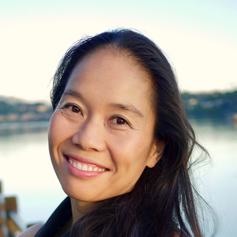

(c) 林赛·斯基巴

(c) Lynsay Skiba

邦妮·崔 (Bonnie Tsui) 生活、游泳和冲浪都在旧金山湾区。她长期为《*纽约时报》*和*《加州周日杂志》*撰稿，曾荣获哈佛大学简·雷尼·奥佩尔青年校友奖、洛厄尔·托马斯金奖和国家新闻基金会奖学金。她的上一本书《*美国唐人街：五个街区的人民史》*荣获亚太裔美国文学奖，并荣登《旧金山纪事报》畅销书榜，入选2009年旧金山湾区最佳图书。她的个人网站是[bonnietsui.com](http://bonnietsui.com/)。

Bonnie Tsui lives, swims, and surfs in the Bay Area. A longtime contributor to the *New York Times* and *California Sunday Magazine*, she has been the recipient of the Jane Rainie Opel Young Alumna Award from Harvard University, the Lowell Thomas Gold Award, and a National Press Foundation Fellowship. Her last book, *American Chinatown: A People’s History of Five Neighborhoods*, won the Asian/Pacific American Award for Literature and was a San Francisco Chronicle bestseller and Best of 2009 Notable Bay Area Books selection. Her website is bonnietsui.com.

由北卡罗来纳州教堂山邮政信箱2225号  
的阿尔冈昆出版社出版，邮编27515-2225

Published by  
Algonquin Books of Chapel Hill  
Post Office Box 2225  
Chapel Hill, North Carolina 27515-2225

Workman Publishing旗下部门，地址：纽约州纽约  
市瓦里克街225号，邮编：10014

a division of  
Workman Publishing  
225 Varick Street  
New York, New York 10014

© 2020 Bonnie Tsui 版权所有。保留所有权利。  
平装版首版由教堂山阿尔冈昆出版社于 2021 年 4 月出版。精装版原版由教堂山阿尔冈昆出版社于 2020 年 4 月出版。

© 2020 by Bonnie Tsui. All rights reserved.  
First paperback edition, Algonquin Books of Chapel Hill, April 2021. Originally published in hardcover by Algonquin Books of Chapel Hill in April 2020.

节选自卡尔·菲利普斯*诗集《狂野之风》中的诗作*  
《游泳》。版权所有 © 2018 卡尔·菲利普斯。经法勒、斯特劳斯和吉鲁出版社许可转载。

Excerpt from “Swimming” from *Wild Is the Wind: Poems* by Carl Phillips.  
Copyright © 2018 by Carl Phillips. Reprinted by permission of Farrar, Straus and Giroux.

《晨泳》版权所有 © 1965 玛克辛·库明，选自玛克辛·库明*诗选集，1960–1990*。经 WW Norton & Company, Inc. 许可使用。

“Morning Swim” copyright © 1965 by Maxine Kumin, from *Selected Poems, 1960–1990* by Maxine Kumin. Used by permission of W. W. Norton & Company, Inc.

摘自《游泳之歌》，经 Loudon Wainwright III 许可转载。

Excerpt from “The Swimming Song” reprinted by permission of Loudon Wainwright III.

美国国会图书馆出版物编目数据：国会图书馆记录可在以下网址获取：https://lccn.loc.gov/2019042645

Library of Congress Cataloging-in-Publication Data: LC record available at https://lccn.loc.gov/2019042645

电子书ISBN：978-1-64375-051-4

eISBN: 978-1-64375-051-4

*《我们为什么游泳》*好评如潮

Praise for *Why We Swim*

《洛杉矶时报》和《波士顿环球报》畅销书 • 《纽约时报》编辑之选/员工推荐 • 美国国家公共电台年度最佳图书 • 《时代》杂志年度必读图书 • 彭博社年度最佳非虚构类图书 • 《洛杉矶时报》读书俱乐部推荐 • 亚马逊编辑推荐最佳非虚构类图书 • Goodreads年度最佳科技图书奖入围作品

A Los Angeles Times and Boston Globe bestseller • A New York Times Editors’ Choice / Staff Pick • An NPR Best Book of the Year • A Time Magazine Must-Read Book of the Year • A Bloomberg Best Nonfiction Book of the Year • A Los Angeles Times Book Club Pick • An Amazon Editors’ Pick for Best Nonfiction • A Goodreads Choice Awards Finalist for Best Science & Technology Book of the Year

“这是一部热情洋溢、发人深省的作品，融合了历史、新闻报道和回忆录的元素……徐女士也赢得了读者的喜爱。她提出的普世问题也是对自身的追问，她对所见所闻的阐述令人动容。”—— 《纽约时报书评》

“[An] enthusiastic and thoughtful work mixing history, journalism and elements of memoir . . . Tsui endears herself to the reader as well. Her universal query is also one of self, and her articulations of what she learns are moving.” —The New York Times Book Review

“邦妮·崔捕捉到了游泳的乐趣、危险和实用性，无论是在她的家庭中还是在不同文明中……她报道的广度和文笔的优美，使得《 我们为何游泳》一书的各个元素和谐统一。”—— 《旧金山纪事报》

“Bonnie Tsui captures the joy, peril and utility of swimming, within her family and across civilizations . . . The breadth of her reporting and grace of her writing make the elements of Why We Swim move harmoniously as one.” —San Francisco Chronicle

“崔女士带领读者穿越时空，环游世界，讲述了数千年来人类与水相处、适应水环境以及与之互动的种种方式。她的书也是对游泳对身心灵魂的变革性影响的一次深刻思考。”—— 《洛杉矶时报》

“Tsui takes readers on a trip through time and around the world, recounting the myriad ways humans have endured, adapted to, and interacted with water over thousands of years. Her book also is a meditation on swimming’s transformative effect on body, mind, and soul.” —Los Angeles Times

“Bonnie Tsui提醒我们，人类曾经源于水，如今依然渴求水源……这是一个令人惊叹的故事。”——斯科特·西蒙，《NPR周末版》

“Bonnie Tsui reminds us that humankind once sprang from and still seeks water . . . An amazing story.” —Scott Simon, NPR’s Weekend Edition

“《我们为何游泳》是一本精彩绝伦的混合体式书籍。你绝对不会后悔沉浸其中。”——卡尔·齐默，《纽约时报》科学专栏作家，《她继承了母亲的笑声：遗传的力量、变异与潜力》的作者

“Why We Swim is a gorgeous hybrid of a book. You won’t regret diving in.” —Carl Zimmer, New York Times science columnist and author of She Has Her Mother’s Laugh: The Powers, Perversions, and Potential of Heredity

“这是一部报道深入、引人入胜的作品，从最早的游泳记录（发现于沙漠中央）到消失的水生社会、海上游牧民族等等，精彩纷呈。这本书仿佛是为邦妮·崔量身打造的。”——丽贝卡·斯克鲁特，《 亨丽埃塔·拉克斯的永生》畅销书作者

“A deeply reported and fascinating story that takes us from the first record of swimming (which lies in the middle of a desert) to tales of vanishing aquatic societies, sea nomads, and so much more. This is a book Bonnie Tsui was born to write.” —Rebecca Skloot, bestselling author of The Immortal Life of Henrietta Lacks

“在《我们为何游泳》一书中，毕生热爱游泳且文笔出众的邦妮·崔探讨了人类与水的关系，以及我们为何会被水的深处所吸引。”—— 《奥普拉杂志》

“In Why We Swim, Bonnie Tsui—a lifelong swimmer who happens to be an excellent writer—investigates humankind’s relationship to water, and why we are drawn to its depths.” —O, The Oprah Magazine

“前竞技游泳运动员、现任全能作家邦妮·崔的《我们为何游泳》……探讨了我们与这项运动的关系，这项运动本身就代表着平静与流畅（我们多么需要这种感觉，不是吗？），书中列举了一系列形形色色的例子，例如游泳武士和冰岛沉船幸存者。”——《户外》杂志

“Former competitive swimmer and current do-it-all writer Bonnie Tsui’s Why We Swim . . . explores our relationship with a sport that quite literally represents quiet and flow (something we could use more of, no?) by offering a look at a grab bag of eclectic examples, like swimming samurais and an Icelandic shipwreck survivor.” —Outside

“崔的这部关于人类与水关系的著作引人入胜、发人深省，其行文流畅自然，仿佛水流本身也在流动……我从头到尾都被它深深吸引。”—— BuzzFeed

“Tsui’s history of the human relationship with water is compelling and profound, in writing so fluid it mimics the flow of her subject . . . It captivated me from start to finish.” —BuzzFeed

“文笔优美，描写生动……崔的这本佳作不仅吸引体育迷，更能吸引更广泛的读者。对科学和自然感兴趣的读者也会喜欢这本关于疗愈运动的叙事作品，强烈推荐。”—— 《图书馆杂志》

“Lyrical and descriptive . . . Tsui’s beautifully written book will appeal to a wider audience beyond sports fans. Readers who are also interested in science and nature will appreciate this highly recommended narrative work about a therapeutic sport.” —Library Journal

“科学与回忆录的诗意融合。”—— 《发现》杂志

“A poetic blend of science and memoir.” —Discover